# r_script2.R

ecrawford

2021-08-30

```r
library(foreign)
library(dplyr)
```

```r
library(psych)
library(broom)
library(jtools)
library(margins)
library(ggplot2)
library("readxl")
library(sm)
library(pastecs)
library("ggpubr")
library("gplots")
library(rstatix)
library(stargazer)
library(devtools)
library(sjmisc)
library(sjPlot)
library(table1)
library(boot)
library(expss)
library(summarytools)
library(tidyr)
# Read-in CCES module data (2018 and 2020 already pooled and stripped of identifying information)
cces <- read.csv("cces.csv")

###########################################################################
###########################################################################
###########################################################################

# State Contextual Data #

context <- read.csv("CCES_contextual_states.csv")
cces1 <- merge(cces, context, by=c("inputstate"), all=TRUE)
rm(context)

# MERGE IN CONGRESSIONAL DISTRICT DATA ##

cd <- read.csv("cdid116_v2.csv", header = TRUE)
cd <- subset(cd, select=c(state2, cdid116, biden2020, trump2020))

cd$cdid116 <- as.numeric(cd$cdid116)
cces1$cdid116 <- as.numeric(cces1$cdid116)

cces1 <- merge(cces1, cd, by=c("state2", "cdid116"), all=TRUE)

# remove original CCES for housekeeping
rm(cces)
# "cces1 is new baseline for data

# merge presidential vote data

load("~/Dropbox/Research/Proposals/MPSA 2019/countypres_2000-2016.RData")
#detach plyr to allow group_by functions to work
require(plyr) # package
detach(package:plyr)

presvote <- x
rm(x)
presvote <- subset(presvote, year==2016)
presvote <- subset(presvote, party!="NA")

presvote2party <- presvote %>%
  group_by(FIPS, year) %>%
  summarise(Frequency = sum(candidatevotes, na.rm=TRUE))
colnames(presvote2party) <- c("FIPS","year","presvotes_2party")

presvote <- merge(presvote, presvote2party, by = c("FIPS", "year"))
rm(presvote2party)

presvote$voteshare2party <- (presvote$candidatevotes/presvote$presvotes_2party)*100

presvote$d_voteshare2party = ifelse(presvote$party == "democrat", presvote$voteshare2party, NA)
presvote$r_voteshare2party = ifelse(presvote$party == "republican", presvote$voteshare2party, NA)
presvote_d <- subset(presvote, d_voteshare2party!="NA")
presvote_r <- subset(presvote, r_voteshare2party!="NA")

presvote_d <- presvote_d[c(-15)]
presvote_r <- presvote_r[c(-14)]

## Just 2016 vote share by county - democrats ##
avg_dvote <- presvote_d %>%
  group_by(FIPS) %>%
  summarise(Frequency = sum(d_voteshare2party))
colnames(avg_dvote) <- c("FIPS","avg_d_voteshare2party")

avg_presvote_d <- merge(presvote_d, avg_dvote, by = c("FIPS"))

avg_presvote_d <- subset(avg_presvote_d, select=c(FIPS, state, state_po, county, avg_d_voteshare2party))

rm(avg_dvote)
rm(presvote_d)

## just 2016 - republicans ##
avg_rvote <- presvote_r %>%
  group_by(FIPS) %>%
  summarise(Frequency = sum(r_voteshare2party))
colnames(avg_rvote) <- c("FIPS","avg_r_voteshare2party")

avg_presvote_r <- merge(presvote_r, avg_rvote, by = c("FIPS"))

avg_presvote_r <- subset(avg_presvote_r, select=c(FIPS, state, state_po, county, avg_r_voteshare2party))

rm(avg_rvote)
rm(presvote_r)

##

avg_dvote <- subset(avg_presvote_d, select=c(FIPS, state, state_po, county, avg_d_voteshare2party))
avg_rvote <- subset(avg_presvote_r, select=c(FIPS, avg_r_voteshare2party))

presvote <- presvote[c(-14, -15)]
presvote <- merge(avg_dvote, avg_rvote, by = c("FIPS"))

rm(avg_dvote)
rm(avg_rvote)
rm(avg_presvote_d)
rm(avg_presvote_r)

# add leading zero to FIPS in presvote data
library(stringr)
presvote$FIPS <- str_pad(presvote$FIPS, 5, pad = "0")
presvote$FIPS <- as.integer((presvote$FIPS))
typeof(presvote$FIPS)
```

```
## [1] "integer"
```

```r
cces1$FIPS <- cces1$countyfips

## New Dataset - 'cces2' (before merging, keep cces1 as is)
## But first - ensure that everything gets merged, even if has some missing data

library(tidyr)

cces2 <- merge(cces1, presvote, by="FIPS", all = FALSE)
cces2 <- cces2 %>% drop_na(state2)

rm(presvote)

# Create County Partisanship Indicator #

cces2$Pres_Vote <- ifelse(cces2$avg_r_voteshare2party >=65, "Solid Republican",
                          ifelse(cces2$avg_r_voteshare2party >=50 & cces2$avg_r_voteshare2party < 65, "Lean Republican",
                                 ifelse(cces2$avg_r_voteshare2party <50 & cces2$avg_r_voteshare2party >=35, "Lean Democrat",
                                        ifelse(cces2$avg_r_voteshare2party <35, "Solid Democrat", NA))))

###################################
## Exclude True Independents ##
cces2.2 <- subset(cces2, pid!="Independent")

## Drop Independent Factor Level
cces2.2$pid <- droplevels(cces2.2$pid)

table(cces2.2$pid)
```

```
##
##   Democrat Republican
##        945        712
```

```r
## Subsets specifically for Margins and Plotting (custom labelling)

# School Board Margins Plots #

sbMargins <- cces2.2

sbMarginsNP <- c("RCO322_np", "avg_d_voteshare2party", "pid",
                 "perceive_extreme_very", "polint", "educ.int",
                 "birthyr", "Pres_Vote", "biden2020", "trump2020")

sbMarginsNP2 <- sbMargins[sbMarginsNP]

#Ensure factors for glm

sbMarginsNP2$pid.f <- as.factor(sbMarginsNP2$pid)
sbMarginsNP2$pid.f <- relevel(sbMarginsNP2$pid.f, ref = "Republican")
#
sbMarginsNP2$polint.f <- as.factor(sbMarginsNP2$polint)
#
sbMarginsNP2$perceive_extreme_very.f <- as.factor(sbMarginsNP2$perceive_extreme_very)
#
sbMarginsNP2$educ.int.f <- as.factor(sbMarginsNP2$educ.int)
#
sbMarginsNP2$Pres_Vote.f <- as.factor(sbMarginsNP2$Pres_Vote)
sbMarginsNP2$Pres_Vote.f <- factor(sbMarginsNP2$Pres_Vote.f, levels = c("Solid Democrat",
                                                                        "Lean Democrat",
                                                                        "Lean Republican",
                                                                        "Solid Republican"))

sbMarginsNP2$Pres_Vote.f <- relevel(sbMarginsNP2$Pres_Vote.f, ref = "Solid Democrat")

# LEO Margins Plots #

leoMargins <- cces2.2

leoMarginsNP <- c("RCO321_np", "avg_d_voteshare2party", "pid",
                  "perceive_extreme_very", "polint", "educ.int",
                  "birthyr", "Pres_Vote", "biden2020", "trump2020")

leoMarginsNP2 <- leoMargins[leoMarginsNP]

#Ensure factors for glm

leoMarginsNP2$pid.f <- as.factor(leoMarginsNP2$pid)
leoMarginsNP2$pid.f <- relevel(leoMarginsNP2$pid.f, ref = "Republican")
#
leoMarginsNP2$polint.f <- as.factor(leoMarginsNP2$polint)
#
leoMarginsNP2$perceive_extreme_very.f <- as.factor(leoMarginsNP2$perceive_extreme_very)
#
leoMarginsNP2$educ.int.f <- as.factor(leoMarginsNP2$educ.int)
#
leoMarginsNP2$Pres_Vote.f <- as.factor(leoMarginsNP2$Pres_Vote)
leoMarginsNP2$Pres_Vote.f <- factor(leoMarginsNP2$Pres_Vote.f, levels = c("Solid Democrat",
                                                                          "Lean Democrat",
                                                                          "Lean Republican",
                                                                          "Solid Republican"))

leoMarginsNP2$Pres_Vote.f <- relevel(leoMarginsNP2$Pres_Vote.f, ref = "Solid Democrat")

#######

# Sheriff Margins Plots #

sherMargins <- cces2.2

sherMarginsNP <- c("RCO323_np", "avg_d_voteshare2party", "pid",
                   "perceive_extreme_very", "polint", "educ.int",
                   "birthyr", "Pres_Vote", "biden2020", "trump2020")

sherMarginsNP2 <- sherMargins[sherMarginsNP]

#Ensure factors for glm

sherMarginsNP2$pid.f <- as.factor(sherMarginsNP2$pid)
sherMarginsNP2$pid.f <- relevel(sherMarginsNP2$pid.f, ref = "Republican")
#
sherMarginsNP2$polint.f <- as.factor(sherMarginsNP2$polint)
#
sherMarginsNP2$perceive_extreme_very.f <- as.factor(sherMarginsNP2$perceive_extreme_very)
#
sherMarginsNP2$educ.int.f <- as.factor(sherMarginsNP2$educ.int)
#
sherMarginsNP2$Pres_Vote.f <- as.factor(sherMarginsNP2$Pres_Vote)
sherMarginsNP2$Pres_Vote.f <- factor(sherMarginsNP2$Pres_Vote.f, levels = c("Solid Democrat",
                                                                            "Lean Democrat",
                                                                            "Lean Republican",
                                                                            "Solid Republican"))

sherMarginsNP2$Pres_Vote.f <- relevel(sherMarginsNP2$Pres_Vote.f, ref = "Solid Democrat")


#######

# DA Margins Plots #

daMargins <- cces2.2

daMarginsNP <- c("RCO324_np", "avg_d_voteshare2party", "pid",
                 "perceive_extreme_very", "polint", "educ.int",
                 "birthyr", "Pres_Vote", "biden2020", "trump2020")

daMarginsNP2 <- daMargins[daMarginsNP]

#Ensure factors for glm

daMarginsNP2$pid.f <- as.factor(daMarginsNP2$pid)
daMarginsNP2$pid.f <- relevel(daMarginsNP2$pid.f, ref = "Republican")
#
daMarginsNP2$polint.f <- as.factor(daMarginsNP2$polint)
#
daMarginsNP2$perceive_extreme_very.f <- as.factor(daMarginsNP2$perceive_extreme_very)
#
daMarginsNP2$educ.int.f <- as.factor(daMarginsNP2$educ.int)
#
daMarginsNP2$Pres_Vote.f <- as.factor(daMarginsNP2$Pres_Vote)
daMarginsNP2$Pres_Vote.f <- factor(daMarginsNP2$Pres_Vote.f, levels = c("Solid Democrat",
                                                                        "Lean Democrat",
                                                                        "Lean Republican",
                                                                        "Solid Republican"))

daMarginsNP2$Pres_Vote.f <- relevel(daMarginsNP2$Pres_Vote.f, ref = "Solid Democrat")

#######

# House Margins Plots #

houseMargins <- cces2.2

houseMarginsNP <- c("RCO327_np", "avg_d_voteshare2party", "pid",
                    "perceive_extreme_very", "polint", "educ.int",
                    "birthyr", "Pres_Vote", "biden2020", "trump2020")

houseMarginsNP2 <- daMargins[houseMarginsNP]

#Ensure factors for glm

houseMarginsNP2$pid.f <- as.factor(houseMarginsNP2$pid)
houseMarginsNP2$pid.f <- relevel(houseMarginsNP2$pid.f, ref = "Republican")
#
houseMarginsNP2$polint.f <- as.factor(houseMarginsNP2$polint)
#
houseMarginsNP2$perceive_extreme_very.f <- as.factor(houseMarginsNP2$perceive_extreme_very)
#
houseMarginsNP2$educ.int.f <- as.factor(houseMarginsNP2$educ.int)
#
houseMarginsNP2$Pres_Vote.f <- as.factor(houseMarginsNP2$Pres_Vote)
houseMarginsNP2$Pres_Vote.f <- factor(houseMarginsNP2$Pres_Vote.f, levels = c("Solid Democrat",
                                                                              "Lean Democrat",
                                                                              "Lean Republican",
                                                                              "Solid Republican"))

houseMarginsNP2$Pres_Vote.f <- relevel(houseMarginsNP2$Pres_Vote.f, ref = "Solid Democrat")
```

```r
#####################################################################

## Subsets specifically for Regression Outputs ##
library(stargazer)
library(sjPlot)
library(sjmisc)
library(sjlabelled)
library(glmmTMB)
library(Hmisc)
library(glmmTMB)

###################################################

## School Board ##

sbGLM <- cces2.2

sbGLM$pid.f <- as.factor(sbGLM$pid)
sbGLM$polint.f <- as.factor(sbGLM$polint)
sbGLM$perceive_extreme_very.f <- as.factor(sbGLM$perceive_extreme_very)
sbGLM$educ.int.f <- as.factor(sbGLM$educ.int)
sbGLM$Pres_Vote.f <- as.factor(sbGLM$Pres_Vote)

## Change Labels ##

sbGLM$polint.f <-
  factor(sbGLM$polint.f, levels=c("1","2","3","4"),
         labels=c("News: Hardly at all",
                  "News: Now and then",
                  "News: Some of the time",
                  "News: Most of the time"))

sbGLM$perceive_extreme_very.f <-
  factor(sbGLM$perceive_extreme_very.f, levels=c("0","1"),
         labels=c("Not extreme",
                  "Outparty is extreme"))

sbGLM$educ.int.f <-
  factor(sbGLM$educ.int, levels=c("1","2","3","4","5"),
         labels=c("H.S. or less",
                  "Some College",
                  "2-Year Degree",
                  "4-Year Degree",
                  "Post-Graduate"))

sbGLM$Pres_Vote.f <-
  factor(sbGLM$Pres_Vote.f,
         levels = c("Solid Democrat",
                    "Lean Democrat",
                    "Lean Republican",
                    "Solid Republican"),
         labels=c("Solid Democrat",
                  "Lean Democrat",
                  "Lean Republican",
                  "Solid Republican"))


label(sbGLM$pid.f) <- "Party"
label(sbGLM$RCO322_np) <- "Preference for Nonpartisan School Board"
label(sbGLM$Pres_Vote.f) <- "County 2016 Pres. Vote"
label(sbGLM$educ.int.f) <- "Education"
label(sbGLM$perceive_extreme_very.f) <- "Outparty Extremity"
label(sbGLM$polint.f) <- "News Interest"


###################################################

## LEO ##

leoGLM <- cces2.2

leoGLM$pid.f <- as.factor(leoGLM$pid)
leoGLM$polint.f <- as.factor(leoGLM$polint)
leoGLM$perceive_extreme_very.f <- as.factor(leoGLM$perceive_extreme_very)
leoGLM$educ.int.f <- as.factor(leoGLM$educ.int)
leoGLM$Pres_Vote.f <- as.factor(leoGLM$Pres_Vote)

## Change Labels ##

leoGLM$polint.f <-
  factor(leoGLM$polint.f, levels=c("1","2","3","4"),
         labels=c("News: Hardly at all",
                  "News: Now and then",
                  "News: Some of the time",
                  "News: Most of the time"))

leoGLM$perceive_extreme_very.f <-
  factor(leoGLM$perceive_extreme_very.f, levels=c("0","1"),
         labels=c("Not extreme",
                  "Outparty is extreme"))

leoGLM$educ.int.f <-
  factor(leoGLM$educ.int, levels=c("1","2","3","4","5"),
         labels=c("H.S. or less",
                  "Some College",
                  "2-Year Degree",
                  "4-Year Degree",
                  "Post-Graduate"))

leoGLM$Pres_Vote.f <-
  factor(leoGLM$Pres_Vote.f,
         levels = c("Solid Democrat",
                    "Lean Democrat",
                    "Lean Republican",
                    "Solid Republican"),
         labels=c("Solid Democrat",
                  "Lean Democrat",
                  "Lean Republican",
                  "Solid Republican"))


label(leoGLM$pid.f) <- "Party"
label(leoGLM$RCO321_np) <- "Preference for Nonpartisan Local Election Official"
label(leoGLM$Pres_Vote.f) <- "County 2016 Pres. Vote"
label(leoGLM$educ.int.f) <- "Education"
label(leoGLM$perceive_extreme_very.f) <- "Outparty Extremity"
label(leoGLM$polint.f) <- "News Interest"



###################################################

## Sheriff ##

sherGLM <- cces2.2

sherGLM$pid.f <- as.factor(sherGLM$pid)
sherGLM$polint.f <- as.factor(sherGLM$polint)
sherGLM$perceive_extreme_very.f <- as.factor(sherGLM$perceive_extreme_very)
sherGLM$educ.int.f <- as.factor(sherGLM$educ.int)
sherGLM$Pres_Vote.f <- as.factor(sherGLM$Pres_Vote)

## Change Labels ##

sherGLM$polint.f <-
  factor(sherGLM$polint.f, levels=c("1","2","3","4"),
         labels=c("News: Hardly at all",
                  "News: Now and then",
                  "News: Some of the time",
                  "News: Most of the time"))

sherGLM$perceive_extreme_very.f <-
  factor(sherGLM$perceive_extreme_very.f, levels=c("0","1"),
         labels=c("Not extreme",
                  "Outparty is extreme"))

sherGLM$educ.int.f <-
  factor(sherGLM$educ.int, levels=c("1","2","3","4","5"),
         labels=c("H.S. or less",
                  "Some College",
                  "2-Year Degree",
                  "4-Year Degree",
                  "Post-Graduate"))

sherGLM$Pres_Vote.f <-
  factor(sherGLM$Pres_Vote.f,
         levels = c("Solid Democrat",
                    "Lean Democrat",
                    "Lean Republican",
                    "Solid Republican"),
         labels=c("Solid Democrat",
                  "Lean Democrat",
                  "Lean Republican",
                  "Solid Republican"))


label(sherGLM$pid.f) <- "Party"
label(sherGLM$RCO323_np) <- "Preference for Nonpartisan Sheriff"
label(sherGLM$Pres_Vote.f) <- "County 2016 Pres. Vote"
label(sherGLM$educ.int.f) <- "Education"
label(sherGLM$perceive_extreme_very.f) <- "Outparty Extremity"
label(sherGLM$polint.f) <- "News Interest"


###################################################

## DA ##

daGLM <- cces2.2

daGLM$pid.f <- as.factor(daGLM$pid)
daGLM$polint.f <- as.factor(daGLM$polint)
daGLM$perceive_extreme_very.f <- as.factor(daGLM$perceive_extreme_very)
daGLM$educ.int.f <- as.factor(daGLM$educ.int)
daGLM$Pres_Vote.f <- as.factor(daGLM$Pres_Vote)

## Change Labels ##

daGLM$polint.f <-
  factor(daGLM$polint.f, levels=c("1","2","3","4"),
         labels=c("News: Hardly at all",
                  "News: Now and then",
                  "News: Some of the time",
                  "News: Most of the time"))

daGLM$perceive_extreme_very.f <-
  factor(daGLM$perceive_extreme_very.f, levels=c("0","1"),
         labels=c("Not extreme",
                  "Outparty is extreme"))
```

```r
daGLM$educ.int.f <-
  factor(daGLM$educ.int, levels=c("1","2","3","4","5"),
         labels=c("H.S. or less",
                  "Some College",
                  "2-Year Degree",
                  "4-Year Degree",
                  "Post-Graduate"))

daGLM$Pres_Vote.f <-
  factor(daGLM$Pres_Vote.f,
         levels = c("Solid Democrat",
                    "Lean Democrat",
                    "Lean Republican",
                    "Solid Republican"),
         labels=c("Solid Democrat",
                  "Lean Democrat",
                  "Lean Republican",
                  "Solid Republican"))


label(daGLM$pid.f) <- "Party"
label(daGLM$RCO324_np) <- "Preference for Nonpartisan District Attorney"
label(daGLM$Pres_Vote.f) <- "County 2016 Pres. Vote"
label(daGLM$educ.int.f) <- "Education"
label(daGLM$perceive_extreme_very.f) <- "Outparty Extremity"
label(daGLM$polint.f) <- "News Interest"


###################################################

## U.S. House ##

houseGLM <- cces2.2

houseGLM$pid.f <- as.factor(houseGLM$pid)
houseGLM$polint.f <- as.factor(houseGLM$polint)
houseGLM$perceive_extreme_very.f <- as.factor(houseGLM$perceive_extreme_very)
houseGLM$educ.int.f <- as.factor(houseGLM$educ.int)
houseGLM$Pres_Vote.f <- as.factor(houseGLM$Pres_Vote)

## Change Labels ##

houseGLM$polint.f <-
  factor(houseGLM$polint.f, levels=c("1","2","3","4"),
         labels=c("News: Hardly at all",
                  "News: Now and then",
                  "News: Some of the time",
                  "News: Most of the time"))

houseGLM$perceive_extreme_very.f <-
  factor(houseGLM$perceive_extreme_very.f, levels=c("0","1"),
         labels=c("Not extreme",
                  "Outparty is extreme"))

houseGLM$educ.int.f <-
  factor(houseGLM$educ.int, levels=c("1","2","3","4","5"),
         labels=c("H.S. or less",
                  "Some College",
                  "2-Year Degree",
                  "4-Year Degree",
                  "Post-Graduate"))

houseGLM$Pres_Vote.f <-
  factor(houseGLM$Pres_Vote.f,
         levels = c("Solid Democrat",
                    "Lean Democrat",
                    "Lean Republican",
                    "Solid Republican"),
         labels=c("Solid Democrat",
                  "Lean Democrat",
                  "Lean Republican",
                  "Solid Republican"))


label(houseGLM$pid.f) <- "Party"
label(houseGLM$RCO327_np) <- "Preference for Nonpartisan U.S. House"
label(houseGLM$Pres_Vote.f) <- "County 2016 Pres. Vote"
label(houseGLM$educ.int.f) <- "Education"
label(houseGLM$perceive_extreme_very.f) <- "Outparty Extremity"
label(houseGLM$polint.f) <- "News Interest"

###################################

## PARTISAN AS THE DV ##

## Subsets specifically for Margins and Plotting (custom labelling)

# School Board Margins Plots #

sbMargins <- cces2.2

sbMarginsP <- c("RCO322_p", "avg_d_voteshare2party", "pid",
                "perceive_extreme_very", "polint", "educ.int",
                "birthyr", "Pres_Vote", "biden2020", "trump2020")

sbMarginsP2 <- sbMargins[sbMarginsP]

#Ensure factors for glm

sbMarginsP2$pid.f <- as.factor(sbMarginsP2$pid)
sbMarginsP2$pid.f <- relevel(sbMarginsP2$pid.f, ref = "Republican")
#
sbMarginsP2$polint.f <- as.factor(sbMarginsP2$polint)
#
sbMarginsP2$perceive_extreme_very.f <- as.factor(sbMarginsP2$perceive_extreme_very)
#
sbMarginsP2$educ.int.f <- as.factor(sbMarginsP2$educ.int)
#
sbMarginsP2$Pres_Vote.f <- as.factor(sbMarginsP2$Pres_Vote)
sbMarginsP2$Pres_Vote.f <- factor(sbMarginsP2$Pres_Vote.f, levels = c("Solid Democrat",
                                                                      "Lean Democrat",
                                                                      "Lean Republican",
                                                                      "Solid Republican"))

sbMarginsP2$Pres_Vote.f <- relevel(sbMarginsP2$Pres_Vote.f, ref = "Solid Democrat")

# LEO Margins Plots #

leoMargins <- cces2.2

leoMarginsP <- c("RCO321_p", "avg_d_voteshare2party", "pid",
                 "perceive_extreme_very", "polint", "educ.int",
                 "birthyr", "Pres_Vote", "biden2020", "trump2020")

leoMarginsP2 <- leoMargins[leoMarginsP]

#Ensure factors for glm

leoMarginsP2$pid.f <- as.factor(leoMarginsP2$pid)
leoMarginsP2$pid.f <- relevel(leoMarginsP2$pid.f, ref = "Republican")
#
leoMarginsP2$polint.f <- as.factor(leoMarginsP2$polint)
#
leoMarginsP2$perceive_extreme_very.f <- as.factor(leoMarginsP2$perceive_extreme_very)
#
leoMarginsP2$educ.int.f <- as.factor(leoMarginsP2$educ.int)
#
leoMarginsP2$Pres_Vote.f <- as.factor(leoMarginsP2$Pres_Vote)
leoMarginsP2$Pres_Vote.f <- factor(leoMarginsP2$Pres_Vote.f, levels = c("Solid Democrat",
                                                                        "Lean Democrat",
                                                                        "Lean Republican",
                                                                        "Solid Republican"))

leoMarginsP2$Pres_Vote.f <- relevel(leoMarginsP2$Pres_Vote.f, ref = "Solid Democrat")

#######

# Sheriff Margins Plots #

sherMargins <- cces2.2

sherMarginsP <- c("RCO323_p", "avg_d_voteshare2party", "pid",
                  "perceive_extreme_very", "polint", "educ.int",
                  "birthyr", "Pres_Vote", "biden2020", "trump2020")

sherMarginsP2 <- sherMargins[sherMarginsP]

#Ensure factors for glm

sherMarginsP2$pid.f <- as.factor(sherMarginsP2$pid)
sherMarginsP2$pid.f <- relevel(sherMarginsP2$pid.f, ref = "Republican")
#
sherMarginsP2$polint.f <- as.factor(sherMarginsP2$polint)
#
sherMarginsP2$perceive_extreme_very.f <- as.factor(sherMarginsP2$perceive_extreme_very)
#
sherMarginsP2$educ.int.f <- as.factor(sherMarginsP2$educ.int)
#
sherMarginsP2$Pres_Vote.f <- as.factor(sherMarginsP2$Pres_Vote)
sherMarginsP2$Pres_Vote.f <- factor(sherMarginsP2$Pres_Vote.f, levels = c("Solid Democrat",
                                                                          "Lean Democrat",
                                                                          "Lean Republican",
                                                                          "Solid Republican"))
```

```r
sherMarginsP2$Pres_Vote.f <- relevel(sherMarginsP2$Pres_Vote.f, ref = "Solid Democrat")


#######

# DA Margins Plots #

daMargins <- cces2.2

daMarginsP <- c("RCO324_p", "avg_d_voteshare2party", "pid",
                "perceive_extreme_very", "polint", "educ.int",
                "birthyr", "Pres_Vote", "biden2020", "trump2020")

daMarginsP2 <- daMargins[daMarginsP]

#Ensure factors for glm

daMarginsP2$pid.f <- as.factor(daMarginsP2$pid)
daMarginsP2$pid.f <- relevel(daMarginsP2$pid.f, ref = "Republican")
#
daMarginsP2$polint.f <- as.factor(daMarginsP2$polint)
#
daMarginsP2$perceive_extreme_very.f <- as.factor(daMarginsP2$perceive_extreme_very)
#
daMarginsP2$educ.int.f <- as.factor(daMarginsP2$educ.int)
#
daMarginsP2$Pres_Vote.f <- as.factor(daMarginsP2$Pres_Vote)
daMarginsP2$Pres_Vote.f <- factor(daMarginsP2$Pres_Vote.f, levels = c("Solid Democrat",
                                                                      "Lean Democrat",
                                                                      "Lean Republican",
                                                                      "Solid Republican"))

daMarginsP2$Pres_Vote.f <- relevel(daMarginsP2$Pres_Vote.f, ref = "Solid Democrat")

#######

# House Margins Plots #

houseMargins <- cces2.2

houseMarginsP <- c("RCO327_p", "avg_d_voteshare2party", "pid",
                   "perceive_extreme_very", "polint", "educ.int",
                   "birthyr", "Pres_Vote", "biden2020", "trump2020")

houseMarginsP2 <- daMargins[houseMarginsP]

#Ensure factors for glm

houseMarginsP2$pid.f <- as.factor(houseMarginsP2$pid)
houseMarginsP2$pid.f <- relevel(houseMarginsP2$pid.f, ref = "Republican")
#
houseMarginsP2$polint.f <- as.factor(houseMarginsP2$polint)
#
houseMarginsP2$perceive_extreme_very.f <- as.factor(houseMarginsP2$perceive_extreme_very)
#
houseMarginsP2$educ.int.f <- as.factor(houseMarginsP2$educ.int)
#
houseMarginsP2$Pres_Vote.f <- as.factor(houseMarginsP2$Pres_Vote)
houseMarginsP2$Pres_Vote.f <- factor(houseMarginsP2$Pres_Vote.f, levels = c("Solid Democrat",
                                                                            "Lean Democrat",
                                                                            "Lean Republican",
                                                                            "Solid Republican"))

houseMarginsP2$Pres_Vote.f <- relevel(houseMarginsP2$Pres_Vote.f, ref = "Solid Democrat")

#####################################################################

## Subsets specifically for Regression Outputs ##
library(stargazer)
library(sjPlot)
library(sjmisc)
library(sjlabelled)
library(glmmTMB)
library(Hmisc)
library(glmmTMB)

###################################################

## School Board ##

sbGLMp <- cces2.2

sbGLMp$pid.f <- as.factor(sbGLMp$pid)
sbGLMp$polint.f <- as.factor(sbGLMp$polint)
sbGLMp$perceive_extreme_very.f <- as.factor(sbGLMp$perceive_extreme_very)
sbGLMp$educ.int.f <- as.factor(sbGLMp$educ.int)
sbGLMp$Pres_Vote.f <- as.factor(sbGLMp$Pres_Vote)

## Change Labels ##

sbGLMp$polint.f <-
  factor(sbGLMp$polint.f, levels=c("1","2","3","4"),
         labels=c("News: Hardly at all",
                  "News: Now and then",
                  "News: Some of the time",
                  "News: Most of the time"))

sbGLMp$perceive_extreme_very.f <-
  factor(sbGLMp$perceive_extreme_very.f, levels=c("0","1"),
         labels=c("Not extreme",
                  "Outparty is extreme"))

sbGLMp$educ.int.f <-
  factor(sbGLMp$educ.int, levels=c("1","2","3","4","5"),
         labels=c("H.S. or less",
                  "Some College",
                  "2-Year Degree",
                  "4-Year Degree",
                  "Post-Graduate"))

sbGLMp$Pres_Vote.f <-
  factor(sbGLMp$Pres_Vote.f,
         levels = c("Solid Democrat",
                    "Lean Democrat",
                    "Lean Republican",
                    "Solid Republican"),
         labels=c("Solid Democrat",
                  "Lean Democrat",
                  "Lean Republican",
                  "Solid Republican"))


label(sbGLMp$pid.f) <- "Party"
label(sbGLMp$RCO322_p) <- "Preference for Partisan School Board"
label(sbGLMp$Pres_Vote.f) <- "County 2016 Pres. Vote"
label(sbGLMp$educ.int.f) <- "Education"
label(sbGLMp$perceive_extreme_very.f) <- "Outparty Extremity"
label(sbGLMp$polint.f) <- "News Interest"


###################################################

## LEO ##

leoGLMp <- cces2.2

leoGLMp$pid.f <- as.factor(leoGLMp$pid)
leoGLMp$polint.f <- as.factor(leoGLMp$polint)
leoGLMp$perceive_extreme_very.f <- as.factor(leoGLMp$perceive_extreme_very)
leoGLMp$educ.int.f <- as.factor(leoGLMp$educ.int)
leoGLMp$Pres_Vote.f <- as.factor(leoGLMp$Pres_Vote)

## Change Labels ##

leoGLMp$polint.f <-
  factor(leoGLMp$polint.f, levels=c("1","2","3","4"),
         labels=c("News: Hardly at all",
                  "News: Now and then",
                  "News: Some of the time",
                  "News: Most of the time"))

leoGLMp$perceive_extreme_very.f <-
  factor(leoGLMp$perceive_extreme_very.f, levels=c("0","1"),
         labels=c("Not extreme",
                  "Outparty is extreme"))

leoGLMp$educ.int.f <-
  factor(leoGLMp$educ.int, levels=c("1","2","3","4","5"),
         labels=c("H.S. or less",
                  "Some College",
                  "2-Year Degree",
                  "4-Year Degree",
                  "Post-Graduate"))

leoGLMp$Pres_Vote.f <-
  factor(leoGLMp$Pres_Vote.f,
         levels = c("Solid Democrat",
                    "Lean Democrat",
                    "Lean Republican",
                    "Solid Republican"),
         labels=c("Solid Democrat",
                  "Lean Democrat",
                  "Lean Republican",
                  "Solid Republican"))


label(leoGLMp$pid.f) <- "Party"
label(leoGLMp$RCO321_p) <- "Preference for Partisan Local Election Official"
label(leoGLMp$Pres_Vote.f) <- "County 2016 Pres. Vote"
label(leoGLMp$educ.int.f) <- "Education"
label(leoGLMp$perceive_extreme_very.f) <- "Outparty Extremity"
label(leoGLMp$polint.f) <- "News Interest"
```

```r
###################################################

## Sheriff ##

sherGLMp <- cces2.2

sherGLMp$pid.f <- as.factor(sherGLMp$pid)
sherGLMp$polint.f <- as.factor(sherGLMp$polint)
sherGLMp$perceive_extreme_very.f <- as.factor(sherGLMp$perceive_extreme_very)
sherGLMp$educ.int.f <- as.factor(sherGLMp$educ.int)
sherGLMp$Pres_Vote.f <- as.factor(sherGLMp$Pres_Vote)

## Change Labels ##

sherGLMp$polint.f <-
  factor(sherGLMp$polint.f, levels=c("1","2","3","4"),
         labels=c("News: Hardly at all",
                  "News: Now and then",
                  "News: Some of the time",
                  "News: Most of the time"))

sherGLMp$perceive_extreme_very.f <-
  factor(sherGLMp$perceive_extreme_very.f, levels=c("0","1"),
         labels=c("Not extreme",
                  "Outparty is extreme"))

sherGLMp$educ.int.f <-
  factor(sherGLMp$educ.int, levels=c("1","2","3","4","5"),
         labels=c("H.S. or less",
                  "Some College",
                  "2-Year Degree",
                  "4-Year Degree",
                  "Post-Graduate"))

sherGLMp$Pres_Vote.f <-
  factor(sherGLMp$Pres_Vote.f,
         levels = c("Solid Democrat",
                    "Lean Democrat",
                    "Lean Republican",
                    "Solid Republican"),
         labels=c("Solid Democrat",
                  "Lean Democrat",
                  "Lean Republican",
                  "Solid Republican"))


label(sherGLMp$pid.f) <- "Party"
label(sherGLMp$RCO323_p) <- "Preference for Partisan Sheriff"
label(sherGLMp$Pres_Vote.f) <- "County 2016 Pres. Vote"
label(sherGLMp$educ.int.f) <- "Education"
label(sherGLMp$perceive_extreme_very.f) <- "Outparty Extremity"
label(sherGLMp$polint.f) <- "News Interest"


###################################################

## DA ##

daGLMp <- cces2.2

daGLMp$pid.f <- as.factor(daGLMp$pid)
daGLMp$polint.f <- as.factor(daGLMp$polint)
daGLMp$perceive_extreme_very.f <- as.factor(daGLMp$perceive_extreme_very)
daGLMp$educ.int.f <- as.factor(daGLMp$educ.int)
daGLMp$Pres_Vote.f <- as.factor(daGLMp$Pres_Vote)

## Change Labels ##

daGLMp$polint.f <-
  factor(daGLMp$polint.f, levels=c("1","2","3","4"),
         labels=c("News: Hardly at all",
                  "News: Now and then",
                  "News: Some of the time",
                  "News: Most of the time"))

daGLMp$perceive_extreme_very.f <-
  factor(daGLMp$perceive_extreme_very.f, levels=c("0","1"),
         labels=c("Not extreme",
                  "Outparty is extreme"))

daGLMp$educ.int.f <-
  factor(daGLMp$educ.int, levels=c("1","2","3","4","5"),
         labels=c("H.S. or less",
                  "Some College",
                  "2-Year Degree",
                  "4-Year Degree",
                  "Post-Graduate"))

daGLMp$Pres_Vote.f <-
  factor(daGLMp$Pres_Vote.f,
         levels = c("Solid Democrat",
                    "Lean Democrat",
                    "Lean Republican",
                    "Solid Republican"),
         labels=c("Solid Democrat",
                  "Lean Democrat",
                  "Lean Republican",
                  "Solid Republican"))


label(daGLMp$pid.f) <- "Party"
label(daGLMp$RCO324_p) <- "Preference for Partisan District Attorney"
label(daGLMp$Pres_Vote.f) <- "County 2016 Pres. Vote"
label(daGLMp$educ.int.f) <- "Education"
label(daGLMp$perceive_extreme_very.f) <- "Outparty Extremity"
label(daGLMp$polint.f) <- "News Interest"


###################################################

## U.S. House ##

houseGLMp <- cces2.2

houseGLMp$pid.f <- as.factor(houseGLMp$pid)
houseGLMp$polint.f <- as.factor(houseGLMp$polint)
houseGLMp$perceive_extreme_very.f <- as.factor(houseGLMp$perceive_extreme_very)
houseGLMp$educ.int.f <- as.factor(houseGLMp$educ.int)
houseGLMp$Pres_Vote.f <- as.factor(houseGLMp$Pres_Vote)

## Change Labels ##

houseGLMp$polint.f <-
  factor(houseGLMp$polint.f, levels=c("1","2","3","4"),
         labels=c("News: Hardly at all",
                  "News: Now and then",
                  "News: Some of the time",
                  "News: Most of the time"))

houseGLMp$perceive_extreme_very.f <-
  factor(houseGLMp$perceive_extreme_very.f, levels=c("0","1"),
         labels=c("Not extreme",
                  "Outparty is extreme"))

houseGLMp$educ.int.f <-
  factor(houseGLMp$educ.int, levels=c("1","2","3","4","5"),
         labels=c("H.S. or less",
                  "Some College",
                  "2-Year Degree",
                  "4-Year Degree",
                  "Post-Graduate"))

houseGLMp$Pres_Vote.f <-
  factor(houseGLMp$Pres_Vote.f,
         levels = c("Solid Democrat",
                    "Lean Democrat",
                    "Lean Republican",
                    "Solid Republican"),
         labels=c("Solid Democrat",
                  "Lean Democrat",
                  "Lean Republican",
                  "Solid Republican"))


label(houseGLMp$pid.f) <- "Party"
label(houseGLMp$RCO327_p) <- "Preference for Partisan U.S. House"
label(houseGLMp$Pres_Vote.f) <- "County 2016 Pres. Vote"
label(houseGLMp$educ.int.f) <- "Education"
label(houseGLMp$perceive_extreme_very.f) <- "Outparty Extremity"
label(houseGLMp$polint.f) <- "News Interest"


########################################################################
########################################################################
########################################################################
########################################################################

# Replication code for Tables and Figures in main paper #

########################################################################
########################################################################
########################################################################
########################################################################

# Code below assumes that 'r_script' has been run and resulting datasets are loaded in environment #

library("readxl")
library(sm)
library(pastecs)
library(psych)
library(dplyr)
library("ggpubr")
library("gplots")
library(rstatix)
library(ggplot2)
library(jtools)
library(stargazer)
library(devtools)
library(sjmisc)
library(sjPlot)
library(table1)
library(boot)
library(expss)
library(summarytools)
library(tidyverse)
library(expss)
```

```r
##################################################################

# Table 1: Descriptive Statistics, CES Module, 2018+2020 (pooled) #

##################################################################


#re-name data for organization purposes
desc.stats <-cces2.2

desc.stats2 <- desc.stats %>% select(pid, educ.int,
                                     perceive_extreme_very,
                                     polint, Pres_Vote,
                                     cces.year)

desc.stats2 = apply_labels(desc.stats2,
                           pid = "Party (inc. leaners)",
                           educ.int = "Education (highest degree)",
                           perceive_extreme_very = "Out-party is extreme",
                           polint = "News Interest",
                           Pres_Vote = "2016 County Pres. Vote",
                           cces.year = "CCES Year")

dfs <- (dfSummary(desc.stats2, plain.ascii = FALSE, style = "grid",
                  graph.magnif = 0.75, missing.col = FALSE))

dfs
```

```
## text graphs are displayed; set 'tmp.img.dir' parameter to activate png graphs
```

```
## ### Data Frame Summary
## #### desc.stats2
## **Dimensions:** 1657 x 6
## **Duplicates:** 1205
##
## +----+------------------------+----------------------------+------------------------+---------------------+----------------+----------+---------+
## | No | Variable               | Label                      | Stats / Values         | Freqs (% of Valid)  | Graph          | Valid    | Missing |
## +====+========================+============================+========================+=====================+================+==========+=========+
## | 1  | pid\                   | Party (inc. leaners)       | 1\. Democrat\          | 945 (57.0%)\        | IIIIIIIIIII \  | 1657\    | 0\      |
## |    | [labelled, factor]     |                            | 2\. Republican         | 712 (43.0%)         | IIIIIIII       | (100.0%) | (0.0%)  |
## +----+------------------------+----------------------------+------------------------+---------------------+----------------+----------+---------+
## | 2  | educ.int\              | Education (highest degree) | Mean (sd) : 2.7 (1.5)\ | 1 : 490 (29.6%)\    | IIIII \        | 1657\    | 0\      |
## |    | [labelled, integer]    |                            | min < med < max:\      | 2 : 348 (21.0%)\    | IIII \         | (100.0%) | (0.0%)  |
## |    |                        |                            | 1 < 2 < 5\             | 3 : 170 (10.3%)\    | II \           |          |         |
## |    |                        |                            | IQR (CV) : 3 (0.5)     | 4 : 387 (23.4%)\    | IIII \         |          |         |
## |    |                        |                            |                        | 5 : 262 (15.8%)     | III            |          |         |
## +----+------------------------+----------------------------+------------------------+---------------------+----------------+----------+---------+
## | 3  | perceive_extreme_very\ | Out-party is extreme       | Min  : 0\              | 0 : 918 (55.4%)\    | IIIIIIIIIII \  | 1657\    | 0\      |
## |    | [labelled, integer]    |                            | Mean : 0.4\            | 1 : 739 (44.6%)     | IIIIIIII       | (100.0%) | (0.0%)  |
## |    |                        |                            | Max  : 1               |                     |                |          |         |
## +----+------------------------+----------------------------+------------------------+---------------------+----------------+----------+---------+
## | 4  | polint\                | News Interest              | Mean (sd) : 3.4 (0.9)\ | 1 :  71 ( 4.4%)\    | \              | 1631\    | 26\     |
## |    | [labelled, integer]    |                            | min < med < max:\      | 2 : 187 (11.5%)\    | II \           | (98.4%)  | (1.6%)  |
## |    |                        |                            | 1 < 4 < 4\             | 3 : 448 (27.5%)\    | IIIII \        |          |         |
## |    |                        |                            | IQR (CV) : 1 (0.3)     | 4 : 925 (56.7%)     | IIIIIIIIIII    |          |         |
## +----+------------------------+----------------------------+------------------------+---------------------+----------------+----------+---------+
## | 5  | Pres_Vote\             | 2016 County Pres. Vote     | 1\. Lean Democrat\     | 518 (31.3%)\        | IIIIII \       | 1657\    | 0\      |
## |    | [labelled, character]  |                            | 2\. Lean Republican\   | 452 (27.3%)\        | IIIII \        | (100.0%) | (0.0%)  |
## |    |                        |                            | 3\. Solid Democrat\    | 348 (21.0%)\        | IIII \         |          |         |
## |    |                        |                            | 4\. Solid Republican   | 339 (20.5%)         | IIII           |          |         |
## +----+------------------------+----------------------------+------------------------+---------------------+----------------+----------+---------+
## | 6  | cces.year\             | CCES Year                  | Min  : 2018\           | 2018 : 844 (50.9%)\ | IIIIIIIIII \   | 1657\    | 0\      |
## |    | [labelled, integer]    |                            | Mean : 2019\           | 2020 : 813 (49.1%)  | IIIIIIIII      | (100.0%) | (0.0%)  |
## |    |                        |                            | Max  : 2020            |                     |                |          |         |
## +----+------------------------+----------------------------+------------------------+---------------------+----------------+----------+---------+
```

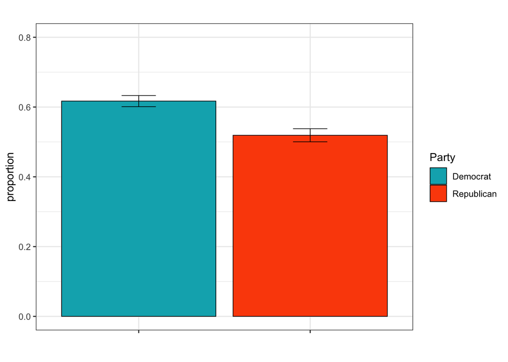

```r
##################################################################
# summarySE function (for barplots) #
##################################################################
summarySE <- function(data=NULL, measurevar, groupvars=NULL, na.rm=FALSE,
                      conf.interval=.95, .drop=TRUE) {
  library(plyr)

  # New version of length which can handle NA's: if na.rm==T, don't count them
  length2 <- function (x, na.rm=FALSE) {
    if (na.rm) sum(!is.na(x))
    else       length(x)
  }

  # This does the summary. For each group's data frame, return a vector with
  # N, mean, and sd
  datac <- ddply(data, groupvars, .drop=.drop,
                 .fun = function(xx, col) {
                   c(N    = length2(xx[[col]], na.rm=na.rm),
                     mean = mean   (xx[[col]], na.rm=na.rm),
                     sd   = sd     (xx[[col]], na.rm=na.rm)
                   )
                 },
                 measurevar
  )

  # Rename the "mean" column
  datac <- rename(datac, c("mean" = measurevar))

  datac$se <- datac$sd / sqrt(datac$N)  # Calculate standard error of the mean

  # Confidence interval multiplier for standard error
  # Calculate t-statistic for confidence interval:
  # e.g., if conf.interval is .95, use .975 (above/below), and use df=N-1
  ciMult <- qt(conf.interval/2 + .5, datac$N-1)
  datac$ci <- datac$se * ciMult

  return(datac)
}

##################################################################

# Figure 1. Proportion of Democrats and Republicans choosing "nonpartisan election" #

##################################################################
#sb

sbPlot <- cces2.2
sbPlot$pid <- factor(sbPlot$pid)
sbPlot <- summarySE(cces2.2, measurevar="RCO322_np", groupvars=c("pid"), na.rm=TRUE)
sbPlot$office <- "school board"
sbPlot$proportion <- sbPlot$RCO322_np
sbPlot$RCO322_np <- NULL

sb_party_Plot <- ggplot(sbPlot, aes(x=pid, y=proportion, fill=pid))
sb_party_Plot +
  scale_fill_manual(values=c("#00AFBB", "#FC4E07"),
                    name="Party", # Legend label, use darker colors
                    breaks=c("Democrat", "Republican"),
                    labels=c("Democrat", "Republican")) +
  geom_bar(position=position_dodge(), stat="identity",
           colour="black", # Use black outlines,
           size=.3) +      # Thinner lines
  geom_errorbar(aes(ymin=proportion-se, ymax=proportion+se),
                size=.3,    # Thinner lines
                width=.2,
                position=position_dodge(.9))+
  xlab("") +
  scale_x_discrete(breaks=c("Democrat","Republican"),
                   labels=c("", "")) +
  ylab("proportion") +
  ylim(0,0.8) +
  ggtitle("") +
  theme_bw()
```

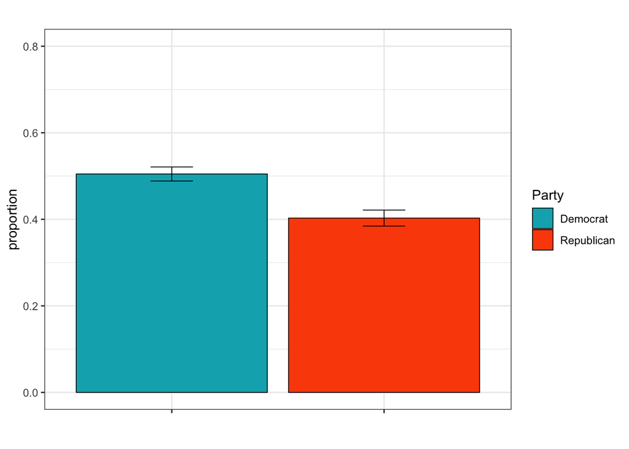

```r
#leo

leoPlot <- cces2.2
leoPlot$pid <- factor(leoPlot$pid)
leoPlot <- summarySE(cces2.2, measurevar="RCO321_np", groupvars=c("pid"), na.rm=TRUE)
leoPlot$office <- "local election official"
leoPlot$proportion <- leoPlot$RCO321_np
leoPlot$RCO321_np <- NULL

leo_party_Plot <- ggplot(leoPlot, aes(x=pid, y=proportion, fill=pid))
leo_party_Plot +
  scale_fill_manual(values=c("#00AFBB", "#FC4E07"),
                    name="Party", # Legend label, use darker colors
                    breaks=c("Democrat", "Republican"),
                    labels=c("Democrat", "Republican")) +
  geom_bar(position=position_dodge(), stat="identity",
           colour="black", # Use black outlines,
           size=.3) +      # Thinner lines
  geom_errorbar(aes(ymin=proportion-se, ymax=proportion+se),
                size=.3,    # Thinner lines
                width=.2,
                position=position_dodge(.9))+
  xlab("") +
  scale_x_discrete(breaks=c("Democrat","Republican"),
                   labels=c("", "")) +
  ylab("proportion") +
  ylim(0,0.8) +
  ggtitle("") +
  theme_bw()
```

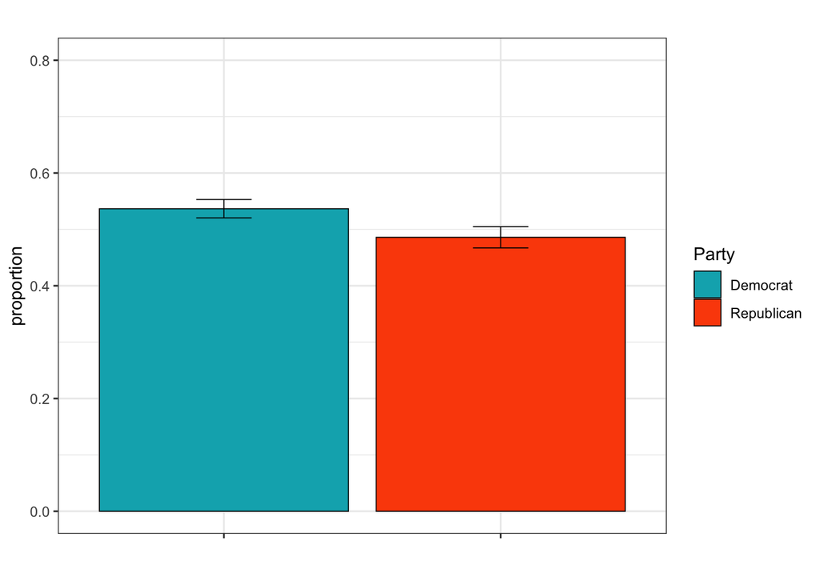

```r
#sheriff

sherPlot <- cces2.2
sherPlot$pid <- factor(sherPlot$pid)
sherPlot <- summarySE(cces2.2, measurevar="RCO323_np", groupvars=c("pid"), na.rm=TRUE)
sherPlot$office <- "sheriff"
sherPlot$proportion <- sherPlot$RCO323_np
sherPlot$RCO323_np <- NULL

sher_party_Plot <- ggplot(sherPlot, aes(x=pid, y=proportion, fill=pid))
sher_party_Plot +
  scale_fill_manual(values=c("#00AFBB", "#FC4E07"),
                    name="Party", # Legend label, use darker colors
                    breaks=c("Democrat", "Republican"),
                    labels=c("Democrat", "Republican")) +
  geom_bar(position=position_dodge(), stat="identity",
           colour="black", # Use black outlines,
           size=.3) +      # Thinner lines
  geom_errorbar(aes(ymin=proportion-se, ymax=proportion+se),
                size=.3,    # Thinner lines
                width=.2,
                position=position_dodge(.9))+
  xlab("") +
  scale_x_discrete(breaks=c("Democrat","Republican"),
                   labels=c("", "")) +
  ylab("proportion") +
  ylim(0,0.8) +
  ggtitle("") +
  theme_bw()
```

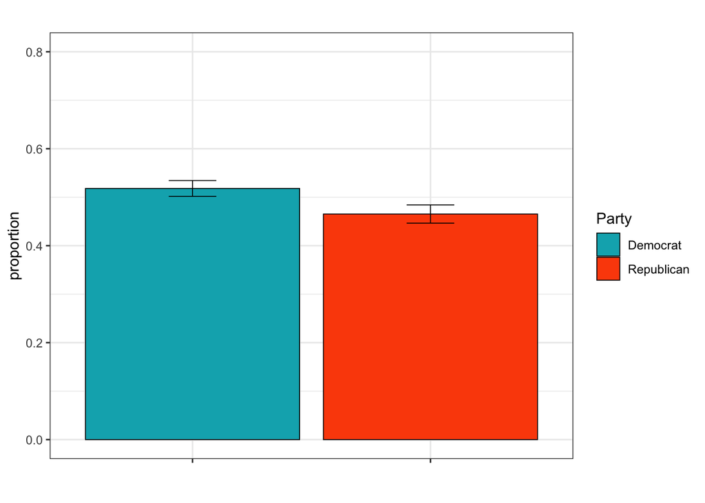

```r
#da

daPlot <- cces2.2
daPlot$pid <- factor(daPlot$pid)
daPlot <- summarySE(cces2.2, measurevar="RCO324_np", groupvars=c("pid"), na.rm=TRUE)
daPlot$office <- "district attorney"
daPlot$proportion <- daPlot$RCO324_np
daPlot$RCO324_np <- NULL

da_party_Plot <- ggplot(daPlot, aes(x=pid, y=proportion, fill=pid))
da_party_Plot +
  scale_fill_manual(values=c("#00AFBB", "#FC4E07"),
                    name="Party", # Legend label, use darker colors
                    breaks=c("Democrat", "Republican"),
                    labels=c("Democrat", "Republican")) +
  geom_bar(position=position_dodge(), stat="identity",
           colour="black", # Use black outlines,
           size=.3) +      # Thinner lines
  geom_errorbar(aes(ymin=proportion-se, ymax=proportion+se),
                size=.3,    # Thinner lines
                width=.2,
                position=position_dodge(.9))+
  xlab("") +
  scale_x_discrete(breaks=c("Democrat","Republican"),
                   labels=c("", "")) +
  ylab("proportion") +
  ylim(0,0.8) +
  ggtitle("") +
  theme_bw()
```

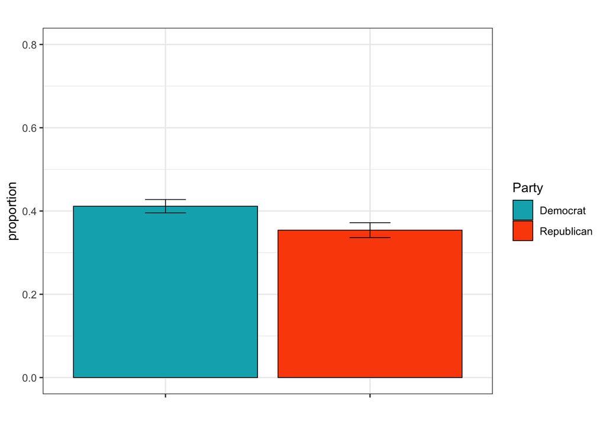

```r
#House

housePlot <- cces2.2
housePlot$pid <- factor(housePlot$pid)
housePlot <- summarySE(cces2.2, measurevar="RCO327_np", groupvars=c("pid"), na.rm=TRUE)
housePlot$office <- "u.s. house"
housePlot$proportion <- housePlot$RCO327_np
housePlot$RCO327_np <- NULL

house_party_Plot <- ggplot(housePlot, aes(x=pid, y=proportion, fill=pid))
house_party_Plot +
  scale_fill_manual(values=c("#00AFBB", "#FC4E07"),
                    name="Party", # Legend label, use darker colors
                    breaks=c("Democrat", "Republican"),
                    labels=c("Democrat", "Republican")) +
  geom_bar(position=position_dodge(), stat="identity",
           colour="black", # Use black outlines,
           size=.3) +      # Thinner lines
  geom_errorbar(aes(ymin=proportion-se, ymax=proportion+se),
                size=.3,    # Thinner lines
                width=.2,
                position=position_dodge(.9))+
  xlab("") +
  scale_x_discrete(breaks=c("Democrat","Republican"),
                   labels=c("", "")) +
  ylab("proportion") +
  ylim(0,0.8) +
  ggtitle("") +
  theme_bw()
```

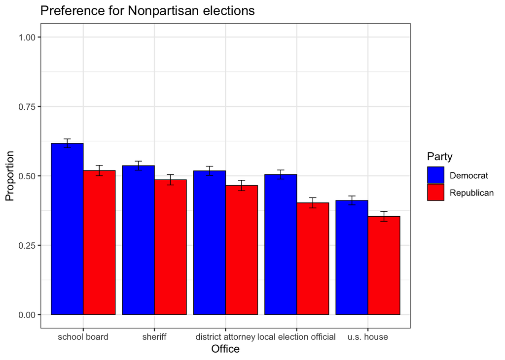

```r
### Combining dataframes ##

localofficePlot <- rbind(sbPlot, leoPlot, sherPlot, daPlot, housePlot)

localofficePlot$office <- ordered(localofficePlot$office,
                                  levels = c("school board", "sheriff",
                                             "district attorney",
                                             "local election official",
                                             "u.s. house"))

local_np_partyplot <- ggplot(localofficePlot, aes(x=office, y=proportion, fill=pid)) +
  xlab("Office") +
  ylab("Proportion") +
  scale_fill_manual(values=c("blue", "red"),
                    name="Party", # Legend label, use darker colors
                    breaks=c("Democrat", "Republican"),
                    labels=c("Democrat", "Republican")) +
  geom_bar(position=position_dodge(), stat="identity",
           colour="black", # Use black outlines,
           size=.3) +      # Thinner lines
  geom_errorbar(aes(ymin=proportion-se, ymax=proportion+se),
                size=.3,    # Thinner lines
                width=.2,
                position=position_dodge(.9))+
  ggtitle("Preference for Nonpartisan elections") +
  ylim(0,1)+
  theme_bw()

local_np_partyplot
```

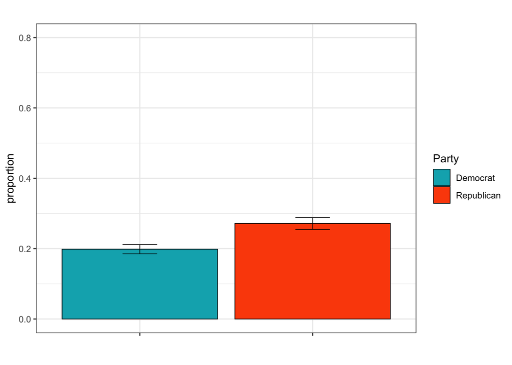

```r
##################################################################

# Figure 2. Proportion of Democrats and Republicans choosing "partisan election" #

##################################################################

sbPlotP <- cces2.2
sbPlotP$pid <- factor(sbPlotP$pid)
sbPlotP <- summarySE(cces2.2, measurevar="RCO322_p", groupvars=c("pid"), na.rm=TRUE)
sbPlotP$office <- "school board"
sbPlotP$proportion <- sbPlotP$RCO322_p
sbPlotP$RCO322_p <- NULL

sb_party_PlotP <- ggplot(sbPlotP, aes(x=pid, y=proportion, fill=pid))
sb_party_PlotP +
  scale_fill_manual(values=c("#00AFBB", "#FC4E07"),
                    name="Party", # Legend label, use darker colors
                    breaks=c("Democrat", "Republican"),
                    labels=c("Democrat", "Republican")) +
  geom_bar(position=position_dodge(), stat="identity",
           colour="black", # Use black outlines,
           size=.3) +      # Thinner lines
  geom_errorbar(aes(ymin=proportion-se, ymax=proportion+se),
                size=.3,    # Thinner lines
                width=.2,
                position=position_dodge(.9))+
  xlab("") +
  scale_x_discrete(breaks=c("Democrat","Republican"),
                   labels=c("", "")) +
  ylab("proportion") +
  ylim(0,0.8) +
  ggtitle("") +
  theme_bw()
```

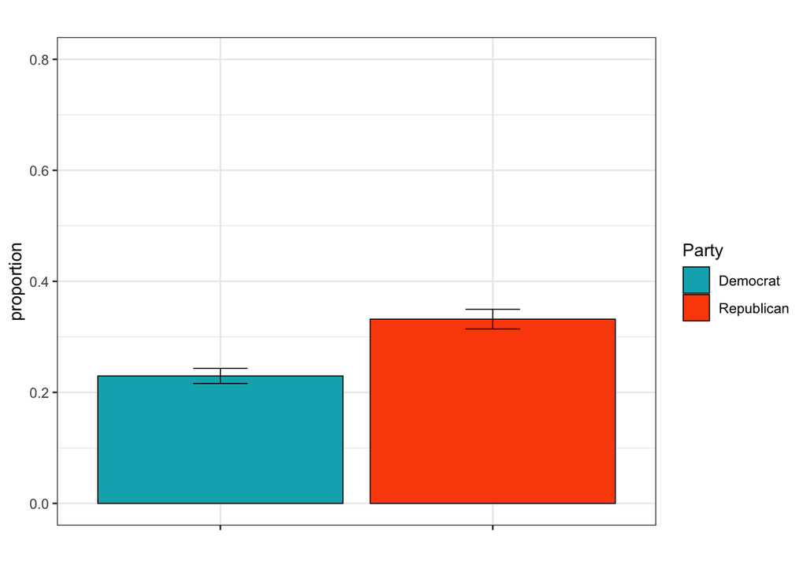

```r
#leo

leoPlotP <- cces2.2
leoPlotP$pid <- factor(leoPlotP$pid)
leoPlotP <- summarySE(cces2.2, measurevar="RCO321_p", groupvars=c("pid"), na.rm=TRUE)
leoPlotP$office <- "local election official"
leoPlotP$proportion <- leoPlotP$RCO321_p
leoPlotP$RCO321_p <- NULL

leo_party_PlotP <- ggplot(leoPlotP, aes(x=pid, y=proportion, fill=pid))
leo_party_PlotP +
  scale_fill_manual(values=c("#00AFBB", "#FC4E07"),
                    name="Party", # Legend label, use darker colors
                    breaks=c("Democrat", "Republican"),
                    labels=c("Democrat", "Republican")) +
  geom_bar(position=position_dodge(), stat="identity",
           colour="black", # Use black outlines,
           size=.3) +      # Thinner lines
  geom_errorbar(aes(ymin=proportion-se, ymax=proportion+se),
                size=.3,    # Thinner lines
                width=.2,
                position=position_dodge(.9))+
  xlab("") +
  scale_x_discrete(breaks=c("Democrat","Republican"),
                   labels=c("", "")) +
  ylab("proportion") +
  ylim(0,0.8) +
  ggtitle("") +
  theme_bw()
```

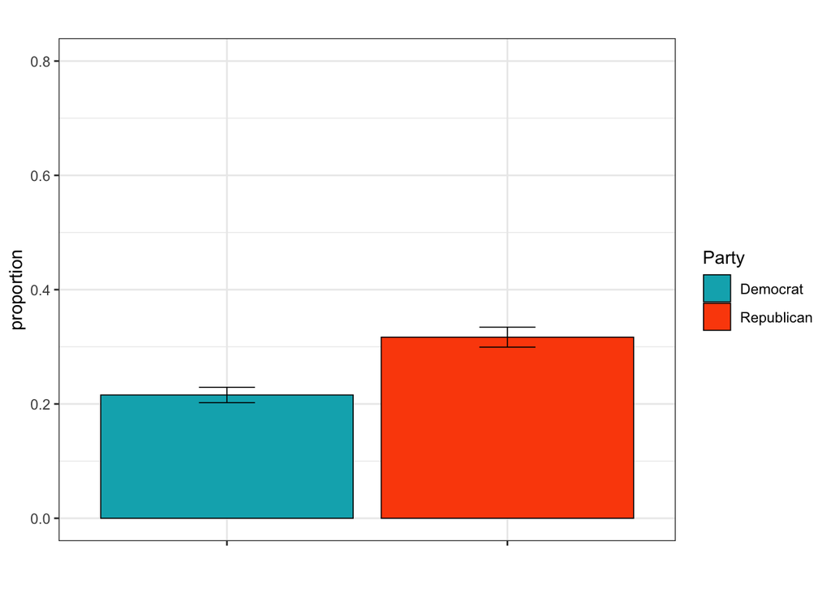

```r
#sheriff

sherPlotP <- cces2.2
sherPlotP$pid <- factor(sherPlotP$pid)
sherPlotP <- summarySE(cces2.2, measurevar="RCO323_p", groupvars=c("pid"), na.rm=TRUE)
sherPlotP$office <- "sheriff"
sherPlotP$proportion <- sherPlotP$RCO323_p
sherPlotP$RCO323_p <- NULL

sher_party_PlotP <- ggplot(sherPlotP, aes(x=pid, y=proportion, fill=pid))
sher_party_PlotP +
  scale_fill_manual(values=c("#00AFBB", "#FC4E07"),
                    name="Party", # Legend label, use darker colors
                    breaks=c("Democrat", "Republican"),
                    labels=c("Democrat", "Republican")) +
  geom_bar(position=position_dodge(), stat="identity",
           colour="black", # Use black outlines,
           size=.3) +      # Thinner lines
  geom_errorbar(aes(ymin=proportion-se, ymax=proportion+se),
                size=.3,    # Thinner lines
                width=.2,
                position=position_dodge(.9))+
  xlab("") +
  scale_x_discrete(breaks=c("Democrat","Republican"),
                   labels=c("", "")) +
  ylab("proportion") +
  ylim(0,0.8) +
  ggtitle("") +
  theme_bw()
```

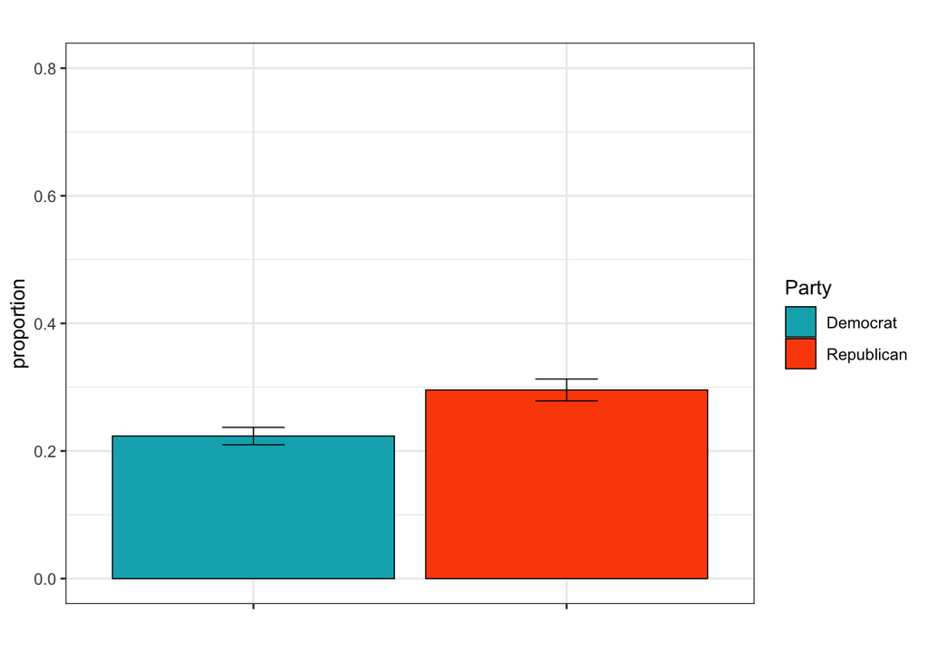

```r
#da

daPlotP <- cces2.2
daPlotP$pid <- factor(daPlotP$pid)
daPlotP <- summarySE(cces2.2, measurevar="RCO324_p", groupvars=c("pid"), na.rm=TRUE)
daPlotP$office <- "district attorney"
daPlotP$proportion <- daPlotP$RCO324_p
daPlotP$RCO324_p <- NULL

da_party_PlotP <- ggplot(daPlotP, aes(x=pid, y=proportion, fill=pid))
da_party_PlotP +
  scale_fill_manual(values=c("#00AFBB", "#FC4E07"),
                    name="Party", # Legend label, use darker colors
                    breaks=c("Democrat", "Republican"),
                    labels=c("Democrat", "Republican")) +
  geom_bar(position=position_dodge(), stat="identity",
           colour="black", # Use black outlines,
           size=.3) +      # Thinner lines
  geom_errorbar(aes(ymin=proportion-se, ymax=proportion+se),
                size=.3,    # Thinner lines
                width=.2,
                position=position_dodge(.9))+
  xlab("") +
  scale_x_discrete(breaks=c("Democrat","Republican"),
                   labels=c("", "")) +
  ylab("proportion") +
  ylim(0,0.8) +
  ggtitle("") +
  theme_bw()
```

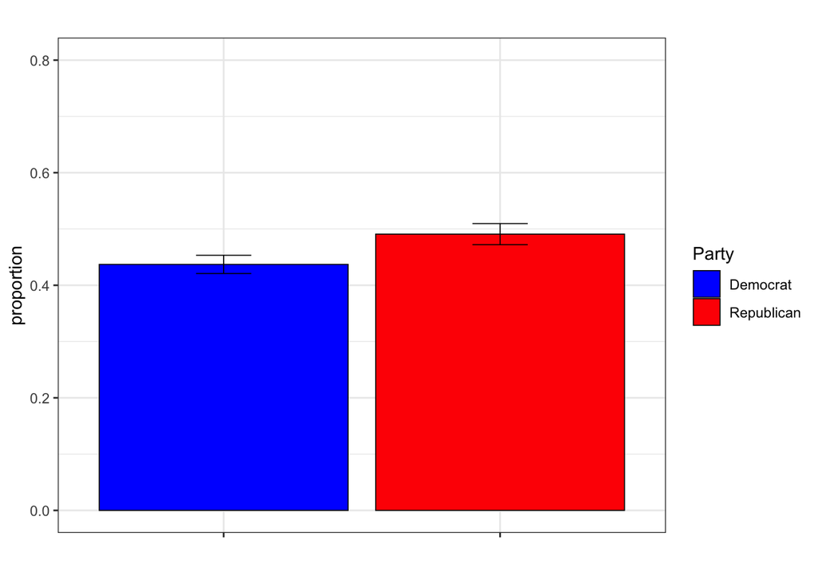

```r
#house

housePlotP <- cces2.2
housePlotP$pid <- factor(housePlotP$pid)
housePlotP <- summarySE(cces2.2, measurevar="RCO327_p", groupvars=c("pid"), na.rm=TRUE)
housePlotP$office <- "u.s. house"
housePlotP$proportion <- housePlotP$RCO327_p
housePlotP$RCO327_p <- NULL

house_party_PlotP <- ggplot(housePlotP, aes(x=pid, y=proportion, fill=pid))
house_party_PlotP +
  scale_fill_manual(values=c("blue", "red"),
                    name="Party", # Legend label, use darker colors
                    breaks=c("Democrat", "Republican"),
                    labels=c("Democrat", "Republican")) +
  geom_bar(position=position_dodge(), stat="identity",
           colour="black", # Use black outlines,
           size=.3) +      # Thinner lines
  geom_errorbar(aes(ymin=proportion-se, ymax=proportion+se),
                size=.3,    # Thinner lines
                width=.2,
                position=position_dodge(.9))+
  xlab("") +
  scale_x_discrete(breaks=c("Democrat","Republican"),
                   labels=c("", "")) +
  ylab("proportion") +
  ylim(0,0.8) +
  ggtitle("") +
  theme_bw()
```

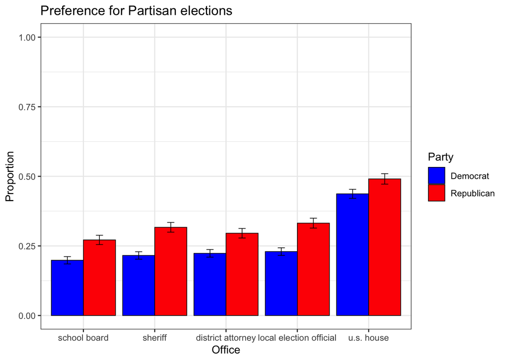

```r
### Combining dataframes ##

localofficePlotP <- rbind(sbPlotP, leoPlotP, sherPlotP, daPlotP, housePlotP)
localofficePlotP$office <- ordered(localofficePlotP$office,
                                   levels = c("school board", "sheriff",
                                              "district attorney",
                                              "local election official",
                                              "u.s. house"))

local_p_partyplot <- ggplot(localofficePlotP, aes(x=office, y=proportion, fill=pid)) +
  xlab("Office") +
  ylab("Proportion") +
  scale_fill_manual(values=c("blue", "red"),
                    name="Party", # Legend label, use darker colors
                    breaks=c("Democrat", "Republican"),
                    labels=c("Democrat", "Republican")) +
  geom_bar(position=position_dodge(), stat="identity",
           colour="black", # Use black outlines,
           size=.3) +      # Thinner lines
  geom_errorbar(aes(ymin=proportion-se, ymax=proportion+se),
                size=.3,    # Thinner lines
                width=.2,
                position=position_dodge(.9))+
  ggtitle("Preference for Partisan elections") +
  ylim(0,1)+
  theme_bw()

local_p_partyplot
```

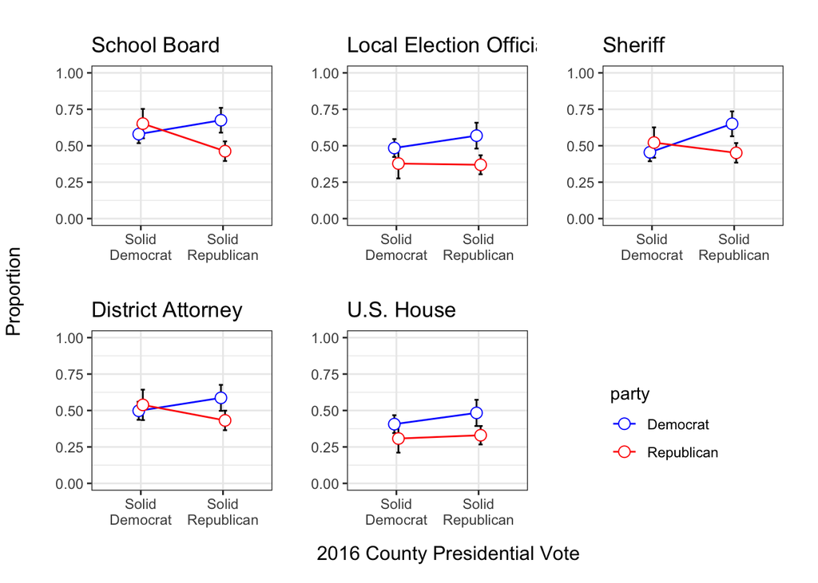

```r
##################################################################

# Figure 3. Inter-party differences #

##################################################################

sbContrast <- cces2.2
sbContrast <- subset(sbContrast, c(Pres_Vote == "Solid Democrat" | Pres_Vote == "Solid Republican"))

sbContrast$pid <- factor(sbContrast$pid)
sbContrastD <- subset(sbContrast, pid=="Democrat")
sbContrastR <- subset(sbContrast, pid=="Republican")

sbContrastD <- summarySE(sbContrastD, measurevar="RCO322_np", groupvars=c("Pres_Vote"), na.rm=TRUE)
sbContrastD$office <- "school board"
sbContrastD$party <- "Democrat"
sbContrastD$proportion <- sbContrastD$RCO322_np
sbContrastD$RCO322_np <- NULL


sbContrastR <- summarySE(sbContrastR, measurevar="RCO322_np", groupvars=c("Pres_Vote"), na.rm=TRUE)
sbContrastR$office <- "school board"
sbContrastR$party <- "Republican"
sbContrastR$proportion <- sbContrastR$RCO322_np
sbContrastR$RCO322_np <- NULL

sbContrastDR <- rbind(sbContrastD, sbContrastR)
sbContrastDR$Pres_Vote <- ordered(sbContrastDR$Pres_Vote,
                                  levels = c("Solid Democrat", "Solid Republican"))

pd <- position_dodge(0.1)
sbCD <- ggplot(sbContrastDR, aes(x=Pres_Vote, y=proportion, colour=party, group=party, legend="right")) +
  geom_errorbar(aes(ymin=proportion-ci, ymax=proportion+ci), colour="black", width=.1, position=pd) +
  geom_line(position=pd) +
  geom_point(position=pd, size=3, shape=21, fill="white") +
  xlab("") +
  ylab("") +
  scale_color_manual(values=c("Democrat" = "blue",
                              "Republican" = "red")) +
  scale_x_discrete(breaks=c("Solid Democrat", "Solid Republican"),
                   labels=c("Solid\nDemocrat", "Solid\nRepublican")) +
  ggtitle("School Board") +
  ylim(0,1) +
  theme_bw()

# leo #
leoContrast <- cces2.2
leoContrast <- subset(leoContrast, c(Pres_Vote == "Solid Democrat" | Pres_Vote == "Solid Republican"))

leoContrast$pid <- factor(leoContrast$pid)
leoContrastD <- subset(leoContrast, pid=="Democrat")
leoContrastR <- subset(leoContrast, pid=="Republican")

leoContrastD <- summarySE(leoContrastD, measurevar="RCO321_np", groupvars=c("Pres_Vote"), na.rm=TRUE)
leoContrastD$office <- "local election official"
leoContrastD$party <- "Democrat"
leoContrastD$proportion <- leoContrastD$RCO321_np
leoContrastD$RCO321_np <- NULL


leoContrastR <- summarySE(leoContrastR, measurevar="RCO321_np", groupvars=c("Pres_Vote"), na.rm=TRUE)
leoContrastR$office <- "local election official"
leoContrastR$party <- "Republican"
leoContrastR$proportion <- leoContrastR$RCO321_np
leoContrastR$RCO321_np <- NULL

leoContrastDR <- rbind(leoContrastD, leoContrastR)
leoContrastDR$Pres_Vote <- ordered(leoContrastDR$Pres_Vote,
                                   levels = c("Solid Democrat", "Solid Republican"))

pd <- position_dodge(0.1)
leoCD <- ggplot(leoContrastDR, aes(x=Pres_Vote, y=proportion, colour=party, group=party, legend="right")) +
  geom_errorbar(aes(ymin=proportion-ci, ymax=proportion+ci), colour="black", width=.1, position=pd) +
  geom_line(position=pd) +
  geom_point(position=pd, size=3, shape=21, fill="white") + # 21 is filled circle
  xlab("") +
  ylab("") +
  scale_color_manual(values=c("Democrat" = "blue",
                              "Republican" = "red")) +
  scale_x_discrete(breaks=c("Solid Democrat", "Solid Republican"),
                   labels=c("Solid\nDemocrat", "Solid\nRepublican")) + # Use darker colors, lightness=40
  ggtitle("Local Election Official") +
  ylim(0,1) +                        # Expand y range        # Set tick every 4
  theme_bw()


# sheriff #
sherContrast <- cces2.2
sherContrast <- subset(leoContrast, c(Pres_Vote == "Solid Democrat" | Pres_Vote == "Solid Republican"))

sherContrast$pid <- factor(sherContrast$pid)
sherContrastD <- subset(sherContrast, pid=="Democrat")
sherContrastR <- subset(sherContrast, pid=="Republican")

sherContrastD <- summarySE(sherContrastD, measurevar="RCO323_np", groupvars=c("Pres_Vote"), na.rm=TRUE)
sherContrastD$office <- "sheriff"
sherContrastD$party <- "Democrat"
sherContrastD$proportion <- sherContrastD$RCO323_np
sherContrastD$RCO323_np <- NULL


sherContrastR <- summarySE(sherContrastR, measurevar="RCO323_np", groupvars=c("Pres_Vote"), na.rm=TRUE)
sherContrastR$office <- "sheriff"
sherContrastR$party <- "Republican"
sherContrastR$proportion <- sherContrastR$RCO323_np
sherContrastR$RCO323_np <- NULL

sherContrastDR <- rbind(sherContrastD, sherContrastR)
sherContrastDR$Pres_Vote <- ordered(sherContrastDR$Pres_Vote,
                                    levels = c("Solid Democrat", "Solid Republican"))

pd <- position_dodge(0.1)
sherCD <- ggplot(sherContrastDR, aes(x=Pres_Vote, y=proportion, colour=party, group=party, legend="right")) +
  geom_errorbar(aes(ymin=proportion-ci, ymax=proportion+ci), colour="black", width=.1, position=pd) +
  geom_line(position=pd) +
  geom_point(position=pd, size=3, shape=21, fill="white") +
  xlab("") +
  ylab("") +
  scale_color_manual(values=c("Democrat" = "blue",
                              "Republican" = "red")) +
  scale_x_discrete(breaks=c("Solid Democrat", "Solid Republican"),
                   labels=c("Solid\nDemocrat", "Solid\nRepublican")) +
  ggtitle("Sheriff") +
  ylim(0,1) +
  theme_bw()


# D.A. #
daContrast <- cces2.2
daContrast <- subset(daContrast, c(Pres_Vote == "Solid Democrat" | Pres_Vote == "Solid Republican"))

daContrast$pid <- factor(daContrast$pid)
daContrastD <- subset(daContrast, pid=="Democrat")
daContrastR <- subset(daContrast, pid=="Republican")

daContrastD <- summarySE(daContrastD, measurevar="RCO324_np", groupvars=c("Pres_Vote"), na.rm=TRUE)
daContrastD$office <- "d.a."
daContrastD$party <- "Democrat"
daContrastD$proportion <- daContrastD$RCO324_np
daContrastD$RCO324_np <- NULL


daContrastR <- summarySE(daContrastR, measurevar="RCO324_np", groupvars=c("Pres_Vote"), na.rm=TRUE)
daContrastR$office <- "d.a."
daContrastR$party <- "Republican"
daContrastR$proportion <- daContrastR$RCO324_np
daContrastR$RCO324_np <- NULL

daContrastDR <- rbind(daContrastD, daContrastR)
daContrastDR$Pres_Vote <- ordered(daContrastDR$Pres_Vote,
                                  levels = c("Solid Democrat", "Solid Republican"))

pd <- position_dodge(0.1)
daCD <- ggplot(daContrastDR, aes(x=Pres_Vote, y=proportion, colour=party, group=party, legend="right")) +
  geom_errorbar(aes(ymin=proportion-ci, ymax=proportion+ci), colour="black", width=.1, position=pd) +
  geom_line(position=pd) +
  geom_point(position=pd, size=3, shape=21, fill="white") +
  xlab("") +
  ylab("") +
  scale_color_manual(values=c("Democrat" = "blue",
                              "Republican" = "red")) +
  scale_x_discrete(breaks=c("Solid Democrat", "Solid Republican"),
                   labels=c("Solid\nDemocrat", "Solid\nRepublican")) +
  ggtitle("District Attorney") +
  ylim(0,1) +
  theme_bw()


# U.S. House
houseContrast <- cces2.2
houseContrast <- subset(daContrast, c(Pres_Vote == "Solid Democrat" | Pres_Vote == "Solid Republican"))

houseContrast$pid <- factor(houseContrast$pid)
houseContrastD <- subset(houseContrast, pid=="Democrat")
houseContrastR <- subset(houseContrast, pid=="Republican")

houseContrastD <- summarySE(houseContrastD, measurevar="RCO327_np", groupvars=c("Pres_Vote"), na.rm=TRUE)
houseContrastD$office <- "u.s. house"
houseContrastD$party <- "Democrat"
houseContrastD$proportion <- houseContrastD$RCO327_np
houseContrastD$RCO327_np <- NULL

houseContrastR <- summarySE(houseContrastR, measurevar="RCO327_np", groupvars=c("Pres_Vote"), na.rm=TRUE)
houseContrastR$office <- "u.s. house"
houseContrastR$party <- "Republican"
houseContrastR$proportion <- houseContrastR$RCO327_np
houseContrastR$RCO327_np <- NULL

houseContrastDR <- rbind(houseContrastD, houseContrastR)
houseContrastDR$Pres_Vote <- ordered(houseContrastDR$Pres_Vote,
                                     levels = c("Solid Democrat", "Solid Republican"))

pd <- position_dodge(0.1)
houseCD <- ggplot(houseContrastDR, aes(x=Pres_Vote, y=proportion, colour=party, group=party, legend="right")) +
  geom_errorbar(aes(ymin=proportion-ci, ymax=proportion+ci), colour="black", width=.1, position=pd) +
  geom_line(position=pd) +
  geom_point(position=pd, size=3, shape=21, fill="white") +
  xlab("") +
  ylab("") +
  scale_color_manual(values=c("Democrat" = "blue",
                              "Republican" = "red")) +
  scale_x_discrete(breaks=c("Solid Democrat", "Solid Republican"),
                   labels=c("Solid\nDemocrat", "Solid\nRepublican")) +
  ggtitle("U.S. House") +
  ylim(0,1) +
  theme_bw()



###### Multiplot for Nonpartisan #####

#extract legend from houseCD (could be any b/c all same legend)
leg <- get_legend(houseCD)

#save earlier plots but remove their legends
sbCD <- sbCD + theme(legend.position = "none")
leoCD <- leoCD + theme(legend.position = "none")
sherCD <- sherCD + theme(legend.position = "none")
daCD <- daCD + theme(legend.position = "none")
houseCD <- houseCD + theme(legend.position = "none")

#arrange plots, and now the extracted legend is a defacto plot (for positioning)
multi_npContrast <- ggarrange(sbCD, leoCD, sherCD,  daCD, houseCD, leg,
                              ncol = 3, nrow = 2,
                              font.label=list(color="black",size=10))

annotate_figure(multi_npContrast,
                top = text_grob("",
                                color = "black", face = "bold", size = 14),
                bottom = text_grob("2016 County Presidential Vote",
                                   color = "black",
                                   hjust = 0.35, vjust = -0.75, size = 12),
                left = text_grob("Proportion", color = "black", rot = 90),
                right = "",
                fig.lab = "", fig.lab.face = "bold"
)
```

```r
##################################################################

# Table 2. Choosing "Nonpartisan election" as preferred selection method by county-level presidential vote #

##################################################################

# Inter-party Diffs, Stratified by County, Showing only highest-level factor coefs
# Re-Running Basic models and Full, Stratified by PresVote, export tables only showing highest level

Basic.inter.sb.SolidD <- glm(RCO322_np ~
                               pid,
                             family="binomial",
                             data = subset(sbMarginsNP2, Pres_Vote.f=="Solid Democrat"))

Finter.sb.SolidD <- glm(RCO322_np ~
                          pid +
                          perceive_extreme_very.f +
                          polint.f +
                          educ.int.f +
                          birthyr,
                        family="binomial",
                        data = subset(sbMarginsNP2, Pres_Vote.f=="Solid Democrat"))

Basic.inter.sb.LeanD <- glm(RCO322_np ~
                              pid,
                            family="binomial",
                            data = subset(sbMarginsNP2, Pres_Vote.f=="Lean Democrat"))

Finter.sb.LeanD <- glm(RCO322_np ~
                         pid +
                         perceive_extreme_very.f +
                         polint.f +
                         educ.int.f +
                         birthyr,
                       family="binomial",
                       data = subset(sbMarginsNP2, Pres_Vote.f=="Lean Democrat"))

Basic.inter.sb.LeanR <- glm(RCO322_np ~
                              pid,
                            family="binomial",
                            data = subset(sbMarginsNP2, Pres_Vote.f=="Lean Republican"))

Finter.sb.LeanR <- glm(RCO322_np ~
                         pid +
                         perceive_extreme_very.f +
                         polint.f +
                         educ.int.f +
                         birthyr,
                       family="binomial",
                       data = subset(sbMarginsNP2, Pres_Vote.f=="Lean Republican"))

Basic.inter.sb.SolidR <- glm(RCO322_np ~
                               pid,
                             family="binomial",
                             data = subset(sbMarginsNP2, Pres_Vote.f=="Solid Republican"))

Finter.sb.SolidR <- glm(RCO322_np ~
                          pid +
                          perceive_extreme_very.f +
                          polint.f +
                          educ.int.f +
                          birthyr,
                        family="binomial",
                        data = subset(sbMarginsNP2, Pres_Vote.f=="Solid Republican"))

pl <- c(
  `pidRepublican` = "Party ID",
  `polint.f4` = "News: Most of the time",
  `educ.int.f5` = "Education: Post-graduate",
  `perceive_extreme_very.f1` = "Out-party is very extreme")

tab_model(Basic.inter.sb.SolidD, Finter.sb.SolidD, Basic.inter.sb.LeanD, Finter.sb.LeanD,
          Basic.inter.sb.LeanR, Finter.sb.LeanR, Basic.inter.sb.SolidR, Finter.sb.SolidR,
          terms=c("pidRepublican",
                  "polint.f4",
                  "educ.int.f5",
                  "perceive_extreme_very.f1"),
          dv.labels = c("Solid Democrat","","Lean Democrat","",
                        "Lean Republican","","Solid Republican",""),
          pred.labels = pl,
          collapse.se=TRUE,
          show.ci=FALSE,
          p.style="stars",
          transform=NULL,
          show.aic=TRUE)
```

Solid Democrat

Lean Democrat

Lean Republican

Solid Republican

Predictors

Log-Odds

Log-Odds

Log-Odds

Log-Odds

Log-Odds

Log-Odds

Log-Odds

Log-Odds

Party ID

0.31  
(0.26)

0.22  
(0.29)

-0.31  
(0.18)

-0.54 **  
(0.20)

-0.54 **  
(0.19)

-0.68 **  
(0.21)

-0.88 ***  
(0.24)

-1.03 ***  
(0.26)

Out-party is very extreme

0.08  
(0.26)

0.04  
(0.20)

0.26  
(0.21)

0.14  
(0.24)

News: Most of the time

0.59  
(0.52)

0.62  
(0.56)

1.74 **  
(0.60)

1.32 *  
(0.58)

Education: Post-graduate

1.76 ***  
(0.39)

0.35  
(0.32)

0.01  
(0.34)

-0.12  
(0.40)

Observations

334

329

515

508

451

445

334

327

R<sup>2</sup> Tjur

0.004

0.143

0.006

0.081

0.018

0.083

0.042

0.099

AIC

452.466

415.858

703.503

670.327

608.668

588.983

450.809

438.261

- p<0.05 ** p<0.01 *** p<0.001

```r
# LEO #

Basic.inter.leo.SolidD <- glm(RCO321_np ~
                                pid,
                              family="binomial",
                              data = subset(leoMarginsNP2, Pres_Vote.f=="Solid Democrat"))

Finter.leo.SolidD <- glm(RCO321_np ~
                           pid +
                           perceive_extreme_very.f +
                           polint.f +
                           educ.int.f +
                           birthyr,
                         family="binomial",
                         data = subset(leoMarginsNP2, Pres_Vote.f=="Solid Democrat"))

Basic.inter.leo.LeanD <- glm(RCO321_np ~
                               pid,
                             family="binomial",
                             data = subset(leoMarginsNP2, Pres_Vote.f=="Lean Democrat"))

Finter.leo.LeanD <- glm(RCO321_np ~
                          pid +
                          perceive_extreme_very.f +
                          polint.f +
                          educ.int.f +
                          birthyr,
                        family="binomial",
                        data = subset(leoMarginsNP2, Pres_Vote.f=="Lean Democrat"))

Basic.inter.leo.LeanR <- glm(RCO321_np ~
                               pid,
                             family="binomial",
                             data = subset(leoMarginsNP2, Pres_Vote.f=="Lean Republican"))

Finter.leo.LeanR <- glm(RCO321_np ~
                          pid +
                          perceive_extreme_very.f +
                          polint.f +
                          educ.int.f +
                          birthyr,
                        family="binomial",
                        data = subset(leoMarginsNP2, Pres_Vote.f=="Lean Republican"))

Basic.inter.leo.SolidR <- glm(RCO321_np ~
                                pid,
                              family="binomial",
                              data = subset(leoMarginsNP2, Pres_Vote.f=="Solid Republican"))

Finter.leo.SolidR <- glm(RCO321_np ~
                           pid +
                           perceive_extreme_very.f +
                           polint.f +
                           educ.int.f +
                           birthyr,
                         family="binomial",
                         data = subset(leoMarginsNP2, Pres_Vote.f=="Solid Republican"))

pl <- c(
  `pidRepublican` = "Party ID",
  `polint.f4` = "News: Most of the time",
  `educ.int.f5` = "Education: Post-graduate",
  `perceive_extreme_very.f1` = "Out-party is very extreme")

tab_model(Basic.inter.leo.SolidD, Finter.leo.SolidD, Basic.inter.leo.LeanD, Finter.leo.LeanD,
          Basic.inter.leo.LeanR, Finter.leo.LeanR, Basic.inter.leo.SolidR, Finter.leo.SolidR,
          terms=c("pidRepublican",
                  "polint.f4",
                  "educ.int.f5",
                  "perceive_extreme_very.f1"),
          dv.labels = c("Solid Democrat","","Lean Democrat","",
                        "Lean Republican","","Solid Republican",""),
          pred.labels = pl,
          collapse.se=TRUE,
          show.ci=FALSE,
          p.style="stars",
          transform=NULL,
          show.aic=TRUE)
```

Solid Democrat

Lean Democrat

Lean Republican

Solid Republican

Predictors

Log-Odds

Log-Odds

Log-Odds

Log-Odds

Log-Odds

Log-Odds

Log-Odds

Log-Odds

Party ID

-0.44  
(0.25)

-0.55 *  
(0.27)

0.11  
(0.18)

0.01  
(0.19)

-0.74 ***  
(0.19)

-0.80 ***  
(0.21)

-0.81 ***  
(0.23)

-0.99 ***  
(0.25)

Out-party is very extreme

0.20  
(0.24)

-0.39 *  
(0.19)

0.21  
(0.20)

0.41  
(0.24)

News: Most of the time

0.85  
(0.57)

1.13  
(0.61)

1.38 *  
(0.60)

1.34 *  
(0.62)

Education: Post-graduate

0.51  
(0.34)

-0.07  
(0.30)

-0.12  
(0.34)

-0.42  
(0.40)

Observations

346

341

518

510

449

443

337

330

R<sup>2</sup> Tjur

0.009

0.062

0.001

0.031

0.033

0.065

0.038

0.081

AIC

477.975

470.758

720.603

712.251

608.819

603.787

453.998

448.427

- p<0.05 ** p<0.01 *** p<0.001

```r
# sheriff #

Basic.inter.sher.SolidD <- glm(RCO323_np ~
                                 pid,
                               family="binomial",
                               data = subset(sherMarginsNP2, Pres_Vote.f=="Solid Democrat"))

Finter.sher.SolidD <- glm(RCO323_np ~
                            pid +
                            perceive_extreme_very.f +
                            polint.f +
                            educ.int.f +
                            birthyr,
                          family="binomial",
                          data = subset(sherMarginsNP2, Pres_Vote.f=="Solid Democrat"))

Basic.inter.sher.LeanD <- glm(RCO323_np ~
                                pid,
                              family="binomial",
                              data = subset(sherMarginsNP2, Pres_Vote.f=="Lean Democrat"))

Finter.sher.LeanD <- glm(RCO323_np ~
                           pid +
                           perceive_extreme_very.f +
                           polint.f +
                           educ.int.f +
                           birthyr,
                         family="binomial",
                         data = subset(sherMarginsNP2, Pres_Vote.f=="Lean Democrat"))

Basic.inter.sher.LeanR <- glm(RCO323_np ~
                                pid,
                              family="binomial",
                              data = subset(sherMarginsNP2, Pres_Vote.f=="Lean Republican"))

Finter.sher.LeanR <- glm(RCO323_np ~
                           pid +
                           perceive_extreme_very.f +
                           polint.f +
                           educ.int.f +
                           birthyr,
                         family="binomial",
                         data = subset(sherMarginsNP2, Pres_Vote.f=="Lean Republican"))

Basic.inter.sher.SolidR <- glm(RCO323_np ~
                                 pid,
                               family="binomial",
                               data = subset(sherMarginsNP2, Pres_Vote.f=="Solid Republican"))

Finter.sher.SolidR <- glm(RCO323_np ~
                            pid +
                            perceive_extreme_very.f +
                            polint.f +
                            educ.int.f +
                            birthyr,
                          family="binomial",
                          data = subset(sherMarginsNP2, Pres_Vote.f=="Solid Republican"))

pl <- c(
  `pidRepublican` = "Party ID",
  `polint.f4` = "News: Most of the time",
  `educ.int.f5` = "Education: Post-graduate",
  `perceive_extreme_very.f1` = "Out-party is very extreme")

tab_model(Basic.inter.sher.SolidD, Finter.sher.SolidD, Basic.inter.sher.LeanD, Finter.sher.LeanD,
          Basic.inter.sher.LeanR, Finter.sher.LeanR, Basic.inter.sher.SolidR, Finter.sher.SolidR,
          terms=c("pidRepublican",
                  "polint.f4",
                  "educ.int.f5",
                  "perceive_extreme_very.f1"),
          dv.labels = c("Solid Democrat","","Lean Democrat","",
                        "Lean Republican","","Solid Republican",""),
          pred.labels = pl,
          collapse.se=TRUE,
          show.ci=FALSE,
          p.style="stars",
          transform=NULL,
          show.aic=TRUE)
```

Solid Democrat

Lean Democrat

Lean Republican

Solid Republican

Predictors

Log-Odds

Log-Odds

Log-Odds

Log-Odds

Log-Odds

Log-Odds

Log-Odds

Log-Odds

Party ID

0.27  
(0.24)

0.22  
(0.26)

0.10  
(0.18)

-0.03  
(0.20)

-0.53 **  
(0.19)

-0.59 **  
(0.20)

-0.82 ***  
(0.23)

-0.96 ***  
(0.25)

Out-party is very extreme

0.02  
(0.24)

0.15  
(0.19)

0.10  
(0.20)

0.18  
(0.24)

News: Most of the time

0.63  
(0.53)

0.58  
(0.56)

0.84  
(0.54)

1.57 **  
(0.59)

Education: Post-graduate

0.70 *  
(0.34)

0.20  
(0.30)

0.08  
(0.33)

-0.65  
(0.39)

Observations

347

342

514

506

452

446

338

331

R<sup>2</sup> Tjur

0.003

0.061

0.001

0.043

0.017

0.047

0.037

0.097

AIC

482.793

473.817

713.752

698.025

622.246

618.267

459.209

445.604

- p<0.05 ** p<0.01 *** p<0.001

```r
# d.a. #

Basic.inter.da.SolidD <- glm(RCO324_np ~
                               pid,
                             family="binomial",
                             data = subset(daMarginsNP2, Pres_Vote.f=="Solid Democrat"))

Finter.da.SolidD <- glm(RCO324_np ~
                          pid +
                          perceive_extreme_very.f +
                          polint.f +
                          educ.int.f +
                          birthyr,
                        family="binomial",
                        data = subset(daMarginsNP2, Pres_Vote.f=="Solid Democrat"))

Basic.inter.da.LeanD <- glm(RCO324_np ~
                              pid,
                            family="binomial",
                            data = subset(daMarginsNP2, Pres_Vote.f=="Lean Democrat"))

Finter.da.LeanD <- glm(RCO324_np ~
                         pid +
                         perceive_extreme_very.f +
                         polint.f +
                         educ.int.f +
                         birthyr,
                       family="binomial",
                       data = subset(daMarginsNP2, Pres_Vote.f=="Lean Democrat"))

Basic.inter.da.LeanR <- glm(RCO324_np ~
                              pid,
                            family="binomial",
                            data = subset(daMarginsNP2, Pres_Vote.f=="Lean Republican"))

Finter.da.LeanR <- glm(RCO324_np ~
                         pid +
                         perceive_extreme_very.f +
                         polint.f +
                         educ.int.f +
                         birthyr,
                       family="binomial",
                       data = subset(daMarginsNP2, Pres_Vote.f=="Lean Republican"))

Basic.inter.da.SolidR <- glm(RCO324_np ~
                               pid,
                             family="binomial",
                             data = subset(daMarginsNP2, Pres_Vote.f=="Solid Republican"))

Finter.da.SolidR <- glm(RCO324_np ~
                          pid +
                          perceive_extreme_very.f +
                          polint.f +
                          educ.int.f +
                          birthyr,
                        family="binomial",
                        data = subset(daMarginsNP2, Pres_Vote.f=="Solid Republican"))

pl <- c(
  `pidRepublican` = "Party ID",
  `polint.f4` = "News: Most of the time",
  `educ.int.f5` = "Education: Post-graduate",
  `perceive_extreme_very.f1` = "Out-party is very extreme")

tab_model(Basic.inter.da.SolidD, Finter.da.SolidD, Basic.inter.da.LeanD, Finter.da.LeanD,
          Basic.inter.da.LeanR, Finter.da.LeanR, Basic.inter.da.SolidR, Finter.da.SolidR,
          terms=c("pidRepublican",
                  "polint.f4",
                  "educ.int.f5",
                  "perceive_extreme_very.f1"),
          dv.labels = c("Solid Democrat","","Lean Democrat","",
                        "Lean Republican","","Solid Republican",""),
          pred.labels = pl,
          collapse.se=TRUE,
          show.ci=FALSE,
          p.style="stars",
          transform=NULL,
          show.aic=TRUE)
```

Solid Democrat

Lean Democrat

Lean Republican

Solid Republican

Predictors

Log-Odds

Log-Odds

Log-Odds

Log-Odds

Log-Odds

Log-Odds

Log-Odds

Log-Odds

Party ID

0.16  
(0.24)

0.09  
(0.27)

0.21  
(0.18)

0.10  
(0.20)

-0.60 **  
(0.19)

-0.77 ***  
(0.21)

-0.62 **  
(0.23)

-0.88 ***  
(0.25)

Out-party is very extreme

0.16  
(0.25)

-0.11  
(0.19)

0.21  
(0.20)

0.24  
(0.24)

News: Most of the time

0.19  
(0.52)

1.50 *  
(0.67)

1.01  
(0.57)

2.77 ***  
(0.79)

Education: Post-graduate

1.25 ***  
(0.36)

0.29  
(0.30)

0.03  
(0.34)

-0.43  
(0.39)

Observations

346

341

515

507

452

446

334

327

R<sup>2</sup> Tjur

0.001

0.123

0.003

0.041

0.022

0.063

0.022

0.108

AIC

483.115

450.511

716.605

703.438

620.238

611.336

459.399

437.536

- p<0.05 ** p<0.01 *** p<0.001

```r
# House #

Basic.inter.house.SolidD <- glm(RCO327_np ~
                                  pid,
                                family="binomial",
                                data = subset(houseMarginsNP2, Pres_Vote.f=="Solid Democrat"))

Finter.house.SolidD <- glm(RCO327_np ~
                             pid +
                             perceive_extreme_very.f +
                             polint.f +
                             educ.int.f +
                             birthyr,
                           family="binomial",
                           data = subset(houseMarginsNP2, Pres_Vote.f=="Solid Democrat"))

Basic.inter.house.LeanD <- glm(RCO327_np ~
                                 pid,
                               family="binomial",
                               data = subset(houseMarginsNP2, Pres_Vote.f=="Lean Democrat"))

Finter.house.LeanD <- glm(RCO327_np ~
                            pid +
                            perceive_extreme_very.f +
                            polint.f +
                            educ.int.f +
                            birthyr,
                          family="binomial",
                          data = subset(houseMarginsNP2, Pres_Vote.f=="Lean Democrat"))

Basic.inter.house.LeanR <- glm(RCO327_np ~
                                 pid,
                               family="binomial",
                               data = subset(houseMarginsNP2, Pres_Vote.f=="Lean Republican"))

Finter.house.LeanR <- glm(RCO327_np ~
                            pid +
                            perceive_extreme_very.f +
                            polint.f +
                            educ.int.f +
                            birthyr,
                          family="binomial",
                          data = subset(houseMarginsNP2, Pres_Vote.f=="Lean Republican"))

Basic.inter.house.SolidR <- glm(RCO327_np ~
                                  pid,
                                family="binomial",
                                data = subset(houseMarginsNP2, Pres_Vote.f=="Solid Republican"))

Finter.house.SolidR <- glm(RCO327_np ~
                             pid +
                             perceive_extreme_very.f +
                             polint.f +
                             educ.int.f +
                             birthyr,
                           family="binomial",
                           data = subset(houseMarginsNP2, Pres_Vote.f=="Solid Republican"))

pl <- c(
  `pidRepublican` = "Party ID",
  `polint.f4` = "News: Most of the time",
  `educ.int.f5` = "Education: Post-graduate",
  `perceive_extreme_very.f1` = "Out-party is very extreme")

tab_model(Basic.inter.house.SolidD, Finter.house.SolidD, Basic.inter.house.LeanD, Finter.house.LeanD,
          Basic.inter.house.LeanR, Finter.house.LeanR, Basic.inter.house.SolidR, Finter.house.SolidR,
          terms=c("pidRepublican",
                  "polint.f4",
                  "educ.int.f5",
                  "perceive_extreme_very.f1"),
          dv.labels = c("Solid Democrat","","Lean Democrat","",
                        "Lean Republican","","Solid Republican",""),
          pred.labels = pl,
          collapse.se=TRUE,
          show.ci=FALSE,
          p.style="stars",
          transform=NULL,
          show.aic=TRUE)
```

Solid Democrat

Lean Democrat

Lean Republican

Solid Republican

Predictors

Log-Odds

Log-Odds

Log-Odds

Log-Odds

Log-Odds

Log-Odds

Log-Odds

Log-Odds

Party ID

-0.43  
(0.26)

-0.43  
(0.27)

0.33  
(0.18)

0.22  
(0.19)

-0.52 **  
(0.20)

-0.60 **  
(0.21)

-0.64 **  
(0.23)

-0.78 **  
(0.25)

Out-party is very extreme

-0.20  
(0.25)

-0.16  
(0.19)

-0.18  
(0.21)

0.45  
(0.24)

News: Most of the time

-0.10  
(0.52)

-0.06  
(0.56)

0.55  
(0.57)

1.38 *  
(0.69)

Education: Post-graduate

0.50  
(0.35)

-0.35  
(0.31)

-0.88 *  
(0.40)

-0.64  
(0.40)

Observations

342

337

518

510

450

444

337

330

R<sup>2</sup> Tjur

0.008

0.030

0.006

0.025

0.015

0.060

0.023

0.083

AIC

455.445

461.097

704.502

703.667

584.108

572.597

445.764

435.151

- p<0.05 ** p<0.01 *** p<0.001

```r
##################################################################

### Figure 4. Inter-party differences in predicted probability of choosing nonpartisan elections.

##################################################################

Finter.sb.SolidD <- glm(RCO322_np ~
                          pid +
                          perceive_extreme_very.f +
                          polint.f +
                          educ.int.f +
                          birthyr,
                        family="binomial",
                        data = subset(sbMarginsNP2, Pres_Vote.f=="Solid Democrat"))
#
Finter.sb.LeanD <- glm(RCO322_np ~
                         pid +
                         perceive_extreme_very.f +
                         polint.f +
                         educ.int.f +
                         birthyr,
                       family="binomial",
                       data = subset(sbMarginsNP2, Pres_Vote.f=="Lean Democrat"))
#
Finter.sb.LeanR <- glm(RCO322_np ~
                         pid +
                         perceive_extreme_very.f +
                         polint.f +
                         educ.int.f +
                         birthyr,
                       family="binomial",
                       data = subset(sbMarginsNP2, Pres_Vote.f=="Lean Republican"))
#
Finter.sb.SolidR <- glm(RCO322_np ~
                          pid +
                          perceive_extreme_very.f +
                          polint.f +
                          educ.int.f +
                          birthyr,
                        family="binomial",
                        data = subset(sbMarginsNP2, Pres_Vote.f=="Solid Republican"))

# Using margins() we calculate the marginal effects for each variable:

sbInter.mSolidD <- margins(Finter.sb.SolidD)
sbInter.mLeanD <- margins(Finter.sb.LeanD)
sbInter.mLeanR <- margins(Finter.sb.LeanR)
sbInter.mSolidR <- margins(Finter.sb.SolidR)

#we can take results from margins() and plot them ourselves.
#To clean up the summary a little a little, we convert it to a tibble,
#then use prefix_strip() and prefix_replace() to tidy the labels.

bo_gg_SolidD <- as_tibble(summary(sbInter.mSolidD))
bo_gg_LeanD <- as_tibble(summary(sbInter.mLeanD))
bo_gg_LeanR <- as_tibble(summary(sbInter.mLeanR))
bo_gg_SolidR <- as_tibble(summary(sbInter.mSolidR))

bo_gg_SolidD %>% select(factor, AME, lower, upper)
```

```
## # A tibble: 10 x 4
##    factor                        AME    lower    upper
##    <chr>                       <dbl>    <dbl>    <dbl>
##  1 birthyr                  -0.00276 -0.00579 0.000274
##  2 educ.int.f2               0.142   -0.0328  0.317
##  3 educ.int.f3               0.119   -0.0782  0.317
##  4 educ.int.f4               0.254    0.0981  0.410
##  5 educ.int.f5               0.379    0.229   0.528
##  6 perceive_extreme_very.f1  0.0169  -0.0876  0.121
##  7 pidRepublican             0.0444  -0.0695  0.158
##  8 polint.f2                -0.0136  -0.276   0.249
##  9 polint.f3                 0.0254  -0.206   0.257
## 10 polint.f4                 0.128   -0.0984  0.354
```

```r
bo_gg_LeanD %>% select(factor, AME, lower, upper)
```

```
## # A tibble: 10 x 4
##    factor                        AME    lower     upper
##    <chr>                       <dbl>    <dbl>     <dbl>
##  1 birthyr                  -0.00339 -0.00587 -0.000902
##  2 educ.int.f2              -0.0390  -0.160    0.0822
##  3 educ.int.f3               0.0754  -0.0893   0.240
##  4 educ.int.f4               0.0481  -0.0688   0.165
##  5 educ.int.f5               0.0789  -0.0586   0.217
##  6 perceive_extreme_very.f1  0.00913 -0.0771   0.0954
##  7 pidRepublican            -0.121   -0.209   -0.0317
##  8 polint.f2                -0.0969  -0.372    0.178
##  9 polint.f3                 0.00885 -0.253    0.271
## 10 polint.f4                 0.144   -0.118    0.406
```

```r
bo_gg_LeanR %>% select(factor, AME, lower, upper)
```

```
## # A tibble: 10 x 4
##    factor                        AME    lower     upper
##    <chr>                       <dbl>    <dbl>     <dbl>
##  1 birthyr                  -0.00196 -0.00466  0.000741
##  2 educ.int.f2               0.0954  -0.0297   0.221
##  3 educ.int.f3               0.0384  -0.118    0.195
##  4 educ.int.f4               0.0268  -0.0987   0.152
##  5 educ.int.f5               0.00163 -0.153    0.156
##  6 perceive_extreme_very.f1  0.0580  -0.0327   0.149
##  7 pidRepublican            -0.153   -0.243   -0.0622
##  8 polint.f2                 0.131   -0.124    0.386
##  9 polint.f3                 0.346    0.124    0.568
## 10 polint.f4                 0.391    0.175    0.607
```

```r
bo_gg_SolidR %>% select(factor, AME, lower, upper)
```

```
## # A tibble: 10 x 4
##    factor                        AME    lower    upper
##    <chr>                       <dbl>    <dbl>    <dbl>
##  1 birthyr                  -0.00118 -0.00442  0.00206
##  2 educ.int.f2               0.0960  -0.0392   0.231
##  3 educ.int.f3              -0.124   -0.299    0.0503
##  4 educ.int.f4               0.0450  -0.107    0.197
##  5 educ.int.f5              -0.0261  -0.203    0.151
##  6 perceive_extreme_very.f1  0.0318  -0.0723   0.136
##  7 pidRepublican            -0.231   -0.336   -0.126
##  8 polint.f2                 0.117   -0.143    0.377
##  9 polint.f3                 0.146   -0.0943   0.387
## 10 polint.f4                 0.297    0.0625   0.531
```

```r
## Subset further to plot only certain factors ##

bo_gg_SolidD_2 <- subset(bo_gg_SolidD,
                         factor=="pidRepublican")
bo_gg_SolidD_2$County = "Solid Democrat"
bo_gg_SolidD_2$factor <- as.factor(bo_gg_SolidD_2$factor)
bo_gg_SolidD_2$var1 <- "Republican"

bo_gg_LeanD_2 <- subset(bo_gg_LeanD,
                        factor=="pidRepublican")
bo_gg_LeanD_2$County = "Lean Democrat"
bo_gg_LeanD_2$factor <- as.factor(bo_gg_LeanD_2$factor)
bo_gg_LeanD_2$var1 <- "Republican"

bo_gg_LeanR_2 <- subset(bo_gg_LeanR,
                        factor=="pidRepublican")
bo_gg_LeanR_2$County = "Lean Republican"
bo_gg_LeanR_2$factor <- as.factor(bo_gg_LeanR_2$factor)
bo_gg_LeanR_2$var1 <- "Republican"

bo_gg_SolidR_2 <- subset(bo_gg_SolidR,
                         factor=="pidRepublican")
bo_gg_SolidR_2$County = "Solid Republican"
bo_gg_SolidR_2$factor <- as.factor(bo_gg_SolidR_2$factor)
bo_gg_SolidR_2$var1 <- "Republican"


# Combine Plots #
pd <- position_dodge(0.25)
bo_gg_SB_Combine <- rbind(bo_gg_SolidD_2, bo_gg_LeanD_2, bo_gg_LeanR_2, bo_gg_SolidR_2)
bo_gg_SB_Combine$Office <- "School Board"

ord <- c("Solid Democrat",
         "Lean Democrat",
         "Lean Republican",
         "Solid Republican")

# Correct Order for Plotting
bo_gg_SB_Combine$County <- factor(bo_gg_SB_Combine$County,levels=ord)

## NOW: Repeat above for each office, then RBIND into one big dataframe

Finter.leo.SolidD <- glm(RCO321_np ~
                           pid +
                           perceive_extreme_very.f +
                           polint.f +
                           educ.int.f +
                           birthyr,
                         family="binomial",
                         data = subset(leoMarginsNP2, Pres_Vote.f=="Solid Democrat"))

Finter.leo.LeanD <- glm(RCO321_np ~
                          pid +
                          perceive_extreme_very.f +
                          polint.f +
                          educ.int.f +
                          birthyr,
                        family="binomial",
                        data = subset(leoMarginsNP2, Pres_Vote.f=="Lean Democrat"))

Finter.leo.LeanR <- glm(RCO321_np ~
                          pid +
                          perceive_extreme_very.f +
                          polint.f +
                          educ.int.f +
                          birthyr,
                        family="binomial",
                        data = subset(leoMarginsNP2, Pres_Vote.f=="Lean Republican"))

Finter.leo.SolidR <- glm(RCO321_np ~
                           pid +
                           perceive_extreme_very.f +
                           polint.f +
                           educ.int.f +
                           birthyr,
                         family="binomial",
                         data = subset(leoMarginsNP2, Pres_Vote.f=="Solid Republican"))

# Using margins() we calculate the marginal effects for each variable:

leoInter.mSolidD <- margins(Finter.leo.SolidD)
leoInter.mLeanD <- margins(Finter.leo.LeanD)
leoInter.mLeanR <- margins(Finter.leo.LeanR)
leoInter.mSolidR <- margins(Finter.leo.SolidR)

#we can take results from margins() and plot them ourselves.
#To clean up the summary a little a little, we convert it to a tibble,
#then use prefix_strip() and prefix_replace() to tidy the labels.

LEObo_gg_SolidD <- as_tibble(summary(leoInter.mSolidD))
LEObo_gg_LeanD <- as_tibble(summary(leoInter.mLeanD))
LEObo_gg_LeanR <- as_tibble(summary(leoInter.mLeanR))
LEObo_gg_SolidR <- as_tibble(summary(leoInter.mSolidR))

LEObo_gg_SolidD %>% select(factor, AME, lower, upper)
```

```
## # A tibble: 10 x 4
##    factor                        AME    lower    upper
##    <chr>                       <dbl>    <dbl>    <dbl>
##  1 birthyr                  -0.00435 -0.00750 -0.00120
##  2 educ.int.f2               0.00638 -0.164    0.177
##  3 educ.int.f3              -0.0534  -0.243    0.136
##  4 educ.int.f4              -0.0147  -0.170    0.141
##  5 educ.int.f5               0.120   -0.0367   0.277
##  6 perceive_extreme_very.f1  0.0466  -0.0631   0.156
##  7 pidRepublican            -0.128   -0.246   -0.00875
##  8 polint.f2                 0.287    0.0293   0.544
##  9 polint.f3                 0.168   -0.0553   0.392
## 10 polint.f4                 0.187   -0.0335   0.407
```

```r
LEObo_gg_LeanD %>% select(factor, AME, lower, upper)
```

```
## # A tibble: 10 x 4
##    factor                         AME    lower    upper
##    <chr>                        <dbl>    <dbl>    <dbl>
##  1 birthyr                  -0.000831 -0.00346  0.00179
##  2 educ.int.f2               0.0317   -0.0936   0.157
##  3 educ.int.f3               0.144    -0.0240   0.312
##  4 educ.int.f4              -0.0353   -0.157    0.0866
##  5 educ.int.f5              -0.0161   -0.158    0.126
##  6 perceive_extreme_very.f1 -0.0941   -0.183   -0.00549
##  7 pidRepublican             0.00177  -0.0904   0.0939
##  8 polint.f2                 0.127    -0.121    0.375
##  9 polint.f3                 0.212    -0.0229   0.446
## 10 polint.f4                 0.257     0.0237   0.490
```

```r
LEObo_gg_LeanR %>% select(factor, AME, lower, upper)
```

```
## # A tibble: 10 x 4
##    factor                         AME    lower    upper
##    <chr>                        <dbl>    <dbl>    <dbl>
##  1 birthyr                   0.000780 -0.00200  0.00356
##  2 educ.int.f2               0.0318   -0.0987   0.162
##  3 educ.int.f3              -0.0643   -0.221    0.0929
##  4 educ.int.f4               0.0257   -0.102    0.153
##  5 educ.int.f5              -0.0284   -0.182    0.125
##  6 perceive_extreme_very.f1  0.0497   -0.0425   0.142
##  7 pidRepublican            -0.188    -0.281   -0.0959
##  8 polint.f2                 0.0810   -0.150    0.312
##  9 polint.f3                 0.250     0.0460   0.455
## 10 polint.f4                 0.293     0.0950   0.490
```

```r
LEObo_gg_SolidR %>% select(factor, AME, lower, upper)
```

```
## # A tibble: 10 x 4
##    factor                        AME    lower    upper
##    <chr>                       <dbl>    <dbl>    <dbl>
##  1 birthyr                  -0.00205 -0.00527  0.00117
##  2 educ.int.f2               0.0356  -0.104    0.175
##  3 educ.int.f3              -0.00765 -0.185    0.170
##  4 educ.int.f4              -0.00831 -0.161    0.145
##  5 educ.int.f5              -0.0926  -0.261    0.0755
##  6 perceive_extreme_very.f1  0.0936  -0.0113   0.199
##  7 pidRepublican            -0.231   -0.340   -0.123
##  8 polint.f2                 0.318    0.0901   0.545
##  9 polint.f3                 0.218    0.0132   0.423
## 10 polint.f4                 0.271    0.0752   0.467
```

```r
## Subset further to plot only certain factors ##

LEObo_gg_SolidD_2 <- subset(LEObo_gg_SolidD,
                            factor=="pidRepublican")
LEObo_gg_SolidD_2$County = "Solid Democrat"
LEObo_gg_SolidD_2$factor <- as.factor(LEObo_gg_SolidD_2$factor)
LEObo_gg_SolidD_2$var1 <- "Republican"

LEObo_gg_LeanD_2 <- subset(LEObo_gg_LeanD,
                           factor=="pidRepublican")
LEObo_gg_LeanD_2$County = "Lean Democrat"
LEObo_gg_LeanD_2$factor <- as.factor(LEObo_gg_LeanD_2$factor)
LEObo_gg_LeanD_2$var1 <- "Republican"

LEObo_gg_LeanR_2 <- subset(LEObo_gg_LeanR,
                           factor=="pidRepublican")
LEObo_gg_LeanR_2$County = "Lean Republican"
LEObo_gg_LeanR_2$factor <- as.factor(LEObo_gg_LeanR_2$factor)
LEObo_gg_LeanR_2$var1 <- "Republican"

LEObo_gg_SolidR_2 <- subset(LEObo_gg_SolidR,
                            factor=="pidRepublican")
LEObo_gg_SolidR_2$County = "Solid Republican"
LEObo_gg_SolidR_2$factor <- as.factor(LEObo_gg_SolidR_2$factor)
LEObo_gg_SolidR_2$var1 <- "Republican"

bo_gg_LEO_Combine <- rbind(LEObo_gg_SolidD_2, LEObo_gg_LeanD_2, LEObo_gg_LeanR_2, LEObo_gg_SolidR_2)
bo_gg_LEO_Combine$Office <- "Local Election Official"

############## ########### ###########

Finter.sher.SolidD <- glm(RCO323_np ~
                            pid +
                            perceive_extreme_very.f +
                            polint.f +
                            educ.int.f +
                            birthyr,
                          family="binomial",
                          data = subset(sherMarginsNP2, Pres_Vote.f=="Solid Democrat"))

Finter.sher.LeanD <- glm(RCO323_np ~
                           pid +
                           perceive_extreme_very.f +
                           polint.f +
                           educ.int.f +
                           birthyr,
                         family="binomial",
                         data = subset(sherMarginsNP2, Pres_Vote.f=="Lean Democrat"))

Finter.sher.LeanR <- glm(RCO323_np ~
                           pid +
                           perceive_extreme_very.f +
                           polint.f +
                           educ.int.f +
                           birthyr,
                         family="binomial",
                         data = subset(sherMarginsNP2, Pres_Vote.f=="Lean Republican"))

Finter.sher.SolidR <- glm(RCO323_np ~
                            pid +
                            perceive_extreme_very.f +
                            polint.f +
                            educ.int.f +
                            birthyr,
                          family="binomial",
                          data = subset(sherMarginsNP2, Pres_Vote.f=="Solid Republican"))

# Using margins() we calculate the marginal effects for each variable:

sherInter.mSolidD <- margins(Finter.sher.SolidD)
sherInter.mLeanD <- margins(Finter.sher.LeanD)
sherInter.mLeanR <- margins(Finter.sher.LeanR)
sherInter.mSolidR <- margins(Finter.sher.SolidR)

#we can take results from margins() and plot them ourselves.
#To clean up the summary a little a little, we convert it to a tibble,
#then use prefix_strip() and prefix_replace() to tidy the labels.

sherbo_gg_SolidD <- as_tibble(summary(sherInter.mSolidD))
sherbo_gg_LeanD <- as_tibble(summary(sherInter.mLeanD))
sherbo_gg_LeanR <- as_tibble(summary(sherInter.mLeanR))
sherbo_gg_SolidR <- as_tibble(summary(sherInter.mSolidR))

sherbo_gg_SolidD %>% select(factor, AME, lower, upper)
```

```
## # A tibble: 10 x 4
##    factor                        AME    lower     upper
##    <chr>                       <dbl>    <dbl>     <dbl>
##  1 birthyr                  -0.00348 -0.00665 -0.000301
##  2 educ.int.f2              -0.0949  -0.260    0.0700
##  3 educ.int.f3               0.0638  -0.130    0.257
##  4 educ.int.f4               0.0739  -0.0820   0.230
##  5 educ.int.f5               0.168    0.0111   0.325
##  6 perceive_extreme_very.f1  0.00491 -0.105    0.115
##  7 pidRepublican             0.0510  -0.0702   0.172
##  8 polint.f2                 0.163   -0.104    0.429
##  9 polint.f3                 0.110   -0.121    0.342
## 10 polint.f4                 0.144   -0.0854   0.373
```

```r
sherbo_gg_LeanD %>% select(factor, AME, lower, upper)
```

```
## # A tibble: 10 x 4
##    factor                        AME    lower    upper
##    <chr>                       <dbl>    <dbl>    <dbl>
##  1 birthyr                  -0.00176 -0.00437 0.000838
##  2 educ.int.f2              -0.100   -0.225   0.0248
##  3 educ.int.f3               0.0911  -0.0764  0.259
##  4 educ.int.f4               0.00418 -0.117   0.126
##  5 educ.int.f5               0.0474  -0.0943  0.189
##  6 perceive_extreme_very.f1  0.0363  -0.0526  0.125
##  7 pidRepublican            -0.00814 -0.100   0.0838
##  8 polint.f2                -0.0155  -0.296   0.265
##  9 polint.f3                 0.0532  -0.214   0.321
## 10 polint.f4                 0.141   -0.126   0.408
```

```r
sherbo_gg_LeanR %>% select(factor, AME, lower, upper)
```

```
## # A tibble: 10 x 4
##    factor                        AME    lower    upper
##    <chr>                       <dbl>    <dbl>    <dbl>
##  1 birthyr                  -0.00152 -0.00431  0.00127
##  2 educ.int.f2               0.0782  -0.0529   0.209
##  3 educ.int.f3               0.0656  -0.0960   0.227
##  4 educ.int.f4               0.0983  -0.0297   0.226
##  5 educ.int.f5               0.0194  -0.138    0.177
##  6 perceive_extreme_very.f1  0.0244  -0.0687   0.118
##  7 pidRepublican            -0.142   -0.235   -0.0481
##  8 polint.f2                 0.0190  -0.250    0.288
##  9 polint.f3                 0.172   -0.0679   0.412
## 10 polint.f4                 0.199   -0.0360   0.434
```

```r
sherbo_gg_SolidR %>% select(factor, AME, lower, upper)
```

```
## # A tibble: 10 x 4
##    factor                        AME    lower      upper
##    <chr>                       <dbl>    <dbl>      <dbl>
##  1 birthyr                  -0.00321 -0.00636 -0.0000524
##  2 educ.int.f2              -0.0454  -0.183    0.0921
##  3 educ.int.f3              -0.102   -0.279    0.0760
##  4 educ.int.f4              -0.0653  -0.217    0.0862
##  5 educ.int.f5              -0.145   -0.315    0.0249
##  6 perceive_extreme_very.f1  0.0408  -0.0632   0.145
##  7 pidRepublican            -0.218   -0.323   -0.113
##  8 polint.f2                 0.299    0.0618   0.537
##  9 polint.f3                 0.223    0.00665  0.439
## 10 polint.f4                 0.339    0.131    0.547
```

```r
## Subset further to plot only certain factors ##

sherbo_gg_SolidD_2 <- subset(sherbo_gg_SolidD,
                             factor=="pidRepublican")
sherbo_gg_SolidD_2$County = "Solid Democrat"
sherbo_gg_SolidD_2$factor <- as.factor(sherbo_gg_SolidD_2$factor)
sherbo_gg_SolidD_2$var1 <- "Republican"

sherbo_gg_LeanD_2 <- subset(sherbo_gg_LeanD,
                            factor=="pidRepublican")
sherbo_gg_LeanD_2$County = "Lean Democrat"
sherbo_gg_LeanD_2$factor <- as.factor(sherbo_gg_LeanD_2$factor)
sherbo_gg_LeanD_2$var1 <- "Republican"

sherbo_gg_LeanR_2 <- subset(sherbo_gg_LeanR,
                            factor=="pidRepublican")
sherbo_gg_LeanR_2$County = "Lean Republican"
sherbo_gg_LeanR_2$factor <- as.factor(sherbo_gg_LeanR_2$factor)
sherbo_gg_LeanR_2$var1 <- "Republican"

sherbo_gg_SolidR_2 <- subset(sherbo_gg_SolidR,
                             factor=="pidRepublican")
sherbo_gg_SolidR_2$County = "Solid Republican"
sherbo_gg_SolidR_2$factor <- as.factor(sherbo_gg_SolidR_2$factor)
sherbo_gg_SolidR_2$var1 <- "Republican"

bo_gg_sher_Combine <- rbind(sherbo_gg_SolidD_2, sherbo_gg_LeanD_2, sherbo_gg_LeanR_2, sherbo_gg_SolidR_2)
bo_gg_sher_Combine$Office <- "Sheriff"

############## ########### ###########

Finter.da.SolidD <- glm(RCO324_np ~
                          pid +
                          perceive_extreme_very.f +
                          polint.f +
                          educ.int.f +
                          birthyr,
                        family="binomial",
                        data = subset(daMarginsNP2, Pres_Vote.f=="Solid Democrat"))

Finter.da.LeanD <- glm(RCO324_np ~
                         pid +
                         perceive_extreme_very.f +
                         polint.f +
                         educ.int.f +
                         birthyr,
                       family="binomial",
                       data = subset(daMarginsNP2, Pres_Vote.f=="Lean Democrat"))

Finter.da.LeanR <- glm(RCO324_np ~
                         pid +
                         perceive_extreme_very.f +
                         polint.f +
                         educ.int.f +
                         birthyr,
                       family="binomial",
                       data = subset(daMarginsNP2, Pres_Vote.f=="Lean Republican"))

Finter.da.SolidR <- glm(RCO324_np ~
                          pid +
                          perceive_extreme_very.f +
                          polint.f +
                          educ.int.f +
                          birthyr,
                        family="binomial",
                        data = subset(daMarginsNP2, Pres_Vote.f=="Solid Republican"))

# Using margins() we calculate the marginal effects for each variable:

daInter.mSolidD <- margins(Finter.da.SolidD)
daInter.mLeanD <- margins(Finter.da.LeanD)
daInter.mLeanR <- margins(Finter.da.LeanR)
daInter.mSolidR <- margins(Finter.da.SolidR)

#we can take results from margins() and plot them ourselves.
#To clean up the summary a little a little, we convert it to a tibble,
#then use prefix_strip() and prefix_replace() to tidy the labels.

dabo_gg_SolidD <- as_tibble(summary(daInter.mSolidD))
dabo_gg_LeanD <- as_tibble(summary(daInter.mLeanD))
dabo_gg_LeanR <- as_tibble(summary(daInter.mLeanR))
dabo_gg_SolidR <- as_tibble(summary(daInter.mSolidR))

dabo_gg_SolidD %>% select(factor, AME, lower, upper)
```

```
## # A tibble: 10 x 4
##    factor                        AME    lower    upper
##    <chr>                       <dbl>    <dbl>    <dbl>
##  1 birthyr                  -0.00517 -0.00819 -0.00215
##  2 educ.int.f2              -0.104   -0.268    0.0602
##  3 educ.int.f3               0.0807  -0.111    0.272
##  4 educ.int.f4               0.123   -0.0320   0.278
##  5 educ.int.f5               0.285    0.134    0.436
##  6 perceive_extreme_very.f1  0.0359  -0.0712   0.143
##  7 pidRepublican             0.0190  -0.0990   0.137
##  8 polint.f2                -0.00571 -0.267    0.256
##  9 polint.f3                 0.0245  -0.202    0.251
## 10 polint.f4                 0.0413  -0.183    0.266
```

```r
dabo_gg_LeanD %>% select(factor, AME, lower, upper)
```

```
## # A tibble: 10 x 4
##    factor                        AME    lower   upper
##    <chr>                       <dbl>    <dbl>   <dbl>
##  1 birthyr                  -0.00160 -0.00422 0.00102
##  2 educ.int.f2              -0.0141  -0.140   0.112
##  3 educ.int.f3               0.0794  -0.0895  0.248
##  4 educ.int.f4               0.0165  -0.105   0.138
##  5 educ.int.f5               0.0702  -0.0716  0.212
##  6 perceive_extreme_very.f1 -0.0252  -0.114   0.0636
##  7 pidRepublican             0.0240  -0.0680  0.116
##  8 polint.f2                 0.169   -0.0809  0.418
##  9 polint.f3                 0.251    0.0149  0.486
## 10 polint.f4                 0.337    0.103   0.570
```

```r
dabo_gg_LeanR %>% select(factor, AME, lower, upper)
```

```
## # A tibble: 10 x 4
##    factor                        AME    lower     upper
##    <chr>                       <dbl>    <dbl>     <dbl>
##  1 birthyr                  -0.00215 -0.00491  0.000612
##  2 educ.int.f2               0.0810  -0.0487   0.211
##  3 educ.int.f3               0.0650  -0.0953   0.225
##  4 educ.int.f4              -0.0405  -0.167    0.0859
##  5 educ.int.f5               0.00728 -0.149    0.163
##  6 perceive_extreme_very.f1  0.0500  -0.0423   0.142
##  7 pidRepublican            -0.182   -0.274   -0.0901
##  8 polint.f2                 0.0667  -0.196    0.330
##  9 polint.f3                 0.146   -0.0863   0.379
## 10 polint.f4                 0.231    0.00306  0.459
```

```r
dabo_gg_SolidR %>% select(factor, AME, lower, upper)
```

```
## # A tibble: 10 x 4
##    factor                         AME    lower    upper
##    <chr>                        <dbl>    <dbl>    <dbl>
##  1 birthyr                  -0.000515 -0.00374  0.00271
##  2 educ.int.f2               0.0310   -0.106    0.168
##  3 educ.int.f3              -0.0808   -0.256    0.0948
##  4 educ.int.f4              -0.0602   -0.211    0.0906
##  5 educ.int.f5              -0.0961   -0.265    0.0723
##  6 perceive_extreme_very.f1  0.0535   -0.0506   0.158
##  7 pidRepublican            -0.197    -0.303   -0.0901
##  8 polint.f2                 0.277     0.0878   0.466
##  9 polint.f3                 0.356     0.193    0.519
## 10 polint.f4                 0.501     0.354    0.647
```

```r
## Subset further to plot only certain factors ##

dabo_gg_SolidD_2 <- subset(dabo_gg_SolidD,
                           factor=="pidRepublican")
dabo_gg_SolidD_2$County = "Solid Democrat"
dabo_gg_SolidD_2$factor <- as.factor(dabo_gg_SolidD_2$factor)
dabo_gg_SolidD_2$var1 <- "Republican"

dabo_gg_LeanD_2 <- subset(dabo_gg_LeanD,
                          factor=="pidRepublican")
dabo_gg_LeanD_2$County = "Lean Democrat"
dabo_gg_LeanD_2$factor <- as.factor(dabo_gg_LeanD_2$factor)
dabo_gg_LeanD_2$var1 <- "Republican"

dabo_gg_LeanR_2 <- subset(dabo_gg_LeanR,
                          factor=="pidRepublican")
dabo_gg_LeanR_2$County = "Lean Republican"
dabo_gg_LeanR_2$factor <- as.factor(dabo_gg_LeanR_2$factor)
dabo_gg_LeanR_2$var1 <- "Republican"

dabo_gg_SolidR_2 <- subset(dabo_gg_SolidR,
                           factor=="pidRepublican")
dabo_gg_SolidR_2$County = "Solid Republican"
dabo_gg_SolidR_2$factor <- as.factor(dabo_gg_SolidR_2$factor)
dabo_gg_SolidR_2$var1 <- "Republican"

bo_gg_da_Combine <- rbind(dabo_gg_SolidD_2, dabo_gg_LeanD_2, dabo_gg_LeanR_2, dabo_gg_SolidR_2)
bo_gg_da_Combine$Office <- "District Attorney"

############## ########### ###########

Finter.house.SolidD <- glm(RCO327_np ~
                             pid +
                             perceive_extreme_very.f +
                             polint.f +
                             educ.int.f +
                             birthyr,
                           family="binomial",
                           data = subset(houseMarginsNP2, Pres_Vote.f=="Solid Democrat"))

Finter.house.LeanD <- glm(RCO327_np ~
                            pid +
                            perceive_extreme_very.f +
                            polint.f +
                            educ.int.f +
                            birthyr,
                          family="binomial",
                          data = subset(houseMarginsNP2, Pres_Vote.f=="Lean Democrat"))

Finter.house.LeanR <- glm(RCO327_np ~
                            pid +
                            perceive_extreme_very.f +
                            polint.f +
                            educ.int.f +
                            birthyr,
                          family="binomial",
                          data = subset(houseMarginsNP2, Pres_Vote.f=="Lean Republican"))

Finter.house.SolidR <- glm(RCO327_np ~
                             pid +
                             perceive_extreme_very.f +
                             polint.f +
                             educ.int.f +
                             birthyr,
                           family="binomial",
                           data = subset(houseMarginsNP2, Pres_Vote.f=="Solid Republican"))

# Using margins() we calculate the marginal effects for each variable:

houseInter.mSolidD <- margins(Finter.house.SolidD)
houseInter.mLeanD <- margins(Finter.house.LeanD)
houseInter.mLeanR <- margins(Finter.house.LeanR)
houseInter.mSolidR <- margins(Finter.house.SolidR)

#we can take results from margins() and plot them ourselves.
#To clean up the summary a little a little, we convert it to a tibble,
#then use prefix_strip() and prefix_replace() to tidy the labels.

housebo_gg_SolidD <- as_tibble(summary(houseInter.mSolidD))
housebo_gg_LeanD <- as_tibble(summary(houseInter.mLeanD))
housebo_gg_LeanR <- as_tibble(summary(houseInter.mLeanR))
housebo_gg_SolidR <- as_tibble(summary(houseInter.mSolidR))

housebo_gg_SolidD %>% select(factor, AME, lower, upper)
```

```
## # A tibble: 10 x 4
##    factor                        AME    lower   upper
##    <chr>                       <dbl>    <dbl>   <dbl>
##  1 birthyr                  -0.00130 -0.00454 0.00195
##  2 educ.int.f2               0.0435  -0.119   0.206
##  3 educ.int.f3               0.113   -0.0762  0.302
##  4 educ.int.f4               0.123   -0.0271  0.274
##  5 educ.int.f5               0.112   -0.0385  0.263
##  6 perceive_extreme_very.f1 -0.0467  -0.156   0.0627
##  7 pidRepublican            -0.0964  -0.214   0.0207
##  8 polint.f2                 0.0355  -0.232   0.303
##  9 polint.f3                 0.118   -0.116   0.352
## 10 polint.f4                -0.0233  -0.253   0.207
```

```r
housebo_gg_LeanD %>% select(factor, AME, lower, upper)
```

```
## # A tibble: 10 x 4
##    factor                        AME    lower    upper
##    <chr>                       <dbl>    <dbl>    <dbl>
##  1 birthyr                  -0.00244 -0.00503 0.000151
##  2 educ.int.f2              -0.0410  -0.164   0.0823
##  3 educ.int.f3               0.106   -0.0644  0.277
##  4 educ.int.f4               0.0262  -0.0956  0.148
##  5 educ.int.f5              -0.0811  -0.220   0.0576
##  6 perceive_extreme_very.f1 -0.0381  -0.126   0.0502
##  7 pidRepublican             0.0523  -0.0397  0.144
##  8 polint.f2                -0.0184  -0.294   0.257
##  9 polint.f3                 0.0167  -0.246   0.280
## 10 polint.f4                -0.0146  -0.278   0.248
```

```r
housebo_gg_LeanR %>% select(factor, AME, lower, upper)
```

```
## # A tibble: 10 x 4
##    factor                         AME    lower    upper
##    <chr>                        <dbl>    <dbl>    <dbl>
##  1 birthyr                  -0.000522 -0.00318  0.00214
##  2 educ.int.f2               0.143     0.0129   0.273
##  3 educ.int.f3               0.0739   -0.0850   0.233
##  4 educ.int.f4              -0.0105   -0.133    0.112
##  5 educ.int.f5              -0.161    -0.291   -0.0305
##  6 perceive_extreme_very.f1 -0.0397   -0.128    0.0488
##  7 pidRepublican            -0.131    -0.219   -0.0420
##  8 polint.f2                -0.0215   -0.256    0.213
##  9 polint.f3                 0.0864   -0.128    0.301
## 10 polint.f4                 0.114    -0.0959   0.323
```

```r
housebo_gg_SolidR %>% select(factor, AME, lower, upper)
```

```
## # A tibble: 10 x 4
##    factor                         AME    lower    upper
##    <chr>                        <dbl>    <dbl>    <dbl>
##  1 birthyr                   0.000175 -0.00299  0.00334
##  2 educ.int.f2              -0.148    -0.286   -0.0102
##  3 educ.int.f3              -0.196    -0.367   -0.0258
##  4 educ.int.f4              -0.132    -0.281    0.0180
##  5 educ.int.f5              -0.144    -0.313    0.0236
##  6 perceive_extreme_very.f1  0.0979   -0.00490  0.201
##  7 pidRepublican            -0.176    -0.284   -0.0678
##  8 polint.f2                 0.293     0.0867   0.499
##  9 polint.f3                 0.336     0.155    0.516
## 10 polint.f4                 0.234     0.0675   0.400
```

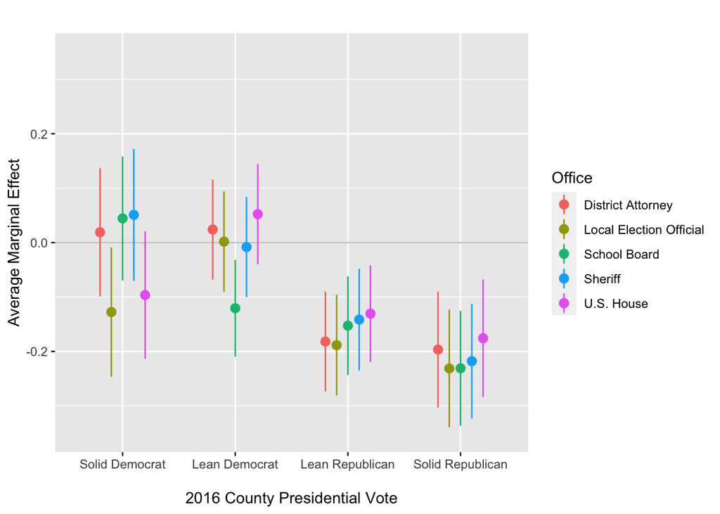

```r
## Subset further to plot only certain factors ##

housebo_gg_SolidD_2 <- subset(housebo_gg_SolidD,
                              factor=="pidRepublican")
housebo_gg_SolidD_2$County = "Solid Democrat"
housebo_gg_SolidD_2$factor <- as.factor(housebo_gg_SolidD_2$factor)
housebo_gg_SolidD_2$var1 <- "Republican"

housebo_gg_LeanD_2 <- subset(housebo_gg_LeanD,
                             factor=="pidRepublican")
housebo_gg_LeanD_2$County = "Lean Democrat"
housebo_gg_LeanD_2$factor <- as.factor(housebo_gg_LeanD_2$factor)
housebo_gg_LeanD_2$var1 <- "Republican"

housebo_gg_LeanR_2 <- subset(housebo_gg_LeanR,
                             factor=="pidRepublican")
housebo_gg_LeanR_2$County = "Lean Republican"
housebo_gg_LeanR_2$factor <- as.factor(housebo_gg_LeanR_2$factor)
housebo_gg_LeanR_2$var1 <- "Republican"

housebo_gg_SolidR_2 <- subset(housebo_gg_SolidR,
                              factor=="pidRepublican")
housebo_gg_SolidR_2$County = "Solid Republican"
housebo_gg_SolidR_2$factor <- as.factor(housebo_gg_SolidR_2$factor)
housebo_gg_SolidR_2$var1 <- "Republican"

bo_gg_house_Combine <- rbind(housebo_gg_SolidD_2, housebo_gg_LeanD_2, housebo_gg_LeanR_2, housebo_gg_SolidR_2)
bo_gg_house_Combine$Office <- "U.S. House"

############## ########### ###########
### Combine Plots ###
pd <- position_dodge(0.5)
bo_gg_Inter_Combine <- rbind(bo_gg_SB_Combine, bo_gg_LEO_Combine,
                             bo_gg_sher_Combine, bo_gg_da_Combine,
                             bo_gg_house_Combine)

ord <- c("Solid Democrat",
         "Lean Democrat",
         "Lean Republican",
         "Solid Republican")

# Correct Order for Plotting
bo_gg_Inter_Combine$County <- factor(bo_gg_Inter_Combine$County,levels=ord)

Inter_Marg_plot <- ggplot(data = bo_gg_Inter_Combine, aes(x = County,
                                                          y = AME, group=Office , ymin = lower, ymax = upper))

Inter_Marg_plot + geom_hline(yintercept = 0, color = "gray80") +
  geom_pointrange(aes(colour = Office), position=pd) +
  ylim(-0.35,0.35)+
  labs(x = "\n2016 County Presidential Vote", y = "Average Marginal Effect", col="Office") +
  ggtitle("")
```

```r
##################################################################

### Figure 5. Intra-party differences in predicted probability of choosing nonpartisan elections. ###

##################################################################

# Democrats #
# Full Model (SB)
glm.sb2.D <- glm(RCO322_np ~
                   perceive_extreme_very.f +
                   polint.f +
                   educ.int.f +
                   birthyr +
                   Pres_Vote.f,
                 family="binomial",
                 data = subset(sbMarginsNP2, pid=="Democrat"))

# Full Model (LEO)
glm.leo2.D <- glm(RCO321_np ~
                    perceive_extreme_very.f +
                    polint.f +
                    educ.int.f +
                    birthyr +
                    Pres_Vote.f,
                  family="binomial",
                  data = subset(leoMarginsNP2, pid=="Democrat"))

# Full Model (SHER)
glm.sher2.D <- glm(RCO323_np ~
                     perceive_extreme_very.f +
                     polint.f +
                     educ.int.f +
                     birthyr +
                     Pres_Vote.f,
                   family="binomial",
                   data = subset(sherMarginsNP2, pid=="Democrat"))

# Full Model (DA)
glm.da2.D <- glm(RCO324_np ~
                   perceive_extreme_very.f +
                   polint.f +
                   educ.int.f +
                   birthyr +
                   Pres_Vote.f,
                 family="binomial",
                 data = subset(daMarginsNP2, pid=="Democrat"))

# Full Model (HOUSE)
glm.house2.D <- glm(RCO327_np ~
                      perceive_extreme_very.f +
                      polint.f +
                      educ.int.f +
                      birthyr +
                      Pres_Vote.f,
                    family="binomial",
                    data = subset(houseMarginsNP2, pid=="Democrat"))

### Plotting ###

# Using margins() we calculate the marginal effects for each variable:

sb2.1_mD <- margins(glm.sb2.D)
leo2.1_mD <- margins(glm.leo2.D)
sher2.1_mD <- margins(glm.sher2.D)
da2.1_mD <- margins(glm.da2.D)
house2.1_mD <- margins(glm.house2.D)


#we can take results from margins() and plot them ourselves.
#To clean up the summary a little a little, we convert it to a tibble,
#then use prefix_strip() and prefix_replace() to tidy the labels.

bo_gg_D_sb <- as_tibble(summary(sb2.1_mD))
bo_gg_D_leo <- as_tibble(summary(leo2.1_mD))
bo_gg_D_sher <- as_tibble(summary(sher2.1_mD))
bo_gg_D_da <- as_tibble(summary(da2.1_mD))
bo_gg_D_house <- as_tibble(summary(house2.1_mD))

bo_gg_D_sb %>% select(factor, AME, lower, upper)
```

```
## # A tibble: 12 x 4
##    factor                           AME    lower     upper
##    <chr>                          <dbl>    <dbl>     <dbl>
##  1 birthyr                     -0.00252 -0.00440 -0.000646
##  2 educ.int.f2                  0.0631  -0.0302   0.156
##  3 educ.int.f3                  0.0568  -0.0604   0.174
##  4 educ.int.f4                  0.0870  -0.00215  0.176
##  5 educ.int.f5                  0.196    0.101    0.291
##  6 perceive_extreme_very.f1     0.0703   0.00809  0.132
##  7 polint.f2                    0.0738  -0.0929   0.241
##  8 polint.f3                    0.168    0.0150   0.320
##  9 polint.f4                    0.318    0.168    0.468
## 10 Pres_Vote.fLean Democrat     0.0246  -0.0532   0.102
## 11 Pres_Vote.fLean Republican   0.0409  -0.0436   0.125
## 12 Pres_Vote.fSolid Republican  0.107    0.00815  0.207
```

```r
bo_gg_D_leo %>% select(factor, AME, lower, upper)
```

```
## # A tibble: 12 x 4
##    factor                            AME    lower   upper
##    <chr>                           <dbl>    <dbl>   <dbl>
##  1 birthyr                     -0.000681 -0.00270 0.00134
##  2 educ.int.f2                  0.0194   -0.0775  0.116
##  3 educ.int.f3                 -0.0454   -0.166   0.0752
##  4 educ.int.f4                 -0.0447   -0.137   0.0477
##  5 educ.int.f5                  0.0541   -0.0467  0.155
##  6 perceive_extreme_very.f1     0.0371   -0.0290  0.103
##  7 polint.f2                    0.190     0.0343  0.346
##  8 polint.f3                    0.203     0.0629  0.342
##  9 polint.f4                    0.272     0.135   0.410
## 10 Pres_Vote.fLean Democrat    -0.0224   -0.105   0.0597
## 11 Pres_Vote.fLean Republican   0.0491   -0.0404  0.139
## 12 Pres_Vote.fSolid Republican  0.0910   -0.0171  0.199
```

```r
bo_gg_D_sher %>% select(factor, AME, lower, upper)
```

```
## # A tibble: 12 x 4
##    factor                           AME    lower    upper
##    <chr>                          <dbl>    <dbl>    <dbl>
##  1 birthyr                     -0.00116 -0.00315 0.000824
##  2 educ.int.f2                 -0.0716  -0.167   0.0239
##  3 educ.int.f3                 -0.00990 -0.129   0.110
##  4 educ.int.f4                 -0.0109  -0.102   0.0800
##  5 educ.int.f5                  0.0301  -0.0694  0.130
##  6 perceive_extreme_very.f1     0.0731   0.00764 0.139
##  7 polint.f2                    0.0980  -0.0637  0.260
##  8 polint.f3                    0.152    0.00508 0.298
##  9 polint.f4                    0.249    0.105   0.394
## 10 Pres_Vote.fLean Democrat     0.0782  -0.00329 0.160
## 11 Pres_Vote.fLean Republican   0.111    0.0222  0.199
## 12 Pres_Vote.fSolid Republican  0.194    0.0893  0.299
```

```r
bo_gg_D_da %>% select(factor, AME, lower, upper)
```

```
## # A tibble: 12 x 4
##    factor                           AME    lower    upper
##    <chr>                          <dbl>    <dbl>    <dbl>
##  1 birthyr                     -0.00299 -0.00493 -0.00105
##  2 educ.int.f2                 -0.0238  -0.120    0.0720
##  3 educ.int.f3                  0.0345  -0.0838   0.153
##  4 educ.int.f4                 -0.0277  -0.119    0.0633
##  5 educ.int.f5                  0.0856  -0.0134   0.185
##  6 perceive_extreme_very.f1     0.0572  -0.00777  0.122
##  7 polint.f2                    0.155    0.00182  0.309
##  8 polint.f3                    0.241    0.103    0.378
##  9 polint.f4                    0.333    0.198    0.468
## 10 Pres_Vote.fLean Democrat    -0.0198  -0.100    0.0605
## 11 Pres_Vote.fLean Republican   0.0263  -0.0610   0.114
## 12 Pres_Vote.fSolid Republican  0.0861  -0.0202   0.192
```

```r
bo_gg_D_house %>% select(factor, AME, lower, upper)
```

```
## # A tibble: 12 x 4
##    factor                            AME    lower   upper
##    <chr>                           <dbl>    <dbl>   <dbl>
##  1 birthyr                     -0.000422 -0.00245 0.00160
##  2 educ.int.f2                  0.0116   -0.0852  0.108
##  3 educ.int.f3                  0.0523   -0.0695  0.174
##  4 educ.int.f4                  0.0237   -0.0688  0.116
##  5 educ.int.f5                 -0.00355  -0.104   0.0966
##  6 perceive_extreme_very.f1    -0.0105   -0.0767  0.0557
##  7 polint.f2                    0.123    -0.0336  0.279
##  8 polint.f3                    0.127    -0.0135  0.268
##  9 polint.f4                    0.129    -0.0100  0.267
## 10 Pres_Vote.fLean Democrat    -0.0250   -0.107   0.0572
## 11 Pres_Vote.fLean Republican  -0.00697  -0.0968  0.0829
## 12 Pres_Vote.fSolid Republican  0.0851   -0.0255  0.196
```

[figure not shown]

```r
ord <- c("birthyr","perceive_extreme_very.f1",
         "educ.int.f2","educ.int.f3","educ.int.f4","educ.int.f5",
         "polint.f2","polint.f3","polint.f4",
         "Pres_Vote.fLean Democrat",
         "Pres_Vote.fLean Republican",
         "Pres_Vote.fSolid Republican")

bo_gg_D_sb$var1 <- as.character(bo_gg_D_sb$factor)
bo_gg_D_sb$var1 <- factor(bo_gg_D_sb$var1,levels=ord)

bo_gg_D_leo$var1 <- as.character(bo_gg_D_leo$factor)
bo_gg_D_leo$var1 <- factor(bo_gg_D_leo$var1,levels=ord)

bo_gg_D_sher$var1 <- as.character(bo_gg_D_sher$factor)
bo_gg_D_sher$var1 <- factor(bo_gg_D_sher$var1,levels=ord)

bo_gg_D_da$var1 <- as.character(bo_gg_D_da$factor)
bo_gg_D_da$var1 <- factor(bo_gg_D_da$var1,levels=ord)

bo_gg_D_house$var1 <- as.character(bo_gg_D_house$factor)
bo_gg_D_house$var1 <- factor(bo_gg_D_house$var1,levels=ord)

# First make a copy
bo_gg_D_sb_2 <- bo_gg_D_sb
bo_gg_D_leo_2 <- bo_gg_D_leo
bo_gg_D_sher_2 <- bo_gg_D_sher
bo_gg_D_da_2 <- bo_gg_D_da
bo_gg_D_house_2 <- bo_gg_D_house

# Copy and paste this complicated code one-by-one
levels(bo_gg_D_sb_2$var1)[levels(bo_gg_D_sb_2$var1)=="birthyr"] <- "Birth Year"
levels(bo_gg_D_sb_2$var1)[levels(bo_gg_D_sb_2$var1)=="perceive_extreme_very.f1"] <- "Outparty is extreme"
levels(bo_gg_D_sb_2$var1)[levels(bo_gg_D_sb_2$var1)=="educ.int.f2"] <- "Some College"
levels(bo_gg_D_sb_2$var1)[levels(bo_gg_D_sb_2$var1)=="educ.int.f3"] <- "2-Year Degree"
levels(bo_gg_D_sb_2$var1)[levels(bo_gg_D_sb_2$var1)=="educ.int.f4"] <- "4-Year Degree"
levels(bo_gg_D_sb_2$var1)[levels(bo_gg_D_sb_2$var1)=="educ.int.f5"] <- "Post-Graduate"
levels(bo_gg_D_sb_2$var1)[levels(bo_gg_D_sb_2$var1)=="polint.f2"] <- "News: Now and then"
levels(bo_gg_D_sb_2$var1)[levels(bo_gg_D_sb_2$var1)=="polint.f3"] <- "News: Some of the time"
levels(bo_gg_D_sb_2$var1)[levels(bo_gg_D_sb_2$var1)=="polint.f4"] <- "News: Most of the time"
levels(bo_gg_D_sb_2$var1)[levels(bo_gg_D_sb_2$var1)=="Pres_Vote.fLean Democrat"] <- "County: Lean Democrat"
levels(bo_gg_D_sb_2$var1)[levels(bo_gg_D_sb_2$var1)=="Pres_Vote.fLean Republican"] <- "County: Lean Republican"
levels(bo_gg_D_sb_2$var1)[levels(bo_gg_D_sb_2$var1)=="Pres_Vote.fSolid Republican"] <- "County: Solid Republican"

# Copy and paste this complicated code one-by-one
levels(bo_gg_D_leo_2$var1)[levels(bo_gg_D_leo_2$var1)=="birthyr"] <- "Birth Year"
levels(bo_gg_D_leo_2$var1)[levels(bo_gg_D_leo_2$var1)=="perceive_extreme_very.f1"] <- "Outparty is extreme"
levels(bo_gg_D_leo_2$var1)[levels(bo_gg_D_leo_2$var1)=="educ.int.f2"] <- "Some College"
levels(bo_gg_D_leo_2$var1)[levels(bo_gg_D_leo_2$var1)=="educ.int.f3"] <- "2-Year Degree"
levels(bo_gg_D_leo_2$var1)[levels(bo_gg_D_leo_2$var1)=="educ.int.f4"] <- "4-Year Degree"
levels(bo_gg_D_leo_2$var1)[levels(bo_gg_D_leo_2$var1)=="educ.int.f5"] <- "Post-Graduate"
levels(bo_gg_D_leo_2$var1)[levels(bo_gg_D_leo_2$var1)=="polint.f2"] <- "News: Now and then"
levels(bo_gg_D_leo_2$var1)[levels(bo_gg_D_leo_2$var1)=="polint.f3"] <- "News: Some of the time"
levels(bo_gg_D_leo_2$var1)[levels(bo_gg_D_leo_2$var1)=="polint.f4"] <- "News: Most of the time"
levels(bo_gg_D_leo_2$var1)[levels(bo_gg_D_leo_2$var1)=="Pres_Vote.fLean Democrat"] <- "County: Lean Democrat"
levels(bo_gg_D_leo_2$var1)[levels(bo_gg_D_leo_2$var1)=="Pres_Vote.fLean Republican"] <- "County: Lean Republican"
levels(bo_gg_D_leo_2$var1)[levels(bo_gg_D_leo_2$var1)=="Pres_Vote.fSolid Republican"] <- "County: Solid Republican"

# Copy and paste this complicated code one-by-one
levels(bo_gg_D_sher_2$var1)[levels(bo_gg_D_sher_2$var1)=="birthyr"] <- "Birth Year"
levels(bo_gg_D_sher_2$var1)[levels(bo_gg_D_sher_2$var1)=="perceive_extreme_very.f1"] <- "Outparty is extreme"
levels(bo_gg_D_sher_2$var1)[levels(bo_gg_D_sher_2$var1)=="educ.int.f2"] <- "Some College"
levels(bo_gg_D_sher_2$var1)[levels(bo_gg_D_sher_2$var1)=="educ.int.f3"] <- "2-Year Degree"
levels(bo_gg_D_sher_2$var1)[levels(bo_gg_D_sher_2$var1)=="educ.int.f4"] <- "4-Year Degree"
levels(bo_gg_D_sher_2$var1)[levels(bo_gg_D_sher_2$var1)=="educ.int.f5"] <- "Post-Graduate"
levels(bo_gg_D_sher_2$var1)[levels(bo_gg_D_sher_2$var1)=="polint.f2"] <- "News: Now and then"
levels(bo_gg_D_sher_2$var1)[levels(bo_gg_D_sher_2$var1)=="polint.f3"] <- "News: Some of the time"
levels(bo_gg_D_sher_2$var1)[levels(bo_gg_D_sher_2$var1)=="polint.f4"] <- "News: Most of the time"
levels(bo_gg_D_sher_2$var1)[levels(bo_gg_D_sher_2$var1)=="Pres_Vote.fLean Democrat"] <- "County: Lean Democrat"
levels(bo_gg_D_sher_2$var1)[levels(bo_gg_D_sher_2$var1)=="Pres_Vote.fLean Republican"] <- "County: Lean Republican"
levels(bo_gg_D_sher_2$var1)[levels(bo_gg_D_sher_2$var1)=="Pres_Vote.fSolid Republican"] <- "County: Solid Republican"

# Copy and paste this complicated code one-by-one
levels(bo_gg_D_da_2$var1)[levels(bo_gg_D_da_2$var1)=="birthyr"] <- "Birth Year"
levels(bo_gg_D_da_2$var1)[levels(bo_gg_D_da_2$var1)=="perceive_extreme_very.f1"] <- "Outparty is extreme"
levels(bo_gg_D_da_2$var1)[levels(bo_gg_D_da_2$var1)=="educ.int.f2"] <- "Some College"
levels(bo_gg_D_da_2$var1)[levels(bo_gg_D_da_2$var1)=="educ.int.f3"] <- "2-Year Degree"
levels(bo_gg_D_da_2$var1)[levels(bo_gg_D_da_2$var1)=="educ.int.f4"] <- "4-Year Degree"
levels(bo_gg_D_da_2$var1)[levels(bo_gg_D_da_2$var1)=="educ.int.f5"] <- "Post-Graduate"
levels(bo_gg_D_da_2$var1)[levels(bo_gg_D_da_2$var1)=="polint.f2"] <- "News: Now and then"
levels(bo_gg_D_da_2$var1)[levels(bo_gg_D_da_2$var1)=="polint.f3"] <- "News: Some of the time"
levels(bo_gg_D_da_2$var1)[levels(bo_gg_D_da_2$var1)=="polint.f4"] <- "News: Most of the time"
levels(bo_gg_D_da_2$var1)[levels(bo_gg_D_da_2$var1)=="Pres_Vote.fLean Democrat"] <- "County: Lean Democrat"
levels(bo_gg_D_da_2$var1)[levels(bo_gg_D_da_2$var1)=="Pres_Vote.fLean Republican"] <- "County: Lean Republican"
levels(bo_gg_D_da_2$var1)[levels(bo_gg_D_da_2$var1)=="Pres_Vote.fSolid Republican"] <- "County: Solid Republican"

# Copy and paste this complicated code one-by-one
levels(bo_gg_D_house_2$var1)[levels(bo_gg_D_house_2$var1)=="birthyr"] <- "Birth Year"
levels(bo_gg_D_house_2$var1)[levels(bo_gg_D_house_2$var1)=="perceive_extreme_very.f1"] <- "Outparty is extreme"
levels(bo_gg_D_house_2$var1)[levels(bo_gg_D_house_2$var1)=="educ.int.f2"] <- "Some College"
levels(bo_gg_D_house_2$var1)[levels(bo_gg_D_house_2$var1)=="educ.int.f3"] <- "2-Year Degree"
levels(bo_gg_D_house_2$var1)[levels(bo_gg_D_house_2$var1)=="educ.int.f4"] <- "4-Year Degree"
levels(bo_gg_D_house_2$var1)[levels(bo_gg_D_house_2$var1)=="educ.int.f5"] <- "Post-Graduate"
levels(bo_gg_D_house_2$var1)[levels(bo_gg_D_house_2$var1)=="polint.f2"] <- "News: Now and then"
levels(bo_gg_D_house_2$var1)[levels(bo_gg_D_house_2$var1)=="polint.f3"] <- "News: Some of the time"
levels(bo_gg_D_house_2$var1)[levels(bo_gg_D_house_2$var1)=="polint.f4"] <- "News: Most of the time"
levels(bo_gg_D_house_2$var1)[levels(bo_gg_D_house_2$var1)=="Pres_Vote.fLean Democrat"] <- "County: Lean Democrat"
levels(bo_gg_D_house_2$var1)[levels(bo_gg_D_house_2$var1)=="Pres_Vote.fLean Republican"] <- "County: Lean Republican"
levels(bo_gg_D_house_2$var1)[levels(bo_gg_D_house_2$var1)=="Pres_Vote.fSolid Republican"] <- "County: Solid Republican"

### Combine Plots ###
pd <- position_dodge(0.3)

## Subset further to plot only certain factors ##

bo_gg_D_sb_3 <- subset(bo_gg_D_sb_2,
                       factor=="perceive_extreme_very.f1" |
                         factor=="educ.int.f5" |
                         factor=="polint.f4" |
                         factor=="Pres_Vote.fSolid Republican")
bo_gg_D_sb_3$pid = "Democrat"
bo_gg_D_sb_3$Office = "School Board"

bo_gg_D_leo_3 <- subset(bo_gg_D_leo_2,
                        factor=="perceive_extreme_very.f1" |
                          factor=="educ.int.f5" |
                          factor=="polint.f4" |
                          factor=="Pres_Vote.fSolid Republican")
bo_gg_D_leo_3$pid = "Democrat"
bo_gg_D_leo_3$Office = "Local Election Official"


bo_gg_D_sher_3 <- subset(bo_gg_D_sher_2,
                         factor=="perceive_extreme_very.f1" |
                           factor=="educ.int.f5" |
                           factor=="polint.f4" |
                           factor=="Pres_Vote.fSolid Republican")
bo_gg_D_sher_3$pid = "Democrat"
bo_gg_D_sher_3$Office = "Sheriff"

bo_gg_D_da_3 <- subset(bo_gg_D_da_2,
                       factor=="perceive_extreme_very.f1" |
                         factor=="educ.int.f5" |
                         factor=="polint.f4" |
                         factor=="Pres_Vote.fSolid Republican")
bo_gg_D_da_3$pid = "Democrat"
bo_gg_D_da_3$Office = "District Attorney"

bo_gg_D_house_3 <- subset(bo_gg_D_house_2,
                          factor=="perceive_extreme_very.f1" |
                            factor=="educ.int.f5" |
                            factor=="polint.f4" |
                            factor=="Pres_Vote.fSolid Republican")
bo_gg_D_house_3$pid = "Democrat"
bo_gg_D_house_3$Office = "U.S. House"


np_Intra_D <- rbind(bo_gg_D_sb_3, bo_gg_D_leo_3, bo_gg_D_sher_3,
                    bo_gg_D_da_3, bo_gg_D_house_3)

#####


np_Intra_D_plot <- ggplot(data = np_Intra_D, aes(x = var1,
                                                 y = AME, group=Office , ymin = lower, ymax = upper))

np_Intra_D_plot
```

```r
np_Intra_D_plot <- np_Intra_D_plot + geom_hline(yintercept = 0, color = "gray80") +
  geom_pointrange(aes(colour = Office), position = pd) +
  coord_flip(ylim = c(-0.5, 0.5)) +
  labs(x = NULL, y = "Average Marginal Effect", col="Office") +
  ggtitle("Among Democrats") +
  scale_x_discrete(labels=c("County: Solid Republican" = "County:\nSolid Republican",
                            "News: Most of the time" = "News:\nMost of the time",
                            "Post-Graduate" = "Education:\nPost-Graduate",
                            "Outparty is extreme" = "Outparty:\nis extreme"))


#### REPUBLICANS ####

# Full Model (SB)
glm.sb2.R <- glm(RCO322_np ~
                   perceive_extreme_very.f +
                   polint.f +
                   educ.int.f +
                   birthyr +
                   Pres_Vote.f,
                 family="binomial",
                 data = subset(sbMarginsNP2, pid=="Republican"))

# Full Model (LEO)
glm.leo2.R <- glm(RCO321_np ~
                    perceive_extreme_very.f +
                    polint.f +
                    educ.int.f +
                    birthyr +
                    Pres_Vote.f,
                  family="binomial",
                  data = subset(leoMarginsNP2, pid=="Republican"))

# Full Model (SHER)
glm.sher2.R <- glm(RCO323_np ~
                     perceive_extreme_very.f +
                     polint.f +
                     educ.int.f +
                     birthyr +
                     Pres_Vote.f,
                   family="binomial",
                   data = subset(sherMarginsNP2, pid=="Republican"))

# Full Model (DA)
glm.da2.R <- glm(RCO324_np ~
                   perceive_extreme_very.f +
                   polint.f +
                   educ.int.f +
                   birthyr +
                   Pres_Vote.f,
                 family="binomial",
                 data = subset(daMarginsNP2, pid=="Republican"))

# Full Model (HOUSE)
glm.house2.R <- glm(RCO327_np ~
                      perceive_extreme_very.f +
                      polint.f +
                      educ.int.f +
                      birthyr +
                      Pres_Vote.f,
                    family="binomial",
                    data = subset(houseMarginsNP2, pid=="Republican"))

### Plotting ###

# Using margins() we calculate the marginal effects for each variable:

sb2.1_mR <- margins(glm.sb2.R)
leo2.1_mR <- margins(glm.leo2.R)
sher2.1_mR <- margins(glm.sher2.R)
da2.1_mR <- margins(glm.da2.R)
house2.1_mR <- margins(glm.house2.R)


#we can take results from margins() and plot them ourselves.
#To clean up the summary a little a little, we convert it to a tibble,
#then use prefix_strip() and prefix_replace() to tidy the labels.

bo_gg_R_sb <- as_tibble(summary(sb2.1_mR))
bo_gg_R_leo <- as_tibble(summary(leo2.1_mR))
bo_gg_R_sher <- as_tibble(summary(sher2.1_mR))
bo_gg_R_da <- as_tibble(summary(da2.1_mR))
bo_gg_R_house <- as_tibble(summary(house2.1_mR))

bo_gg_R_sb %>% select(factor, AME, lower, upper)
```

```
## # A tibble: 12 x 4
##    factor                           AME    lower     upper
##    <chr>                          <dbl>    <dbl>     <dbl>
##  1 birthyr                     -0.00268 -0.00483 -0.000529
##  2 educ.int.f2                  0.0582  -0.0420   0.158
##  3 educ.int.f3                 -0.0231  -0.150    0.104
##  4 educ.int.f4                  0.0667  -0.0362   0.170
##  5 educ.int.f5                 -0.0163  -0.141    0.108
##  6 perceive_extreme_very.f1    -0.0294  -0.104    0.0451
##  7 polint.f2                   -0.0483  -0.290    0.194
##  8 polint.f3                    0.0608  -0.165    0.287
##  9 polint.f4                    0.0908  -0.132    0.313
## 10 Pres_Vote.fLean Democrat    -0.128   -0.250   -0.00521
## 11 Pres_Vote.fLean Republican  -0.147   -0.269   -0.0253
## 12 Pres_Vote.fSolid Republican -0.174   -0.295   -0.0526
```

```r
bo_gg_R_leo %>% select(factor, AME, lower, upper)
```

```
## # A tibble: 12 x 4
##    factor                           AME    lower      upper
##    <chr>                          <dbl>    <dbl>      <dbl>
##  1 birthyr                     -0.00216 -0.00429 -0.0000214
##  2 educ.int.f2                  0.0386  -0.0613   0.138
##  3 educ.int.f3                  0.0578  -0.0689   0.185
##  4 educ.int.f4                  0.0350  -0.0674   0.137
##  5 educ.int.f5                 -0.0818  -0.199    0.0350
##  6 perceive_extreme_very.f1    -0.0125  -0.0859   0.0610
##  7 polint.f2                    0.223    0.0261   0.420
##  8 polint.f3                    0.273    0.0948   0.450
##  9 polint.f4                    0.255    0.0840   0.427
## 10 Pres_Vote.fLean Democrat     0.0965  -0.0284   0.222
## 11 Pres_Vote.fLean Republican  -0.0367  -0.160    0.0864
## 12 Pres_Vote.fSolid Republican -0.0164  -0.139    0.106
```

```r
bo_gg_R_sher %>% select(factor, AME, lower, upper)
```

```
## # A tibble: 12 x 4
##    factor                           AME    lower    upper
##    <chr>                          <dbl>    <dbl>    <dbl>
##  1 birthyr                     -0.00383 -0.00595 -0.00171
##  2 educ.int.f2                 -0.0115  -0.112    0.0888
##  3 educ.int.f3                  0.0618  -0.0655   0.189
##  4 educ.int.f4                  0.0557  -0.0475   0.159
##  5 educ.int.f5                  0.0352  -0.0884   0.159
##  6 perceive_extreme_very.f1    -0.0265  -0.101    0.0480
##  7 polint.f2                    0.151   -0.0867   0.389
##  8 polint.f3                    0.148   -0.0733   0.368
##  9 polint.f4                    0.168   -0.0499   0.385
## 10 Pres_Vote.fLean Democrat     0.0191  -0.106    0.144
## 11 Pres_Vote.fLean Republican  -0.0871  -0.211    0.0370
## 12 Pres_Vote.fSolid Republican -0.0558  -0.179    0.0678
```

```r
bo_gg_R_da %>% select(factor, AME, lower, upper)
```

```
## # A tibble: 12 x 4
##    factor                           AME    lower     upper
##    <chr>                          <dbl>    <dbl>     <dbl>
##  1 birthyr                     -0.00174 -0.00391  0.000439
##  2 educ.int.f2                  0.0292  -0.0715   0.130
##  3 educ.int.f3                  0.0287  -0.0984   0.156
##  4 educ.int.f4                  0.0378  -0.0656   0.141
##  5 educ.int.f5                  0.0596  -0.0652   0.184
##  6 perceive_extreme_very.f1    -0.0233  -0.0980   0.0514
##  7 polint.f2                    0.0815  -0.152    0.315
##  8 polint.f3                    0.126   -0.0907   0.342
##  9 polint.f4                    0.184   -0.0288   0.397
## 10 Pres_Vote.fLean Democrat     0.00143 -0.125    0.128
## 11 Pres_Vote.fLean Republican  -0.133   -0.258   -0.00846
## 12 Pres_Vote.fSolid Republican -0.0821  -0.207    0.0428
```

```r
bo_gg_R_house %>% select(factor, AME, lower, upper)
```

```
## # A tibble: 12 x 4
##    factor                           AME    lower     upper
##    <chr>                          <dbl>    <dbl>     <dbl>
##  1 birthyr                     -0.00217 -0.00421 -0.000129
##  2 educ.int.f2                 -0.0148  -0.113    0.0830
##  3 educ.int.f3                 -0.0220  -0.145    0.101
##  4 educ.int.f4                 -0.0354  -0.135    0.0644
##  5 educ.int.f5                 -0.207   -0.311   -0.103
##  6 perceive_extreme_very.f1    -0.0186  -0.0891   0.0520
##  7 polint.f2                    0.00320 -0.219    0.225
##  8 polint.f3                    0.139   -0.0703   0.348
##  9 polint.f4                    0.0210  -0.184    0.226
## 10 Pres_Vote.fLean Democrat     0.133    0.0107   0.255
## 11 Pres_Vote.fLean Republican  -0.0524  -0.170    0.0654
## 12 Pres_Vote.fSolid Republican -0.00733 -0.126    0.111
```

[figure not shown]

```r
ord <- c("birthyr","perceive_extreme_very.f1",
         "educ.int.f2","educ.int.f3","educ.int.f4","educ.int.f5",
         "polint.f2","polint.f3","polint.f4",
         "Pres_Vote.fLean Democrat",
         "Pres_Vote.fLean Republican",
         "Pres_Vote.fSolid Republican")

bo_gg_R_sb$var1 <- as.character(bo_gg_R_sb$factor)
bo_gg_R_sb$var1 <- factor(bo_gg_R_sb$var1,levels=ord)

bo_gg_R_leo$var1 <- as.character(bo_gg_R_leo$factor)
bo_gg_R_leo$var1 <- factor(bo_gg_R_leo$var1,levels=ord)

bo_gg_R_sher$var1 <- as.character(bo_gg_R_sher$factor)
bo_gg_R_sher$var1 <- factor(bo_gg_R_sher$var1,levels=ord)

bo_gg_R_da$var1 <- as.character(bo_gg_R_da$factor)
bo_gg_R_da$var1 <- factor(bo_gg_R_da$var1,levels=ord)

bo_gg_R_house$var1 <- as.character(bo_gg_R_house$factor)
bo_gg_R_house$var1 <- factor(bo_gg_R_house$var1,levels=ord)

# First make a copy
bo_gg_R_sb_2 <- bo_gg_R_sb
bo_gg_R_leo_2 <- bo_gg_R_leo
bo_gg_R_sher_2 <- bo_gg_R_sher
bo_gg_R_da_2 <- bo_gg_R_da
bo_gg_R_house_2 <- bo_gg_R_house

# Copy and paste this complicated code one-by-one
levels(bo_gg_R_sb_2$var1)[levels(bo_gg_R_sb_2$var1)=="birthyr"] <- "Birth Year"
levels(bo_gg_R_sb_2$var1)[levels(bo_gg_R_sb_2$var1)=="perceive_extreme_very.f1"] <- "Outparty is extreme"
levels(bo_gg_R_sb_2$var1)[levels(bo_gg_R_sb_2$var1)=="educ.int.f2"] <- "Some College"
levels(bo_gg_R_sb_2$var1)[levels(bo_gg_R_sb_2$var1)=="educ.int.f3"] <- "2-Year Degree"
levels(bo_gg_R_sb_2$var1)[levels(bo_gg_R_sb_2$var1)=="educ.int.f4"] <- "4-Year Degree"
levels(bo_gg_R_sb_2$var1)[levels(bo_gg_R_sb_2$var1)=="educ.int.f5"] <- "Post-Graduate"
levels(bo_gg_R_sb_2$var1)[levels(bo_gg_R_sb_2$var1)=="polint.f2"] <- "News: Now and then"
levels(bo_gg_R_sb_2$var1)[levels(bo_gg_R_sb_2$var1)=="polint.f3"] <- "News: Some of the time"
levels(bo_gg_R_sb_2$var1)[levels(bo_gg_R_sb_2$var1)=="polint.f4"] <- "News: Most of the time"
levels(bo_gg_R_sb_2$var1)[levels(bo_gg_R_sb_2$var1)=="Pres_Vote.fLean Democrat"] <- "County: Lean Democrat"
levels(bo_gg_R_sb_2$var1)[levels(bo_gg_R_sb_2$var1)=="Pres_Vote.fLean Republican"] <- "County: Lean Republican"
levels(bo_gg_R_sb_2$var1)[levels(bo_gg_R_sb_2$var1)=="Pres_Vote.fSolid Republican"] <- "County: Solid Republican"

# Copy and paste this complicated code one-by-one
levels(bo_gg_R_leo_2$var1)[levels(bo_gg_R_leo_2$var1)=="birthyr"] <- "Birth Year"
levels(bo_gg_R_leo_2$var1)[levels(bo_gg_R_leo_2$var1)=="perceive_extreme_very.f1"] <- "Outparty is extreme"
levels(bo_gg_R_leo_2$var1)[levels(bo_gg_R_leo_2$var1)=="educ.int.f2"] <- "Some College"
levels(bo_gg_R_leo_2$var1)[levels(bo_gg_R_leo_2$var1)=="educ.int.f3"] <- "2-Year Degree"
levels(bo_gg_R_leo_2$var1)[levels(bo_gg_R_leo_2$var1)=="educ.int.f4"] <- "4-Year Degree"
levels(bo_gg_R_leo_2$var1)[levels(bo_gg_R_leo_2$var1)=="educ.int.f5"] <- "Post-Graduate"
levels(bo_gg_R_leo_2$var1)[levels(bo_gg_R_leo_2$var1)=="polint.f2"] <- "News: Now and then"
levels(bo_gg_R_leo_2$var1)[levels(bo_gg_R_leo_2$var1)=="polint.f3"] <- "News: Some of the time"
levels(bo_gg_R_leo_2$var1)[levels(bo_gg_R_leo_2$var1)=="polint.f4"] <- "News: Most of the time"
levels(bo_gg_R_leo_2$var1)[levels(bo_gg_R_leo_2$var1)=="Pres_Vote.fLean Democrat"] <- "County: Lean Democrat"
levels(bo_gg_R_leo_2$var1)[levels(bo_gg_R_leo_2$var1)=="Pres_Vote.fLean Republican"] <- "County: Lean Republican"
levels(bo_gg_R_leo_2$var1)[levels(bo_gg_R_leo_2$var1)=="Pres_Vote.fSolid Republican"] <- "County: Solid Republican"

# Copy and paste this complicated code one-by-one
levels(bo_gg_R_sher_2$var1)[levels(bo_gg_R_sher_2$var1)=="birthyr"] <- "Birth Year"
levels(bo_gg_R_sher_2$var1)[levels(bo_gg_R_sher_2$var1)=="perceive_extreme_very.f1"] <- "Outparty is extreme"
levels(bo_gg_R_sher_2$var1)[levels(bo_gg_R_sher_2$var1)=="educ.int.f2"] <- "Some College"
levels(bo_gg_R_sher_2$var1)[levels(bo_gg_R_sher_2$var1)=="educ.int.f3"] <- "2-Year Degree"
levels(bo_gg_R_sher_2$var1)[levels(bo_gg_R_sher_2$var1)=="educ.int.f4"] <- "4-Year Degree"
levels(bo_gg_R_sher_2$var1)[levels(bo_gg_R_sher_2$var1)=="educ.int.f5"] <- "Post-Graduate"
levels(bo_gg_R_sher_2$var1)[levels(bo_gg_R_sher_2$var1)=="polint.f2"] <- "News: Now and then"
levels(bo_gg_R_sher_2$var1)[levels(bo_gg_R_sher_2$var1)=="polint.f3"] <- "News: Some of the time"
levels(bo_gg_R_sher_2$var1)[levels(bo_gg_R_sher_2$var1)=="polint.f4"] <- "News: Most of the time"
levels(bo_gg_R_sher_2$var1)[levels(bo_gg_R_sher_2$var1)=="Pres_Vote.fLean Democrat"] <- "County: Lean Democrat"
levels(bo_gg_R_sher_2$var1)[levels(bo_gg_R_sher_2$var1)=="Pres_Vote.fLean Republican"] <- "County: Lean Republican"
levels(bo_gg_R_sher_2$var1)[levels(bo_gg_R_sher_2$var1)=="Pres_Vote.fSolid Republican"] <- "County: Solid Republican"

# Copy and paste this complicated code one-by-one
levels(bo_gg_R_da_2$var1)[levels(bo_gg_R_da_2$var1)=="birthyr"] <- "Birth Year"
levels(bo_gg_R_da_2$var1)[levels(bo_gg_R_da_2$var1)=="perceive_extreme_very.f1"] <- "Outparty is extreme"
levels(bo_gg_R_da_2$var1)[levels(bo_gg_R_da_2$var1)=="educ.int.f2"] <- "Some College"
levels(bo_gg_R_da_2$var1)[levels(bo_gg_R_da_2$var1)=="educ.int.f3"] <- "2-Year Degree"
levels(bo_gg_R_da_2$var1)[levels(bo_gg_R_da_2$var1)=="educ.int.f4"] <- "4-Year Degree"
levels(bo_gg_R_da_2$var1)[levels(bo_gg_R_da_2$var1)=="educ.int.f5"] <- "Post-Graduate"
levels(bo_gg_R_da_2$var1)[levels(bo_gg_R_da_2$var1)=="polint.f2"] <- "News: Now and then"
levels(bo_gg_R_da_2$var1)[levels(bo_gg_R_da_2$var1)=="polint.f3"] <- "News: Some of the time"
levels(bo_gg_R_da_2$var1)[levels(bo_gg_R_da_2$var1)=="polint.f4"] <- "News: Most of the time"
levels(bo_gg_R_da_2$var1)[levels(bo_gg_R_da_2$var1)=="Pres_Vote.fLean Democrat"] <- "County: Lean Democrat"
levels(bo_gg_R_da_2$var1)[levels(bo_gg_R_da_2$var1)=="Pres_Vote.fLean Republican"] <- "County: Lean Republican"
levels(bo_gg_R_da_2$var1)[levels(bo_gg_R_da_2$var1)=="Pres_Vote.fSolid Republican"] <- "County: Solid Republican"

# Copy and paste this complicated code one-by-one
levels(bo_gg_R_house_2$var1)[levels(bo_gg_R_house_2$var1)=="birthyr"] <- "Birth Year"
levels(bo_gg_R_house_2$var1)[levels(bo_gg_R_house_2$var1)=="perceive_extreme_very.f1"] <- "Outparty is extreme"
levels(bo_gg_R_house_2$var1)[levels(bo_gg_R_house_2$var1)=="educ.int.f2"] <- "Some College"
levels(bo_gg_R_house_2$var1)[levels(bo_gg_R_house_2$var1)=="educ.int.f3"] <- "2-Year Degree"
levels(bo_gg_R_house_2$var1)[levels(bo_gg_R_house_2$var1)=="educ.int.f4"] <- "4-Year Degree"
levels(bo_gg_R_house_2$var1)[levels(bo_gg_R_house_2$var1)=="educ.int.f5"] <- "Post-Graduate"
levels(bo_gg_R_house_2$var1)[levels(bo_gg_R_house_2$var1)=="polint.f2"] <- "News: Now and then"
levels(bo_gg_R_house_2$var1)[levels(bo_gg_R_house_2$var1)=="polint.f3"] <- "News: Some of the time"
levels(bo_gg_R_house_2$var1)[levels(bo_gg_R_house_2$var1)=="polint.f4"] <- "News: Most of the time"
levels(bo_gg_R_house_2$var1)[levels(bo_gg_R_house_2$var1)=="Pres_Vote.fLean Democrat"] <- "County: Lean Democrat"
levels(bo_gg_R_house_2$var1)[levels(bo_gg_R_house_2$var1)=="Pres_Vote.fLean Republican"] <- "County: Lean Republican"
levels(bo_gg_R_house_2$var1)[levels(bo_gg_R_house_2$var1)=="Pres_Vote.fSolid Republican"] <- "County: Solid Republican"


### Combine Plots ###
pd <- position_dodge(0.3)

## Subset further to plot only certain factors ##

bo_gg_R_sb_3 <- subset(bo_gg_R_sb_2,
                       factor=="perceive_extreme_very.f1" |
                         factor=="educ.int.f5" |
                         factor=="polint.f4" |
                         factor=="Pres_Vote.fSolid Republican")
bo_gg_R_sb_3$pid = "Republican"
bo_gg_R_sb_3$Office = "School Board"

bo_gg_R_leo_3 <- subset(bo_gg_R_leo_2,
                        factor=="perceive_extreme_very.f1" |
                          factor=="educ.int.f5" |
                          factor=="polint.f4" |
                          factor=="Pres_Vote.fSolid Republican")
bo_gg_R_leo_3$pid = "Republican"
bo_gg_R_leo_3$Office = "Local Election Official"


bo_gg_R_sher_3 <- subset(bo_gg_R_sher_2,
                         factor=="perceive_extreme_very.f1" |
                           factor=="educ.int.f5" |
                           factor=="polint.f4" |
                           factor=="Pres_Vote.fSolid Republican")
bo_gg_R_sher_3$pid = "Republican"
bo_gg_R_sher_3$Office = "Sheriff"

bo_gg_R_da_3 <- subset(bo_gg_R_da_2,
                       factor=="perceive_extreme_very.f1" |
                         factor=="educ.int.f5" |
                         factor=="polint.f4" |
                         factor=="Pres_Vote.fSolid Republican")
bo_gg_R_da_3$pid = "Republican"
bo_gg_R_da_3$Office = "District Attorney"

bo_gg_R_house_3 <- subset(bo_gg_R_house_2,
                          factor=="perceive_extreme_very.f1" |
                            factor=="educ.int.f5" |
                            factor=="polint.f4" |
                            factor=="Pres_Vote.fSolid Republican")
bo_gg_R_house_3$pid = "Republican"
bo_gg_R_house_3$Office = "U.S. House"


np_Intra_R <- rbind(bo_gg_R_sb_3, bo_gg_R_leo_3, bo_gg_R_sher_3,
                    bo_gg_R_da_3, bo_gg_R_house_3)

#####


np_Intra_R_plot <- ggplot(data = np_Intra_R, aes(x = var1,
                                                 y = AME, group=Office , ymin = lower, ymax = upper))

np_Intra_R_plot
```

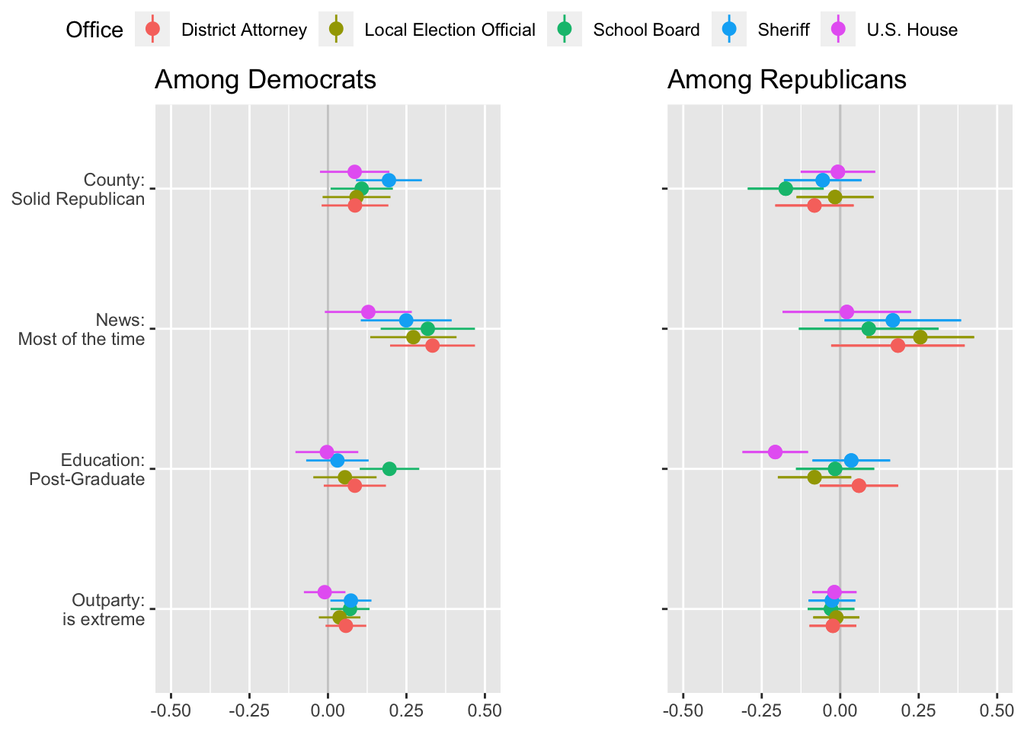

```r
np_Intra_R_plot <- np_Intra_R_plot + geom_hline(yintercept = 0, color = "gray80") +
  geom_pointrange(aes(colour = Office), position = pd) +
  coord_flip(ylim = c(-0.5, 0.5)) +
  labs(x = NULL, y = "Average Marginal Effect", col="Office") +
  ggtitle("") +
  scale_x_discrete(labels=c("County: Solid Republican" = "County:\nSolid Republican",
                            "News: Most of the time" = "News:\nMost of the time",
                            "Post-Graduate" = "Education:\nPost-Graduate",
                            "Outparty is extreme" = "Outparty:\nis extreme"))

#remove labels
np_Intra_R_plot <- np_Intra_R_plot + geom_hline(yintercept = 0, color = "gray80") +
  geom_pointrange(aes(colour = Office), position = pd) +
  coord_flip(ylim = c(-0.5, 0.5)) +
  labs(x = NULL, y = "", col="Office") +
  ggtitle("Among Republicans") +
  scale_x_discrete(labels=c("County: Solid Republican" = "",
                            "News: Most of the time" = "",
                            "Post-Graduate" = "",
                            "Outparty is extreme" = ""))
## Combine D and R

library(grid)
figure <- ggarrange(np_Intra_D_plot + rremove("ylab") + rremove("xlab"),
                    ggplot() + theme_void(),
                    np_Intra_R_plot + rremove("ylab") + rremove("xlab"), # remove axis labels from plots
                    nrow = 1, widths = c(1, 0.001, 1),
                    common.legend = TRUE, legend = "top",
                    align = "hv",
                    font.label = list(size = 10, color = "black", face = "bold", family = NULL, position = "top"))

figure
```

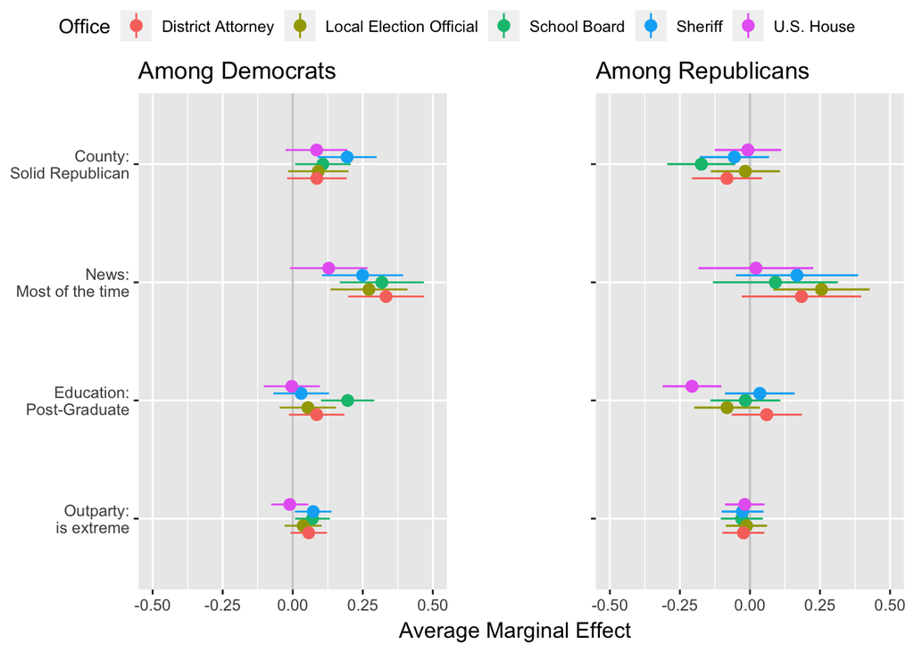

```r
annotate_figure(figure,
                bottom = text_grob("Average Marginal Effect",
                                   color = "black",
                                   hjust = 0.25, vjust = 0, size = 12))
```

```r
#############

########################################################################################################
########################################################################################################
########################################################################################################

#Replication for additional analyses, including online tables and figures#

########################################################################################################
########################################################################################################
########################################################################################################


# ONLINE APPENDIX: Descriptive Statistics, CES Module, 2018/2020 year-by-year comparison
dfs_by_year <- stby(data = desc.stats2,
                    INDICES = desc.stats2$cces.year,
                    FUN = descr, stats = "common", transpose = TRUE)

###### ONLINE APPENDIX - T-TESTS FOR FAMILIARITY BIAS #####

# subsetting observations by states
# with and w/o partisan school boards
states_sb_p <- subset(cces2.2, states_p_sb==1)
states_sb_np <- subset(cces2.2, states_p_sb==0)

#t-test: proportion choosing np school board living in
# PARTISAN school board states vs. proportion choosing
# np school board living in NONPARTISAN school board states
t.test(states_sb_p$RCO322_np,states_sb_np$RCO322_np)
```

```
##
##  Welch Two Sample t-test
##
## data:  states_sb_p$RCO322_np and states_sb_np$RCO322_np
## t = -1.2801, df = 185.22, p-value = 0.2021
## alternative hypothesis: true difference in means is not equal to 0
## 95 percent confidence interval:
##  -0.13914585  0.02963509
## sample estimates:
## mean of x mean of y
## 0.5263158 0.5810712
```

```r
# subsetting observations by states
# with and w/o partisan sheriffs
states_sher_p <- subset(cces2.2, states_p_sheriff==1)
states_sher_np <- subset(cces2.2, states_p_sheriff==0)

#t-test: proportion choosing np sheriff living in
# PARTISAN sheriff states vs. proportion choosing
# np sheriffd living in NONPARTISAN sheriff states
t.test(states_sher_p$RCO323_np,states_sher_np$RCO323_np)
```

```
##
##  Welch Two Sample t-test
##
## data:  states_sher_p$RCO323_np and states_sher_np$RCO323_np
## t = 0.22578, df = 304.64, p-value = 0.8215
## alternative hypothesis: true difference in means is not equal to 0
## 95 percent confidence interval:
##  -0.06334852  0.07976982
## sample estimates:
## mean of x mean of y
## 0.5149371 0.5067265
```

```r
# subsetting observations by states
# with and w/o partisan D.A.
states_da_p <- subset(cces2.2, states_p_da==1)
states_da_np <- subset(cces2.2, states_p_da==0)

#t-test: proportion choosing np d.a. living in
# PARTISAN d.a. states vs. proportion choosing
# np d.a. living in NONPARTISAN d.a. states
t.test(states_da_p$RCO324_np,states_da_np$RCO324_np)
```

```
##
##  Welch Two Sample t-test
##
## data:  states_da_p$RCO324_np and states_da_np$RCO324_np
## t = -0.28396, df = 237.54, p-value = 0.7767
## alternative hypothesis: true difference in means is not equal to 0
## 95 percent confidence interval:
##  -0.08823354  0.06600194
## sample estimates:
## mean of x mean of y
## 0.4996369 0.5107527
```

```r
##### ONLINE APPENDIX: Patterns of Response #####

#choosing PARTISAN for every office
mytable <- table(cces2.2$partydefender)
margin.table(mytable, 1)
```

```
##
##   0   1   2   3   4   5   6   7
## 652 121 226  68 154  98  84 205
```

```r
partydefender <- subset(cces2.2, partydefender==7)
table(partydefender$pid)
```

```
##
##   Democrat Republican
##         94        111
```

```r
#choosing NONPARTISAN for every office
mytable <- table(cces2.2$reformer)
margin.table(mytable, 1)
```

```
##
##   0   1   2   3   4   5   6   7
## 439 125 122 137 122 185 135 343
```

```r
reformer <- subset(cces2.2, reformer==7)
table(reformer$pid)
```

```
##
##   Democrat Republican
##        217        126
```

```r
#choosing NONPARTISAN for every local office
mytable <- table(cces2.2$reformer_local)
margin.table(mytable, 1)
```

```
##
##   0   1   2   3   4   5
## 477 130 143 186 179 504
```

```r
reformer_local <- subset(cces2.2, reformer_local==5)
table(reformer_local$pid)
```

```
##
##   Democrat Republican
##        309        195
```

```r
##### ONLINE APPENDIX: Number of Respondents by County Presidential Vote ####

mytable <- table(cces2.2$pid,
                 cces2.2$Pres_Vote)
mytable
```

```
##
##              Lean Democrat Lean Republican Solid Democrat Solid Republican
##   Democrat             328             238            256              123
##   Republican           190             214             92              216
```

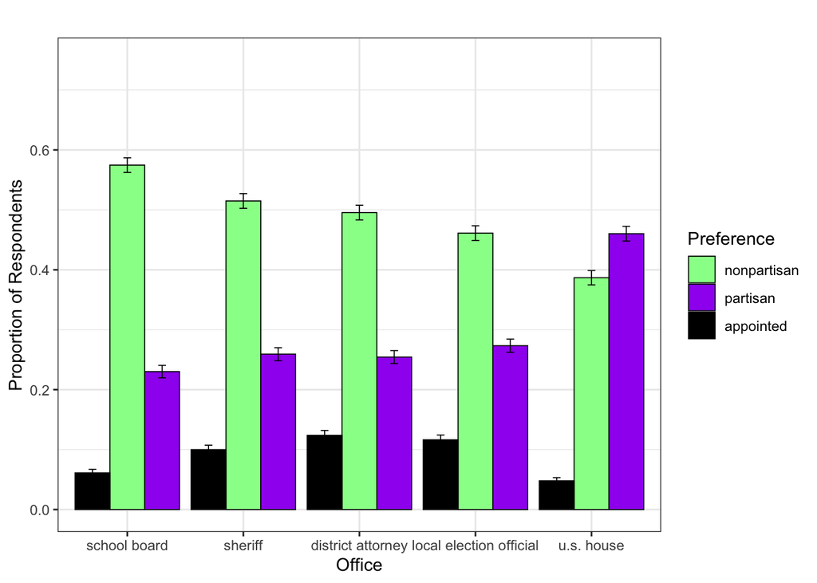

```r
##### ONLINE APPENDIX: Overall preference for local, regardless of party ####

overallSB <- cces2.2
overallSB <- summarySE(cces2.2, measurevar="RCO322_np", na.rm=TRUE)
overallSB$office <- "school board"
overallSB$preference <- "nonpartisan"
overallSB$proportion <- overallSB$RCO322_np
overallSB$RCO322_np <- NULL
overallSB$.id <- NULL

overallSBp <- summarySE(cces2.2, measurevar="RCO322_p", na.rm=TRUE)
overallSBp$office <- "school board"
overallSBp$preference <- "partisan"
overallSBp$proportion <- overallSBp$RCO322_p
overallSBp$RCO322_p <- NULL
overallSBp$.id <- NULL

overallSBa <- cces2.2
overallSBa <- summarySE(cces2.2, measurevar="RCO322_a", na.rm=TRUE)
overallSBa$office <- "school board"
overallSBa$preference <- "appointed"
overallSBa$proportion <- overallSBa$RCO322_a
overallSBa$RCO322_a <- NULL
overallSBa$.id <- NULL

overall <- rbind(overallSB, overallSBp, overallSBa)
###
###

overallleo <- cces2.2
overallleo <- summarySE(cces2.2, measurevar="RCO321_np", na.rm=TRUE)
overallleo$office <- "local election official"
overallleo$preference <- "nonpartisan"
overallleo$proportion <- overallleo$RCO321_np
overallleo$RCO321_np <- NULL
overallleo$.id <- NULL

overallleop <- summarySE(cces2.2, measurevar="RCO321_p", na.rm=TRUE)
overallleop$office <- "local election official"
overallleop$preference <- "partisan"
overallleop$proportion <- overallleop$RCO321_p
overallleop$RCO321_p <- NULL
overallleop$.id <- NULL

overallleoa <- cces2.2
overallleoa <- summarySE(cces2.2, measurevar="RCO321_a", na.rm=TRUE)
overallleoa$office <- "local election official"
overallleoa$preference <- "appointed"
overallleoa$proportion <- overallleoa$RCO321_a
overallleoa$RCO321_a <- NULL
overallleoa$.id <- NULL

overall <- rbind(overall, overallleo, overallleop, overallleoa)
###
###
overallsher <- cces2.2
overallsher <- summarySE(cces2.2, measurevar="RCO323_np", na.rm=TRUE)
overallsher$office <- "sheriff"
overallsher$preference <- "nonpartisan"
overallsher$proportion <- overallsher$RCO323_np
overallsher$RCO323_np <- NULL
overallsher$.id <- NULL

overallsherp <- summarySE(cces2.2, measurevar="RCO323_p", na.rm=TRUE)
overallsherp$office <- "sheriff"
overallsherp$preference <- "partisan"
overallsherp$proportion <- overallsherp$RCO323_p
overallsherp$RCO323_p <- NULL
overallsherp$.id <- NULL

overallshera <- cces2.2
overallshera <- summarySE(cces2.2, measurevar="RCO323_a", na.rm=TRUE)
overallshera$office <- "sheriff"
overallshera$preference <- "appointed"
overallshera$proportion <- overallshera$RCO323_a
overallshera$RCO323_a <- NULL
overallshera$.id <- NULL

overall <- rbind(overall, overallsher, overallsherp, overallshera)
###
###
overallda <- cces2.2
overallda <- summarySE(cces2.2, measurevar="RCO324_np", na.rm=TRUE)
overallda$office <- "district attorney"
overallda$preference <- "nonpartisan"
overallda$proportion <- overallda$RCO324_np
overallda$RCO324_np <- NULL
overallda$.id <- NULL

overalldap <- summarySE(cces2.2, measurevar="RCO324_p", na.rm=TRUE)
overalldap$office <- "district attorney"
overalldap$preference <- "partisan"
overalldap$proportion <- overalldap$RCO324_p
overalldap$RCO324_p <- NULL
overalldap$.id <- NULL

overalldaa <- cces2.2
overalldaa <- summarySE(cces2.2, measurevar="RCO324_a", na.rm=TRUE)
overalldaa$office <- "district attorney"
overalldaa$preference <- "appointed"
overalldaa$proportion <- overalldaa$RCO324_a
overalldaa$RCO324_a <- NULL
overalldaa$.id <- NULL

overall <- rbind(overall, overallda, overalldap, overalldaa)

###
overallhouse <- cces2.2
overallhouse <- summarySE(cces2.2, measurevar="RCO327_np", na.rm=TRUE)
overallhouse$office <- "u.s. house"
overallhouse$preference <- "nonpartisan"
overallhouse$proportion <- overallhouse$RCO327_np
overallhouse$RCO327_np <- NULL
overallhouse$.id <- NULL

overallhousep <- summarySE(cces2.2, measurevar="RCO327_p", na.rm=TRUE)
overallhousep$office <- "u.s. house"
overallhousep$preference <- "partisan"
overallhousep$proportion <- overallhousep$RCO327_p
overallhousep$RCO327_p <- NULL
overallhousep$.id <- NULL

overallhousea <- cces2.2
overallhousea <- summarySE(cces2.2, measurevar="RCO327_a", na.rm=TRUE)
overallhousea$office <- "u.s. house"
overallhousea$preference <- "appointed"
overallhousea$proportion <- overallhousea$RCO327_a
overallhousea$RCO327_a <- NULL
overallhousea$.id <- NULL

overall <- rbind(overall, overallhouse, overallhousep, overallhousea)
##
##
##
overall$office <- ordered(overall$office,
                          levels = c("school board", "sheriff",
                                     "district attorney",
                                     "local election official",
                                     "u.s. house"))

overallPlot <- ggplot(overall, aes(x=office, y=proportion, fill=preference)) +
  scale_fill_manual(values=c("palegreen", "purple", "black"),
                    name="Preference", # Legend label, use darker colors
                    breaks=c("nonpartisan", "partisan", "appointed"),
                    labels=c("nonpartisan", "partisan", "appointed")) +
  geom_bar(position=position_dodge(), stat="identity",
           colour="black", # Use black outlines,
           size=.3) +      # Thinner lines
  geom_errorbar(aes(ymin=proportion-se, ymax=proportion+se),
                size=.3,    # Thinner lines
                width=.2,
                position=position_dodge(.9)) +
  xlab("Office") +
  ylab("Proportion of Respondents") +
  ylim(0,0.75) +
  ggtitle("") +
  theme_bw()

overallPlot
```

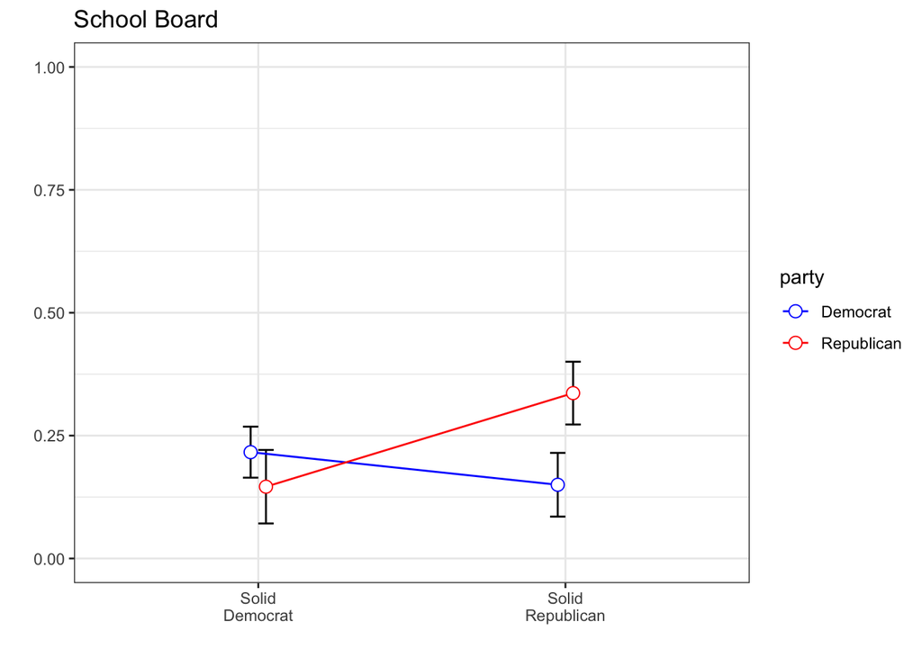

```r
### ONLINE APPENDIX: Inter-party differences, DV=Partisan Election ###

sbContrastP <- cces2.2
sbContrastP <- subset(sbContrastP, c(Pres_Vote == "Solid Democrat" | Pres_Vote == "Solid Republican"))

sbContrastP$pid <- factor(sbContrastP$pid)
sbContrastPD <- subset(sbContrastP, pid=="Democrat")
sbContrastPR <- subset(sbContrastP, pid=="Republican")

sbContrastPD <- summarySE(sbContrastPD, measurevar="RCO322_p", groupvars=c("Pres_Vote"), na.rm=TRUE)
sbContrastPD$office <- "school board"
sbContrastPD$party <- "Democrat"
sbContrastPD$proportion <- sbContrastPD$RCO322_p
sbContrastPD$RCO322_p <- NULL


sbContrastPR <- summarySE(sbContrastPR, measurevar="RCO322_p", groupvars=c("Pres_Vote"), na.rm=TRUE)
sbContrastPR$office <- "school board"
sbContrastPR$party <- "Republican"
sbContrastPR$proportion <- sbContrastPR$RCO322_p
sbContrastPR$RCO322_p <- NULL

sbContrastPDR <- rbind(sbContrastPD, sbContrastPR)
sbContrastPDR$Pres_Vote <- ordered(sbContrastPDR$Pres_Vote,
                                   levels = c("Solid Democrat", "Solid Republican"))

pd <- position_dodge(0.1)
sbCDP <- ggplot(sbContrastPDR, aes(x=Pres_Vote, y=proportion, colour=party, group=party, legend="right")) +
  geom_errorbar(aes(ymin=proportion-ci, ymax=proportion+ci), colour="black", width=.1, position=pd) +
  geom_line(position=pd) +
  geom_point(position=pd, size=3, shape=21, fill="white") + # 21 is filled circle
  xlab("") +
  ylab("") +
  scale_color_manual(values=c("Democrat" = "blue",
                              "Republican" = "red")) +
  scale_x_discrete(breaks=c("Solid Democrat", "Solid Republican"),
                   labels=c("Solid\nDemocrat", "Solid\nRepublican")) +
  ggtitle("School Board") +
  ylim(0,1) +
  theme_bw()


sbCDP
```

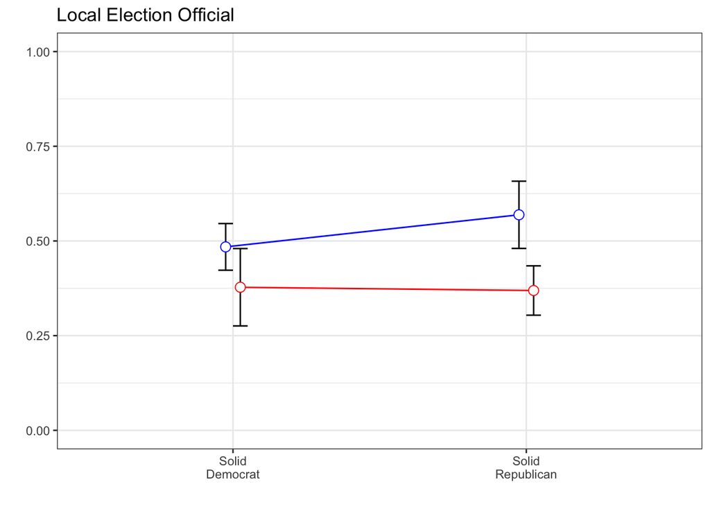

```r
## partisan diffs in local election opinion
leoContrastP <- cces2.2
leoContrastP <- subset(leoContrastP, c(Pres_Vote == "Solid Democrat" | Pres_Vote == "Solid Republican"))

leoContrastP$pid <- factor(leoContrastP$pid)
leoContrastPD <- subset(leoContrastP, pid=="Democrat")
leoContrastPR <- subset(leoContrastP, pid=="Republican")

leoContrastPD <- summarySE(leoContrastPD, measurevar="RCO321_p", groupvars=c("Pres_Vote"), na.rm=TRUE)
leoContrastPD$office <- "local election official"
leoContrastPD$party <- "Democrat"
leoContrastPD$proportion <- leoContrastPD$RCO321_p
leoContrastPD$RCO321_p <- NULL


leoContrastPR <- summarySE(leoContrastPR, measurevar="RCO321_p", groupvars=c("Pres_Vote"), na.rm=TRUE)
leoContrastPR$office <- "local election official"
leoContrastPR$party <- "Republican"
leoContrastPR$proportion <- leoContrastPR$RCO321_p
leoContrastPR$RCO321_p <- NULL

leoContrastPDR <- rbind(leoContrastPD, leoContrastPR)
leoContrastPDR$Pres_Vote <- ordered(leoContrastPDR$Pres_Vote,
                                    levels = c("Solid Democrat", "Solid Republican"))

pd <- position_dodge(0.1)
leoCDP <- ggplot(leoContrastPDR, aes(x=Pres_Vote, y=proportion, colour=party, group=party, legend="right")) +
  geom_errorbar(aes(ymin=proportion-ci, ymax=proportion+ci), colour="black", width=.1, position=pd) +
  geom_line(position=pd) +
  geom_point(position=pd, size=3, shape=21, fill="white") +
  xlab("") +
  ylab("") +
  scale_color_manual(values=c("Democrat" = "blue",
                              "Republican" = "red")) +
  scale_x_discrete(breaks=c("Solid Democrat", "Solid Republican"),
                   labels=c("Solid\nDemocrat", "Solid\nRepublican")) +
  ggtitle("Local Election Official") +
  ylim(0,1) +
  theme_bw()

leoCD
```

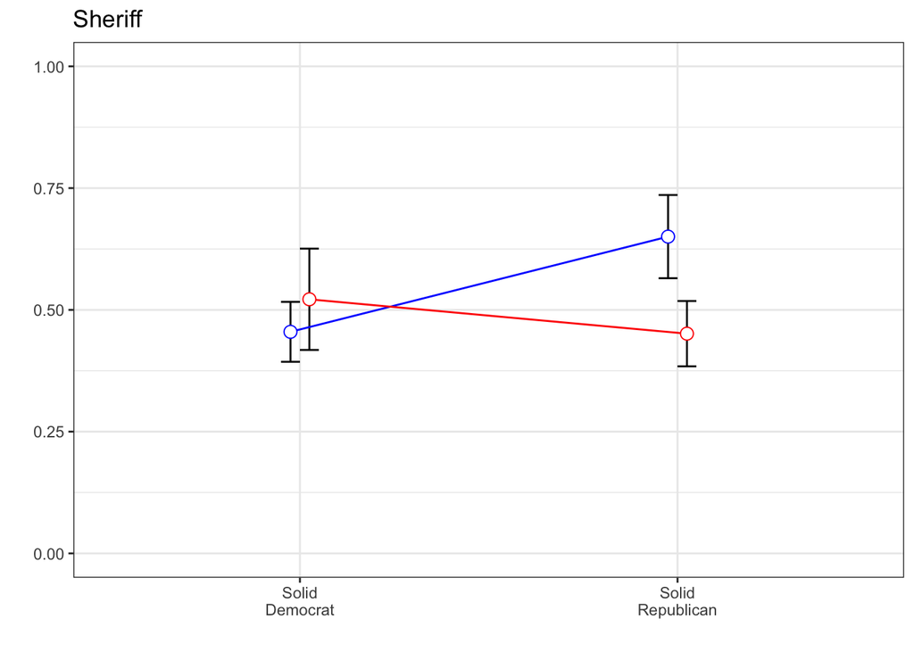

```r
## partisan diffs in local election opinion
sherContrastP <- cces2.2
sherContrastP <- subset(sherContrastP, c(Pres_Vote == "Solid Democrat" | Pres_Vote == "Solid Republican"))

sherContrastP$pid <- factor(sherContrastP$pid)
sherContrastPD <- subset(sherContrastP, pid=="Democrat")
sherContrastPR <- subset(sherContrastP, pid=="Republican")

sherContrastPD <- summarySE(sherContrastPD, measurevar="RCO323_p", groupvars=c("Pres_Vote"), na.rm=TRUE)
sherContrastPD$office <- "sheriff"
sherContrastPD$party <- "Democrat"
sherContrastPD$proportion <- sherContrastPD$RCO323_p
sherContrastPD$RCO323_p <- NULL


sherContrastPR <- summarySE(sherContrastPR, measurevar="RCO323_p", groupvars=c("Pres_Vote"), na.rm=TRUE)
sherContrastPR$office <- "sheriff"
sherContrastPR$party <- "Republican"
sherContrastPR$proportion <- sherContrastPR$RCO323_p
sherContrastPR$RCO323_p <- NULL

sherContrastPDR <- rbind(sherContrastPD, sherContrastPR)
sherContrastPDR$Pres_Vote <- ordered(sherContrastPDR$Pres_Vote,
                                     levels = c("Solid Democrat", "Solid Republican"))

pd <- position_dodge(0.1)
sherCDP <- ggplot(sherContrastPDR, aes(x=Pres_Vote, y=proportion, colour=party, group=party, legend="right")) +
  geom_errorbar(aes(ymin=proportion-ci, ymax=proportion+ci), colour="black", width=.1, position=pd) +
  geom_line(position=pd) +
  geom_point(position=pd, size=3, shape=21, fill="white") +
  xlab("") +
  ylab("") +
  scale_color_manual(values=c("Democrat" = "blue",
                              "Republican" = "red")) +
  scale_x_discrete(breaks=c("Solid Democrat", "Solid Republican"),
                   labels=c("Solid\nDemocrat", "Solid\nRepublican")) +
  ggtitle("Sheriff") +
  ylim(0,1) +
  theme_bw()

sherCD
```

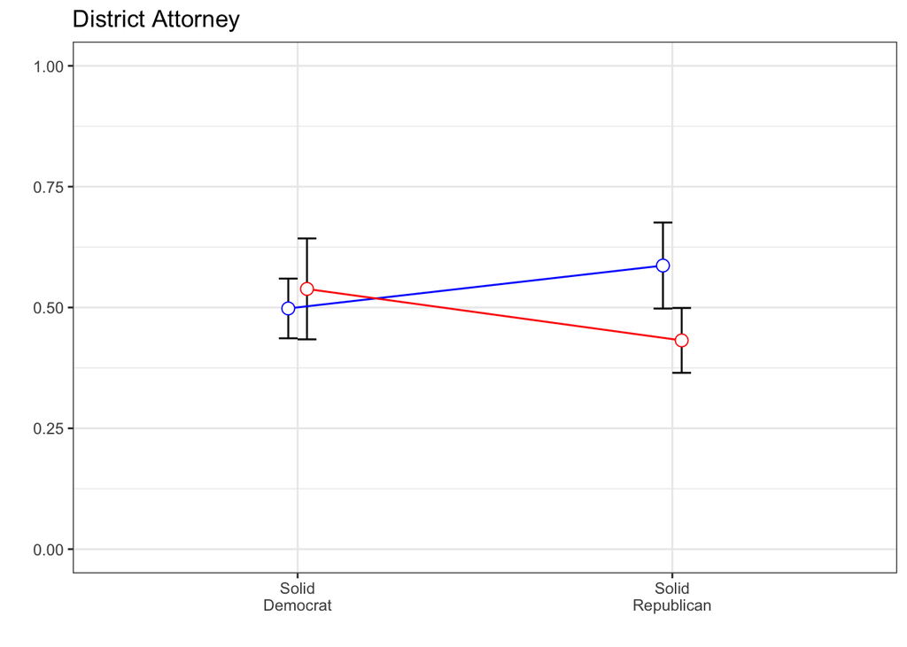

```r
## partisan diffs in local election opinion
daContrastP <- cces2.2
daContrastP <- subset(daContrastP, c(Pres_Vote == "Solid Democrat" | Pres_Vote == "Solid Republican"))

daContrastP$pid <- factor(daContrastP$pid)
daContrastPD <- subset(daContrastP, pid=="Democrat")
daContrastPR <- subset(daContrastP, pid=="Republican")

daContrastPD <- summarySE(daContrastPD, measurevar="RCO324_p", groupvars=c("Pres_Vote"), na.rm=TRUE)
daContrastPD$office <- "d.a."
daContrastPD$party <- "Democrat"
daContrastPD$proportion <- daContrastPD$RCO324_p
daContrastPD$RCO324_p <- NULL


daContrastPR <- summarySE(daContrastPR, measurevar="RCO324_p", groupvars=c("Pres_Vote"), na.rm=TRUE)
daContrastPR$office <- "d.a."
daContrastPR$party <- "Republican"
daContrastPR$proportion <- daContrastPR$RCO324_p
daContrastPR$RCO324_p <- NULL

daContrastPDR <- rbind(daContrastPD, daContrastPR)
daContrastPDR$Pres_Vote <- ordered(daContrastDR$Pres_Vote,
                                   levels = c("Solid Democrat", "Solid Republican"))

pd <- position_dodge(0.1)
daCDP <- ggplot(daContrastPDR, aes(x=Pres_Vote, y=proportion, colour=party, group=party, legend="right")) +
  geom_errorbar(aes(ymin=proportion-ci, ymax=proportion+ci), colour="black", width=.1, position=pd) +
  geom_line(position=pd) +
  geom_point(position=pd, size=3, shape=21, fill="white") +
  xlab("") +
  ylab("") +
  scale_color_manual(values=c("Democrat" = "blue",
                              "Republican" = "red")) +
  scale_x_discrete(breaks=c("Solid Democrat", "Solid Republican"),
                   labels=c("Solid\nDemocrat", "Solid\nRepublican")) +
  ggtitle("District Attorney") +
  ylim(0,1) +
  theme_bw()

daCD
```

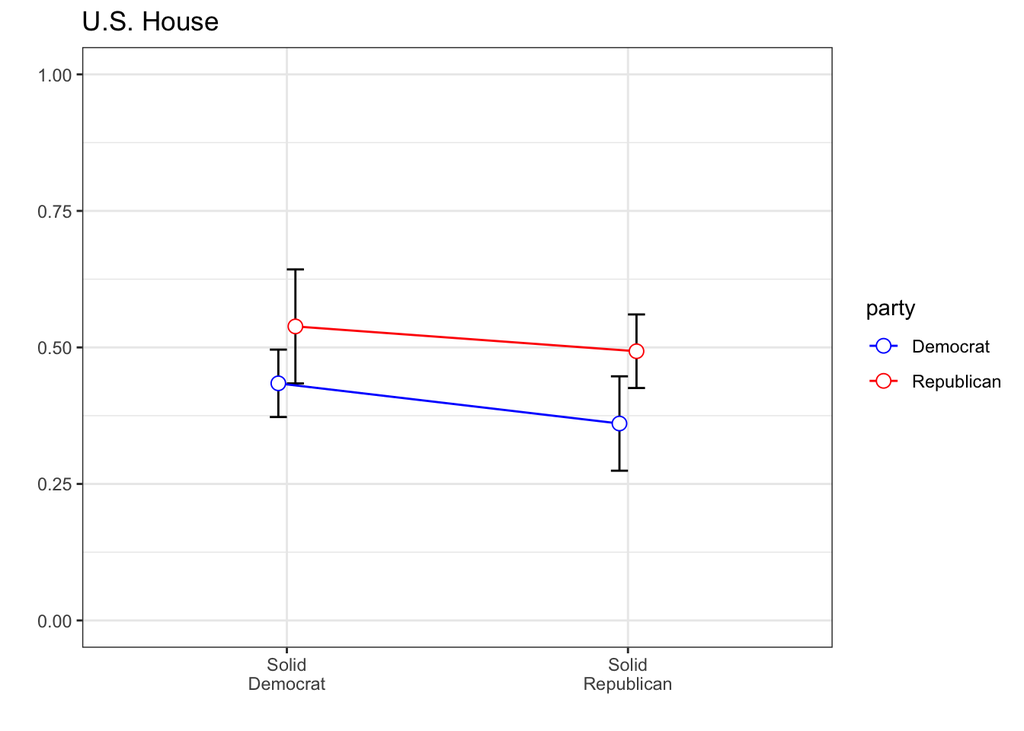

```r
####
houseContrastP <- cces2.2
houseContrastP <- subset(houseContrastP, c(Pres_Vote == "Solid Democrat" | Pres_Vote == "Solid Republican"))

houseContrastP$pid <- factor(houseContrastP$pid)
houseContrastPD <- subset(houseContrastP, pid=="Democrat")
houseContrastPR <- subset(houseContrastP, pid=="Republican")

houseContrastPD <- summarySE(houseContrastPD, measurevar="RCO327_p", groupvars=c("Pres_Vote"), na.rm=TRUE)
houseContrastPD$office <- "u.s. house"
houseContrastPD$party <- "Democrat"
houseContrastPD$proportion <- houseContrastPD$RCO327_p
houseContrastPD$RCO327_p <- NULL


houseContrastPR <- summarySE(houseContrastPR, measurevar="RCO327_p", groupvars=c("Pres_Vote"), na.rm=TRUE)
houseContrastPR$office <- "u.s. house"
houseContrastPR$party <- "Republican"
houseContrastPR$proportion <- houseContrastPR$RCO327_p
houseContrastPR$RCO327_p <- NULL

houseContrastPDR <- rbind(houseContrastPD, houseContrastPR)
houseContrastPDR$Pres_Vote <- ordered(houseContrastPDR$Pres_Vote,
                                      levels = c("Solid Democrat", "Solid Republican"))

pd <- position_dodge(0.1)
houseCDP <- ggplot(houseContrastPDR, aes(x=Pres_Vote, y=proportion, colour=party, group=party, legend="right")) +
  geom_errorbar(aes(ymin=proportion-ci, ymax=proportion+ci), colour="black", width=.1, position=pd) +
  geom_line(position=pd) +
  geom_point(position=pd, size=3, shape=21, fill="white") +
  xlab("") +
  ylab("") +
  scale_color_manual(values=c("Democrat" = "blue",
                              "Republican" = "red")) +
  scale_x_discrete(breaks=c("Solid Democrat", "Solid Republican"),
                   labels=c("Solid\nDemocrat", "Solid\nRepublican")) +
  ggtitle("U.S. House") +
  ylim(0,1) +
  theme_bw()

houseCDP
```

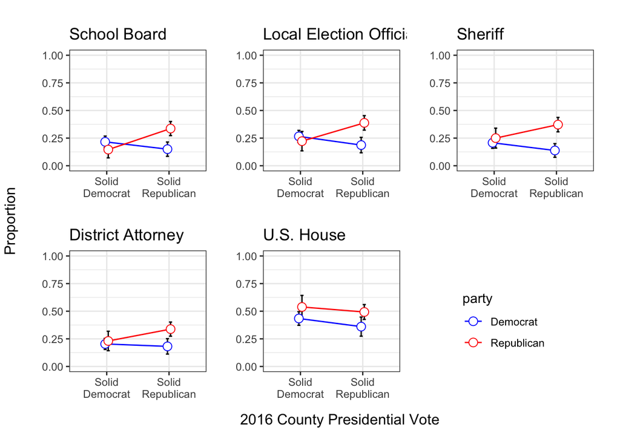

```r
####

###### Multiplot for Nonpartisan #####

#extract legend from houseCD (could be any b/c all same legend)
legP <- get_legend(houseCDP)

#save earlier plots but remove their legends
sbCDP <- sbCDP + theme(legend.position = "none")
leoCDP <- leoCDP + theme(legend.position = "none")
sherCDP <- sherCDP + theme(legend.position = "none")
daCDP <- daCDP + theme(legend.position = "none")
houseCDP <- houseCDP + theme(legend.position = "none")

#arrange plots, and now the extracted legend is a defacto plot (for positioning)
multi_npContrastP <- ggarrange(sbCDP, leoCDP, sherCDP,  daCDP, houseCDP, legP,
                               ncol = 3, nrow = 2,
                               font.label=list(color="black",size=10))

annotate_figure(multi_npContrastP,
                top = text_grob("",
                                color = "black", face = "bold", size = 14),
                bottom = text_grob("2016 County Presidential Vote",
                                   color = "black",
                                   hjust = 0.35, vjust = -0.75, size = 12),
                left = text_grob("Proportion", color = "black", rot = 90),
                right = "",
                fig.lab = "", fig.lab.face = "bold"
)
```

```r
#######################################################################################

### ONLINE APPENDIX: ANOVA, Chi-Square tests to see if pid*Pres_Vote is significant  ###

#######################################################################################

sbNP.interact <- glm(RCO322_np ~
                       pid*Pres_Vote.f +
                       perceive_extreme_very.f +
                       polint.f +
                       educ.int.f +
                       birthyr,
                     family="binomial",
                     data = subset(sbGLM))

summary(sbNP.interact)
```

```
##
## Call:
## glm(formula = RCO322_np ~ pid * Pres_Vote.f + perceive_extreme_very.f +
##     polint.f + educ.int.f + birthyr, family = "binomial", data = subset(sbGLM))
##
## Deviance Residuals:
##     Min       1Q   Median       3Q      Max
## -1.8968  -1.1814   0.7582   0.9998   1.7380
##
## Coefficients:
##                                             Estimate Std. Error z value
## (Intercept)                                21.139031   6.470744   3.267
## pidRepublican                               0.128712   0.270907   0.475
## Pres_Vote.fLean Democrat                    0.076771   0.181295   0.423
## Pres_Vote.fLean Republican                  0.162092   0.197721   0.820
## Pres_Vote.fSolid Republican                 0.467710   0.249279   1.876
## perceive_extreme_very.fOutparty is extreme  0.135262   0.108461   1.247
## polint.fNews: Now and then                  0.214337   0.297197   0.721
## polint.fNews: Some of the time              0.632512   0.274144   2.307
## polint.fNews: Most of the time              1.080538   0.271159   3.985
## educ.int.fSome College                      0.261938   0.150894   1.736
## educ.int.f2-Year Degree                     0.102957   0.189569   0.543
## educ.int.f4-Year Degree                     0.340224   0.149075   2.282
## educ.int.fPost-Graduate                     0.532422   0.174447   3.052
## birthyr                                    -0.011066   0.003264  -3.391
## pidRepublican:Pres_Vote.fLean Democrat     -0.577880   0.331331  -1.744
## pidRepublican:Pres_Vote.fLean Republican   -0.785235   0.336506  -2.333
## pidRepublican:Pres_Vote.fSolid Republican  -1.147354   0.368529  -3.113
##                                            Pr(>|z|)
## (Intercept)                                0.001087 **
## pidRepublican                              0.634705
## Pres_Vote.fLean Democrat                   0.671958
## Pres_Vote.fLean Republican                 0.412330
## Pres_Vote.fSolid Republican                0.060620 .
## perceive_extreme_very.fOutparty is extreme 0.212361
## polint.fNews: Now and then                 0.470789
## polint.fNews: Some of the time             0.021042 *
## polint.fNews: Most of the time             6.75e-05 ***
## educ.int.fSome College                     0.082580 .
## educ.int.f2-Year Degree                    0.587052
## educ.int.f4-Year Degree                    0.022476 *
## educ.int.fPost-Graduate                    0.002273 **
## birthyr                                    0.000697 ***
## pidRepublican:Pres_Vote.fLean Democrat     0.081139 .
## pidRepublican:Pres_Vote.fLean Republican   0.019622 *
## pidRepublican:Pres_Vote.fSolid Republican  0.001850 **
## ---
## Signif. codes:  0 '***' 0.001 '**' 0.01 '*' 0.05 '.' 0.1 ' ' 1
##
## (Dispersion parameter for binomial family taken to be 1)
##
##     Null deviance: 2189.3  on 1608  degrees of freedom
## Residual deviance: 2061.6  on 1592  degrees of freedom
##   (48 observations deleted due to missingness)
## AIC: 2095.6
##
## Number of Fisher Scoring iterations: 4
```

```r
#anova shows interaction is significant
anova(sbNP.interact, test="Chisq")
```

```
## Analysis of Deviance Table
##
## Model: binomial, link: logit
##
## Response: RCO322_np
##
## Terms added sequentially (first to last)
##
##
##                         Df Deviance Resid. Df Resid. Dev  Pr(>Chi)
## NULL                                     1608     2189.3
## pid                      1   15.458      1607     2173.9 8.435e-05 ***
## Pres_Vote.f              3    0.484      1604     2173.4 0.9224317
## perceive_extreme_very.f  1    7.952      1603     2165.4 0.0048039 **
## polint.f                 3   71.413      1600     2094.0 2.127e-15 ***
## educ.int.f               4    9.819      1596     2084.2 0.0435829 *
## birthyr                  1   12.037      1595     2072.2 0.0005216 ***
## pid:Pres_Vote.f          3   10.562      1592     2061.6 0.0143471 *
## ---
## Signif. codes:  0 '***' 0.001 '**' 0.01 '*' 0.05 '.' 0.1 ' ' 1
```

```r
sbNP.baseline <- glm(RCO322_np ~
                       pid + Pres_Vote.f +
                       perceive_extreme_very.f +
                       polint.f +
                       educ.int.f +
                       birthyr,
                     family="binomial",
                     data = subset(sbGLM))

summary(sbNP.baseline)
```

```
##
## Call:
## glm(formula = RCO322_np ~ pid + Pres_Vote.f + perceive_extreme_very.f +
##     polint.f + educ.int.f + birthyr, family = "binomial", data = subset(sbGLM))
##
## Deviance Residuals:
##     Min       1Q   Median       3Q      Max
## -1.8066  -1.1953   0.7750   0.9986   1.7082
##
## Coefficients:
##                                             Estimate Std. Error z value
## (Intercept)                                21.646611   6.441483   3.361
## pidRepublican                              -0.526846   0.112555  -4.681
## Pres_Vote.fLean Democrat                   -0.067746   0.151609  -0.447
## Pres_Vote.fLean Republican                 -0.075820   0.159065  -0.477
## Pres_Vote.fSolid Republican                -0.035191   0.172032  -0.205
## perceive_extreme_very.fOutparty is extreme  0.121564   0.107917   1.126
## polint.fNews: Now and then                  0.206102   0.296015   0.696
## polint.fNews: Some of the time              0.619672   0.272709   2.272
## polint.fNews: Most of the time              1.078880   0.269919   3.997
## educ.int.fSome College                      0.260301   0.149972   1.736
## educ.int.f2-Year Degree                     0.111519   0.188443   0.592
## educ.int.f4-Year Degree                     0.344906   0.148417   2.324
## educ.int.fPost-Graduate                     0.521717   0.173460   3.008
## birthyr                                    -0.011230   0.003249  -3.456
##                                            Pr(>|z|)
## (Intercept)                                0.000778 ***
## pidRepublican                              2.86e-06 ***
## Pres_Vote.fLean Democrat                   0.654988
## Pres_Vote.fLean Republican                 0.633605
## Pres_Vote.fSolid Republican                0.837915
## perceive_extreme_very.fOutparty is extreme 0.259970
## polint.fNews: Now and then                 0.486269
## polint.fNews: Some of the time             0.023070 *
## polint.fNews: Most of the time             6.41e-05 ***
## educ.int.fSome College                     0.082623 .
## educ.int.f2-Year Degree                    0.553990
## educ.int.f4-Year Degree                    0.020131 *
## educ.int.fPost-Graduate                    0.002632 **
## birthyr                                    0.000548 ***
## ---
## Signif. codes:  0 '***' 0.001 '**' 0.01 '*' 0.05 '.' 0.1 ' ' 1
##
## (Dispersion parameter for binomial family taken to be 1)
##
##     Null deviance: 2189.3  on 1608  degrees of freedom
## Residual deviance: 2072.2  on 1595  degrees of freedom
##   (48 observations deleted due to missingness)
## AIC: 2100.2
##
## Number of Fisher Scoring iterations: 4
```

```r
# Compare Nonpartisan SB models, with and w/o interaction
anova(sbNP.baseline, sbNP.interact, test="Chisq")
```

```
## Analysis of Deviance Table
##
## Model 1: RCO322_np ~ pid + Pres_Vote.f + perceive_extreme_very.f + polint.f +
##     educ.int.f + birthyr
## Model 2: RCO322_np ~ pid * Pres_Vote.f + perceive_extreme_very.f + polint.f +
##     educ.int.f + birthyr
##   Resid. Df Resid. Dev Df Deviance Pr(>Chi)
## 1      1595     2072.2
## 2      1592     2061.6  3   10.562  0.01435 *
## ---
## Signif. codes:  0 '***' 0.001 '**' 0.01 '*' 0.05 '.' 0.1 ' ' 1
```

```r
leoNP.interact <- glm(RCO321_np ~
                        pid*Pres_Vote.f +
                        perceive_extreme_very.f +
                        polint.f +
                        educ.int.f +
                        birthyr,
                      family="binomial",
                      data = subset(leoGLM))

#anova shows interaction is significant
anova(leoNP.interact, test="Chisq")
```

```
## Analysis of Deviance Table
##
## Model: binomial, link: logit
##
## Response: RCO321_np
##
## Terms added sequentially (first to last)
##
##
##                         Df Deviance Resid. Df Resid. Dev  Pr(>Chi)
## NULL                                     1623     2244.2
## pid                      1  16.9863      1622     2227.2 3.765e-05 ***
## Pres_Vote.f              3   0.8689      1619     2226.3  0.832926
## perceive_extreme_very.f  1   1.5397      1618     2224.8  0.214658
## polint.f                 3  23.3269      1615     2201.4 3.452e-05 ***
## educ.int.f               4   1.1412      1611     2200.3  0.887675
## birthyr                  1   4.0362      1610     2196.3  0.044534 *
## pid:Pres_Vote.f          3  13.8176      1607     2182.4  0.003164 **
## ---
## Signif. codes:  0 '***' 0.001 '**' 0.01 '*' 0.05 '.' 0.1 ' ' 1
```

```r
leoNP.baseline <- glm(RCO321_np ~
                        pid + Pres_Vote.f +
                        perceive_extreme_very.f +
                        polint.f +
                        educ.int.f +
                        birthyr,
                      family="binomial",
                      data = subset(leoGLM))

# Compare Nonpartisan LEO models, with and w/o interaction
anova(leoNP.baseline, leoNP.interact, test="Chisq")
```

```
## Analysis of Deviance Table
##
## Model 1: RCO321_np ~ pid + Pres_Vote.f + perceive_extreme_very.f + polint.f +
##     educ.int.f + birthyr
## Model 2: RCO321_np ~ pid * Pres_Vote.f + perceive_extreme_very.f + polint.f +
##     educ.int.f + birthyr
##   Resid. Df Resid. Dev Df Deviance Pr(>Chi)
## 1      1610     2196.3
## 2      1607     2182.4  3   13.818 0.003164 **
## ---
## Signif. codes:  0 '***' 0.001 '**' 0.01 '*' 0.05 '.' 0.1 ' ' 1
```

```r
daNP.interact <- glm(RCO324_np ~
                       pid*Pres_Vote.f +
                       perceive_extreme_very.f +
                       polint.f +
                       educ.int.f +
                       birthyr,
                     family="binomial",
                     data = subset(daGLM))

anova(daNP.interact, test="Chisq")
```

```
## Analysis of Deviance Table
##
## Model: binomial, link: logit
##
## Response: RCO324_np
##
## Terms added sequentially (first to last)
##
##
##                         Df Deviance Resid. Df Resid. Dev  Pr(>Chi)
## NULL                                     1620     2247.2
## pid                      1    4.973      1619     2242.2 0.0257474 *
## Pres_Vote.f              3    0.503      1616     2241.7 0.9182933
## perceive_extreme_very.f  1    4.256      1615     2237.4 0.0391233 *
## polint.f                 3   51.322      1612     2186.1 4.176e-11 ***
## educ.int.f               4    6.403      1608     2179.7 0.1709911
## birthyr                  1   10.922      1607     2168.8 0.0009505 ***
## pid:Pres_Vote.f          3   14.253      1604     2154.6 0.0025805 **
## ---
## Signif. codes:  0 '***' 0.001 '**' 0.01 '*' 0.05 '.' 0.1 ' ' 1
```

```r
daNP.baseline <- glm(RCO324_np ~
                       pid + Pres_Vote.f +
                       perceive_extreme_very.f +
                       polint.f +
                       educ.int.f +
                       birthyr,
                     family="binomial",
                     data = subset(daGLM))

# Compare Nonpartisan DA models, with and w/o interaction
anova(daNP.baseline, daNP.interact, test="Chisq")
```

```
## Analysis of Deviance Table
##
## Model 1: RCO324_np ~ pid + Pres_Vote.f + perceive_extreme_very.f + polint.f +
##     educ.int.f + birthyr
## Model 2: RCO324_np ~ pid * Pres_Vote.f + perceive_extreme_very.f + polint.f +
##     educ.int.f + birthyr
##   Resid. Df Resid. Dev Df Deviance Pr(>Chi)
## 1      1607     2168.8
## 2      1604     2154.6  3   14.253  0.00258 **
## ---
## Signif. codes:  0 '***' 0.001 '**' 0.01 '*' 0.05 '.' 0.1 ' ' 1
```

```r
sherNP.interact <- glm(RCO323_np ~
                         pid*Pres_Vote.f +
                         perceive_extreme_very.f +
                         polint.f +
                         educ.int.f +
                         birthyr,
                       family="binomial",
                       data = subset(sherGLM))

anova(sherNP.interact, test="Chisq")
```

```
## Analysis of Deviance Table
##
## Model: binomial, link: logit
##
## Response: RCO323_np
##
## Terms added sequentially (first to last)
##
##
##                         Df Deviance Resid. Df Resid. Dev  Pr(>Chi)
## NULL                                     1624     2250.3
## pid                      1   4.0433      1623     2246.2 0.0443466 *
## Pres_Vote.f              3   5.6591      1620     2240.6 0.1294283
## perceive_extreme_very.f  1   4.4044      1619     2236.2 0.0358474 *
## polint.f                 3  31.3709      1616     2204.8 7.101e-07 ***
## educ.int.f               4   5.5480      1612     2199.3 0.2355433
## birthyr                  1  11.0781      1611     2188.2 0.0008735 ***
## pid:Pres_Vote.f          3  13.9080      1608     2174.3 0.0030331 **
## ---
## Signif. codes:  0 '***' 0.001 '**' 0.01 '*' 0.05 '.' 0.1 ' ' 1
```

```r
sherNP.baseline <- glm(RCO323_np ~
                         pid + Pres_Vote.f +
                         perceive_extreme_very.f +
                         polint.f +
                         educ.int.f +
                         birthyr,
                       family="binomial",
                       data = subset(sherGLM))

# Compare Nonpartisan LEO models, with and w/o interaction
anova(sherNP.baseline, sherNP.interact, test="Chisq")
```

```
## Analysis of Deviance Table
##
## Model 1: RCO323_np ~ pid + Pres_Vote.f + perceive_extreme_very.f + polint.f +
##     educ.int.f + birthyr
## Model 2: RCO323_np ~ pid * Pres_Vote.f + perceive_extreme_very.f + polint.f +
##     educ.int.f + birthyr
##   Resid. Df Resid. Dev Df Deviance Pr(>Chi)
## 1      1611     2188.2
## 2      1608     2174.3  3   13.908 0.003033 **
## ---
## Signif. codes:  0 '***' 0.001 '**' 0.01 '*' 0.05 '.' 0.1 ' ' 1
```

```r
houseNP.interact <- glm(RCO327_np ~
                          pid*Pres_Vote.f +
                          perceive_extreme_very.f +
                          polint.f +
                          educ.int.f +
                          birthyr,
                        family="binomial",
                        data = subset(houseGLM))

anova(houseNP.interact, test="Chisq")
```

```
## Analysis of Deviance Table
##
## Model: binomial, link: logit
##
## Response: RCO327_np
##
## Terms added sequentially (first to last)
##
##
##                         Df Deviance Resid. Df Resid. Dev Pr(>Chi)
## NULL                                     1620     2168.8
## pid                      1   5.8918      1619     2162.9  0.01521 *
## Pres_Vote.f              3   4.2411      1616     2158.7  0.23658
## perceive_extreme_very.f  1   0.1876      1615     2158.5  0.66495
## polint.f                 3   6.2406      1612     2152.2  0.10048
## educ.int.f               4   6.2541      1608     2146.0  0.18096
## birthyr                  1   3.1648      1607     2142.8  0.07524 .
## pid:Pres_Vote.f          3  14.5544      1604     2128.3  0.00224 **
## ---
## Signif. codes:  0 '***' 0.001 '**' 0.01 '*' 0.05 '.' 0.1 ' ' 1
```

```r
houseNP.baseline <- glm(RCO327_np ~
                          pid + Pres_Vote.f +
                          perceive_extreme_very.f +
                          polint.f +
                          educ.int.f +
                          birthyr,
                        family="binomial",
                        data = subset(houseGLM))

# Compare Nonpartisan LEO models, with and w/o interaction
anova(houseNP.baseline, houseNP.interact, test="Chisq")
```

```
## Analysis of Deviance Table
##
## Model 1: RCO327_np ~ pid + Pres_Vote.f + perceive_extreme_very.f + polint.f +
##     educ.int.f + birthyr
## Model 2: RCO327_np ~ pid * Pres_Vote.f + perceive_extreme_very.f + polint.f +
##     educ.int.f + birthyr
##   Resid. Df Resid. Dev Df Deviance Pr(>Chi)
## 1      1607     2142.8
## 2      1604     2128.3  3   14.554  0.00224 **
## ---
## Signif. codes:  0 '***' 0.001 '**' 0.01 '*' 0.05 '.' 0.1 ' ' 1
```

```r
#######################################################################################

### ONLINE APPENDIX: Models of U.S. House with pres_vote at congressional district level  ###

#######################################################################################

#create pres_Vote categories based on presidential vote at the congressional district

houseMarginsNP2$cd_presvote <- ifelse(houseMarginsNP2$trump2020 >=65, "Solid Republican",
                                      ifelse(houseMarginsNP2$trump2020 >=50 & houseMarginsNP2$trump2020 < 65, "Lean Republican",
                                             ifelse(houseMarginsNP2$trump2020 <50 & houseMarginsNP2$trump2020 >=35, "Lean Democrat",
                                                    ifelse(houseMarginsNP2$trump2020 <35, "Solid Democrat", NA))))

sbMarginsNP2$cd_presvote <- ifelse(sbMarginsNP2$trump2020 >=65, "Solid Republican",
                                   ifelse(sbMarginsNP2$trump2020 >=50 & sbMarginsNP2$trump2020 < 65, "Lean Republican",
                                          ifelse(sbMarginsNP2$trump2020 <50 & sbMarginsNP2$trump2020 >=35, "Lean Democrat",
                                                 ifelse(sbMarginsNP2$trump2020 <35, "Solid Democrat", NA))))

leoMarginsNP2$cd_presvote <- ifelse(leoMarginsNP2$trump2020 >=65, "Solid Republican",
                                    ifelse(leoMarginsNP2$trump2020 >=50 & leoMarginsNP2$trump2020 < 65, "Lean Republican",
                                           ifelse(leoMarginsNP2$trump2020 <50 & leoMarginsNP2$trump2020 >=35, "Lean Democrat",
                                                  ifelse(leoMarginsNP2$trump2020 <35, "Solid Democrat", NA))))

sherMarginsNP2$cd_presvote <- ifelse(sherMarginsNP2$trump2020 >=65, "Solid Republican",
                                     ifelse(sherMarginsNP2$trump2020 >=50 & sherMarginsNP2$trump2020 < 65, "Lean Republican",
                                            ifelse(sherMarginsNP2$trump2020 <50 & sherMarginsNP2$trump2020 >=35, "Lean Democrat",
                                                   ifelse(sherMarginsNP2$trump2020 <35, "Solid Democrat", NA))))

daMarginsNP2$cd_presvote <- ifelse(daMarginsNP2$trump2020 >=65, "Solid Republican",
                                   ifelse(daMarginsNP2$trump2020 >=50 & daMarginsNP2$trump2020 < 65, "Lean Republican",
                                          ifelse(daMarginsNP2$trump2020 <50 & daMarginsNP2$trump2020 >=35, "Lean Democrat",
                                                 ifelse(daMarginsNP2$trump2020 <35, "Solid Democrat", NA))))



Finter.house.cd.SolidD <- glm(RCO327_np ~
                                pid +
                                perceive_extreme_very.f +
                                polint.f +
                                educ.int.f +
                                birthyr,
                              family="binomial",
                              data = subset(houseMarginsNP2, cd_presvote=="Solid Democrat"))

Finter.house.cd.LeanD <- glm(RCO327_np ~
                               pid +
                               perceive_extreme_very.f +
                               polint.f +
                               educ.int.f +
                               birthyr,
                             family="binomial",
                             data = subset(houseMarginsNP2, cd_presvote=="Lean Democrat"))

Finter.house.cd.LeanR <- glm(RCO327_np ~
                               pid +
                               perceive_extreme_very.f +
                               polint.f +
                               educ.int.f +
                               birthyr,
                             family="binomial",
                             data = subset(houseMarginsNP2, cd_presvote=="Lean Republican"))

Finter.house.cd.SolidR <- glm(RCO327_np ~
                                pid +
                                perceive_extreme_very.f +
                                polint.f +
                                educ.int.f +
                                birthyr,
                              family="binomial",
                              data = subset(houseMarginsNP2, cd_presvote=="Solid Republican"))


pl <- c(
  `pidRepublican` = "Party ID",
  `polint.f4` = "News: Most of the time",
  `educ.int.f5` = "Education: Post-graduate",
  `perceive_extreme_very.f1` = "Out-party is very extreme")

tab_model(Finter.house.cd.SolidD, Finter.house.cd.LeanD, Finter.house.cd.LeanR, Finter.house.cd.SolidR,
          terms=c("pidRepublican",
                  "polint.f4",
                  "educ.int.f5",
                  "perceive_extreme_very.f1"),
          dv.labels = c("Solid Democrat","Lean Democrat",
                        "Lean Republican","Solid Republican"),
          pred.labels = pl,
          collapse.se=TRUE,
          show.ci=FALSE,
          p.style="stars",
          transform=NULL,
          show.aic=TRUE)
```

Solid Democrat

Lean Democrat

Lean Republican

Solid Republican

Predictors

Log-Odds

Log-Odds

Log-Odds

Log-Odds

Party ID

-0.36  
(0.28)

-0.03  
(0.20)

-0.44 *  
(0.18)

-0.81 **  
(0.30)

Out-party is very extreme

-0.05  
(0.25)

-0.16  
(0.19)

-0.33  
(0.19)

0.50  
(0.28)

News: Most of the time

-0.38  
(0.54)

0.44  
(0.58)

0.72  
(0.51)

1.31  
(0.71)

Education: Post-graduate

0.51  
(0.39)

-0.33  
(0.30)

-0.67 *  
(0.29)

-1.09 *  
(0.55)

Observations

335

492

552

235

R<sup>2</sup> Tjur

0.044

0.013

0.046

0.080

AIC

440.347

683.171

735.271

317.868

- p<0.05 ** p<0.01 *** p<0.001

```r
###### Intra-party tables ####
## Intraparty - Dem full models
levels(sbMarginsNP2$polint.f)
```

```
## [1] "1" "2" "3" "4"
```

```r
levels(sbMarginsNP2$educ.int.f)
```

```
## [1] "1" "2" "3" "4" "5"
```

```r
houseMarginsNP2$cd_presvote <- as.factor(houseMarginsNP2$cd_presvote)
levels(houseMarginsNP2$cd_presvote)
```

```
## [1] "Lean Democrat"    "Lean Republican"  "Solid Democrat"   "Solid Republican"
```

```r
sbMarginsNP2$cd_presvote <- as.factor(sbMarginsNP2$cd_presvote)
leoMarginsNP2$cd_presvote <- as.factor(leoMarginsNP2$cd_presvote)
sherMarginsNP2$cd_presvote <- as.factor(sherMarginsNP2$cd_presvote)
daMarginsNP2$cd_presvote <- as.factor(daMarginsNP2$cd_presvote)

sbMarginsNP2 <- within(sbMarginsNP2, polint.f <- relevel(polint.f, ref = "1"))
sbMarginsNP2 <- within(sbMarginsNP2, educ.int.f <- relevel(educ.int.f, ref = "1"))
sbMarginsNP2 <- within(sbMarginsNP2, cd_presvote <- relevel(cd_presvote, ref = "Solid Democrat"))

leoMarginsNP2 <- within(leoMarginsNP2, polint.f <- relevel(polint.f, ref = "1"))
leoMarginsNP2 <- within(leoMarginsNP2, educ.int.f <- relevel(educ.int.f, ref = "1"))
leoMarginsNP2 <- within(leoMarginsNP2, cd_presvote <- relevel(cd_presvote, ref = "Solid Democrat"))

sherMarginsNP2 <- within(sherMarginsNP2, polint.f <- relevel(polint.f, ref = "1"))
sherMarginsNP2 <- within(sherMarginsNP2, educ.int.f <- relevel(educ.int.f, ref = "1"))
sherMarginsNP2 <- within(sherMarginsNP2, cd_presvote <- relevel(cd_presvote, ref = "Solid Democrat"))

daMarginsNP2 <- within(daMarginsNP2, polint.f <- relevel(polint.f, ref = "1"))
daMarginsNP2 <- within(daMarginsNP2, educ.int.f <- relevel(educ.int.f, ref = "1"))
daMarginsNP2 <- within(daMarginsNP2, cd_presvote <- relevel(cd_presvote, ref = "Solid Democrat"))

houseMarginsNP2 <- within(houseMarginsNP2, polint.f <- relevel(polint.f, ref = "1"))
houseMarginsNP2 <- within(houseMarginsNP2, educ.int.f <- relevel(educ.int.f, ref = "1"))
houseMarginsNP2 <- within(houseMarginsNP2, cd_presvote <- relevel(cd_presvote, ref = "Solid Democrat"))


# Full Model (SB)
glm.sb2.cdD <- glm(RCO322_np ~
                     perceive_extreme_very.f +
                     polint.f +
                     educ.int.f +
                     birthyr +
                     cd_presvote,
                   family="binomial",
                   data = subset(sbMarginsNP2, pid=="Democrat"))

# Full Model (LEO)
glm.leo2.cdD <- glm(RCO321_np ~
                      perceive_extreme_very.f +
                      polint.f +
                      educ.int.f +
                      birthyr +
                      cd_presvote,
                    family="binomial",
                    data = subset(leoMarginsNP2, pid=="Democrat"))

# Full Model (SHER)
glm.sher2.cdD <- glm(RCO323_np ~
                       perceive_extreme_very.f +
                       polint.f +
                       educ.int.f +
                       birthyr +
                       cd_presvote,
                     family="binomial",
                     data = subset(sherMarginsNP2, pid=="Democrat"))

# Full Model (DA)
glm.da2.cdD <- glm(RCO324_np ~
                     perceive_extreme_very.f +
                     polint.f +
                     educ.int.f +
                     birthyr +
                     cd_presvote,
                   family="binomial",
                   data = subset(daMarginsNP2, pid=="Democrat"))

# Full Model (HOUSE)
glm.house2.cdD <- glm(RCO327_np ~
                        perceive_extreme_very.f +
                        polint.f +
                        educ.int.f +
                        birthyr +
                        cd_presvote,
                      family="binomial",
                      data = subset(houseMarginsNP2, pid=="Democrat"))

pLintraCD <- c(
  `polint.f2` = "News: Now and then",
  `polint.f3` = "News: Some of the time",
  `polint.f4` = "News: Most of the time",
  `educ.int.f2` = "Education: Some college",
  `educ.int.f3` = "Education: 2-year degree",
  `educ.int.f4` = "Education: 4-year degree",
  `educ.int.f5` = "Education: Post-graduate",
  `perceive_extreme_very.f1` = "Out-party is very extreme",
  `cd_presvoteLean Democrat` = "House District: Lean Democrat",
  `cd_presvoteLean Republican` = "House District: Lean Republican",
  `cd_presvoteSolid Republican` = "House District: Solid Republican")


# Logit
tab_model(glm.sb2.cdD, glm.leo2.cdD, glm.sher2.cdD, glm.da2.cdD, glm.house2.cdD,
          show.reflvl = TRUE)
```

|  | RCO322_np |  |  | RCO321_np |  |  | RCO323_np |  |  | RCO324_np |  |  | RCO327_np |  |  |
| --- | --- | --- | --- | --- | --- | --- | --- | --- | --- | --- | --- | --- | --- | --- | --- |
| Predictors | Odds Ratios | CI | p | Odds Ratios | CI | p | Odds Ratios | CI | p | Odds Ratios | CI | p | Odds Ratios | CI | p |
| (Intercept) | 5939559275.61 | 86.53 – 474424336834575744.00 | **0.015** | 114.77 | 0.00 – 1509462324.43 | 0.570 | 120812.60 | 0.01 – 2245416982577.76 | 0.170 | 20405502150.07 | 1065.07 – 442735598322732736.00 | **0.006** | 5.61 | 0.00 – 80368048.39 | 0.837 |
| birthyr | 0.99 | 0.98 – 1.00 | **0.010** | 1.00 | 0.99 – 1.01 | 0.479 | 0.99 | 0.99 – 1.00 | 0.133 | 0.99 | 0.98 – 1.00 | **0.003** | 1.00 | 0.99 – 1.01 | 0.738 |
| Solid Democrat | *Reference* |  |  | *Reference* |  |  | *Reference* |  |  | *Reference* |  |  | *Reference* |  |  |
| Lean Democrat | 1.39 | 0.96 – 2.02 | 0.086 | 1.13 | 0.80 – 1.60 | 0.476 | 1.56 | 1.10 – 2.22 | **0.013** | 1.12 | 0.79 – 1.60 | 0.524 | 1.17 | 0.82 – 1.66 | 0.387 |
| Lean Republican | 1.66 | 1.14 – 2.44 | **0.009** | 1.47 | 1.04 – 2.09 | **0.030** | 1.74 | 1.22 – 2.48 | **0.002** | 1.28 | 0.90 – 1.83 | 0.172 | 1.32 | 0.93 – 1.88 | 0.116 |
| Solid Republican | 1.80 | 1.06 – 3.08 | **0.030** | 1.26 | 0.78 – 2.05 | 0.343 | 1.97 | 1.20 – 3.26 | **0.007** | 1.50 | 0.91 – 2.48 | 0.115 | 1.66 | 1.03 – 2.69 | **0.039** |
| educ.int.f2 | 1.33 | 0.87 – 2.03 | 0.193 | 1.09 | 0.73 – 1.63 | 0.658 | 0.74 | 0.49 – 1.11 | 0.151 | 0.92 | 0.61 – 1.38 | 0.672 | 1.04 | 0.70 – 1.56 | 0.848 |
| educ.int.f3 | 1.26 | 0.74 – 2.17 | 0.399 | 0.85 | 0.52 – 1.41 | 0.533 | 0.94 | 0.56 – 1.57 | 0.809 | 1.13 | 0.68 – 1.89 | 0.641 | 1.21 | 0.73 – 2.00 | 0.448 |
| educ.int.f4 | 1.47 | 0.98 – 2.22 | 0.064 | 0.86 | 0.58 – 1.25 | 0.428 | 0.94 | 0.64 – 1.38 | 0.750 | 0.90 | 0.61 – 1.32 | 0.583 | 1.10 | 0.75 – 1.62 | 0.629 |
| educ.int.f5 | 2.45 | 1.53 – 3.97 | **<0.001** | 1.22 | 0.80 – 1.85 | 0.354 | 1.05 | 0.69 – 1.62 | 0.807 | 1.43 | 0.93 – 2.21 | 0.103 | 0.99 | 0.65 – 1.50 | 0.956 |
| perceive_extreme_very.f1 | 1.44 | 1.07 – 1.95 | **0.018** | 1.20 | 0.91 – 1.58 | 0.187 | 1.40 | 1.06 – 1.85 | **0.019** | 1.29 | 0.97 – 1.70 | 0.079 | 0.96 | 0.72 – 1.26 | 0.748 |
| polint.f2 | 1.34 | 0.66 – 2.82 | 0.424 | 2.18 | 1.07 – 4.63 | **0.037** | 1.52 | 0.75 – 3.15 | 0.248 | 1.98 | 0.93 – 4.40 | 0.083 | 1.66 | 0.82 – 3.49 | 0.168 |
| polint.f3 | 2.05 | 1.07 – 4.07 | **0.035** | 2.31 | 1.20 – 4.67 | **0.015** | 1.88 | 0.99 – 3.68 | 0.057 | 2.84 | 1.43 – 5.99 | **0.004** | 1.70 | 0.89 – 3.38 | 0.118 |
| polint.f4 | 4.19 | 2.19 – 8.30 | **<0.001** | 3.13 | 1.63 – 6.30 | **0.001** | 2.86 | 1.51 – 5.57 | **0.001** | 4.32 | 2.19 – 9.09 | **<0.001** | 1.74 | 0.91 – 3.44 | 0.101 |
| Observations | 904 |  |  | 921 |  |  | 917 |  |  | 916 |  |  | 918 |  |  |
| R<sup>2</sup> Tjur | 0.131 |  |  | 0.035 |  |  | 0.058 |  |  | 0.078 |  |  | 0.010 |  |  |

```r
tab_model(glm.sb2.cdD, glm.leo2.cdD, glm.sher2.cdD, glm.da2.cdD, glm.house2.cdD,
          transform = NULL,
          show.ci=FALSE,
          p.style = "stars",
          collapse.se=TRUE,
          show.aic=TRUE,
          show.reflvl = TRUE,
          dv.labels = c("School Board","L.E.O.",
                        "Sheriff","D.A.","U.S. House"),
          pred.labels = pLintraCD)
```

School Board

L.E.O.

Sheriff

D.A.

U.S. House

Predictors

Log-Odds

Log-Odds

Log-Odds

Log-Odds

Log-Odds

(Intercept)

22.50 *  
(9.24)

4.74  
(8.36)

11.70  
(8.52)

23.74 **  
(8.58)

1.72  
(8.40)

Out-party is very extreme

0.36 *  
(0.15)

0.18  
(0.14)

0.33 *  
(0.14)

0.25  
(0.14)

-0.05  
(0.14)

News: Now and then

0.30  
(0.37)

0.78 *  
(0.37)

0.42  
(0.36)

0.68  
(0.39)

0.51  
(0.37)

News: Some of the time

0.72 *  
(0.34)

0.84 *  
(0.34)

0.63  
(0.33)

1.04 **  
(0.36)

0.53  
(0.34)

News: Most of the time

1.43 ***  
(0.34)

1.14 ***  
(0.34)

1.05 **  
(0.33)

1.46 ***  
(0.36)

0.55  
(0.34)

Education: Some college

0.28  
(0.22)

0.09  
(0.20)

-0.30  
(0.21)

-0.09  
(0.21)

0.04  
(0.21)

Education: 2-year degree

0.23  
(0.27)

-0.16  
(0.26)

-0.06  
(0.26)

0.12  
(0.26)

0.19  
(0.26)

Education: 4-year degree

0.39  
(0.21)

-0.15  
(0.19)

-0.06  
(0.20)

-0.11  
(0.20)

0.09  
(0.20)

Education: Post-graduate

0.90 ***  
(0.24)

0.20  
(0.21)

0.05  
(0.22)

0.36  
(0.22)

-0.01  
(0.21)

birthyr

-0.01 **  
(0.00)

-0.00  
(0.00)

-0.01  
(0.00)

-0.01 **  
(0.00)

-0.00  
(0.00)

House District: Lean  
Democrat

0.33  
(0.19)

0.13  
(0.18)

0.45 *  
(0.18)

0.12  
(0.18)

0.16  
(0.18)

House District: Lean  
Republican

0.51 **  
(0.19)

0.39 *  
(0.18)

0.55 **  
(0.18)

0.25  
(0.18)

0.28  
(0.18)

House District: Solid  
Republican

0.59 *  
(0.27)

0.23  
(0.25)

0.68 **  
(0.25)

0.40  
(0.26)

0.51 *  
(0.25)

Observations

904

921

917

916

918

R<sup>2</sup> Tjur

0.131

0.035

0.058

0.078

0.010

AIC

1103.009

1269.829

1236.507

1220.599

1262.608

- p<0.05 ** p<0.01 *** p<0.001

```r
############################

# Full Model (SB)
glm.sb2.cdR <- glm(RCO322_np ~
                     perceive_extreme_very.f +
                     polint.f +
                     educ.int.f +
                     birthyr +
                     cd_presvote,
                   family="binomial",
                   data = subset(sbMarginsNP2, pid=="Republican"))

# Full Model (LEO)
glm.leo2.cdR <- glm(RCO321_np ~
                      perceive_extreme_very.f +
                      polint.f +
                      educ.int.f +
                      birthyr +
                      cd_presvote,
                    family="binomial",
                    data = subset(leoMarginsNP2, pid=="Republican"))

# Full Model (SHER)
glm.sher2.cdR <- glm(RCO323_np ~
                       perceive_extreme_very.f +
                       polint.f +
                       educ.int.f +
                       birthyr +
                       cd_presvote,
                     family="binomial",
                     data = subset(sherMarginsNP2, pid=="Republican"))

# Full Model (DA)
glm.da2.cdR <- glm(RCO324_np ~
                     perceive_extreme_very.f +
                     polint.f +
                     educ.int.f +
                     birthyr +
                     cd_presvote,
                   family="binomial",
                   data = subset(daMarginsNP2, pid=="Republican"))

# Full Model (HOUSE)
glm.house2.cdR <- glm(RCO327_np ~
                        perceive_extreme_very.f +
                        polint.f +
                        educ.int.f +
                        birthyr +
                        cd_presvote,
                      family="binomial",
                      data = subset(houseMarginsNP2, pid=="Republican"))


# Logit
tab_model(glm.sb2.cdR, glm.leo2.cdR, glm.sher2.cdR, glm.da2.cdR, glm.house2.cdR,
          show.reflvl = TRUE)
```

|  | RCO322_np |  |  | RCO321_np |  |  | RCO323_np |  |  | RCO324_np |  |  | RCO327_np |  |  |
| --- | --- | --- | --- | --- | --- | --- | --- | --- | --- | --- | --- | --- | --- | --- | --- |
| Predictors | Odds Ratios | CI | p | Odds Ratios | CI | p | Odds Ratios | CI | p | Odds Ratios | CI | p | Odds Ratios | CI | p |
| (Intercept) | 196786293.67 | 3.37 – 13034605361176544.00 | **0.037** | 24293240.18 | 0.31 – 2282431212776253.50 | 0.068 | 5001966286091.32 | 84957.90 – 376098811433929932800.00 | **0.001** | 139703.58 | 0.00 – 8797482516952.55 | 0.194 | 9928391.60 | 0.08 – 1592482021353447.00 | 0.093 |
| birthyr | 0.99 | 0.98 – 1.00 | **0.033** | 0.99 | 0.98 – 1.00 | **0.046** | 0.98 | 0.98 – 0.99 | **0.001** | 0.99 | 0.98 – 1.00 | 0.170 | 0.99 | 0.98 – 1.00 | 0.074 |
| Solid Democrat | *Reference* |  |  | *Reference* |  |  | *Reference* |  |  | *Reference* |  |  | *Reference* |  |  |
| Lean Democrat | 1.38 | 0.82 – 2.32 | 0.227 | 0.78 | 0.46 – 1.30 | 0.338 | 1.21 | 0.72 – 2.03 | 0.467 | 0.85 | 0.51 – 1.41 | 0.528 | 1.69 | 0.98 – 2.97 | 0.061 |
| Lean Republican | 0.93 | 0.56 – 1.53 | 0.768 | 0.58 | 0.35 – 0.97 | **0.037** | 0.82 | 0.50 – 1.35 | 0.436 | 0.60 | 0.36 – 0.98 | **0.043** | 1.14 | 0.67 – 1.99 | 0.626 |
| Solid Republican | 0.83 | 0.48 – 1.45 | 0.523 | 0.61 | 0.35 – 1.07 | 0.086 | 0.69 | 0.39 – 1.20 | 0.187 | 0.64 | 0.37 – 1.10 | 0.110 | 1.10 | 0.61 – 2.01 | 0.757 |
| educ.int.f2 | 1.32 | 0.87 – 2.01 | 0.193 | 1.18 | 0.77 – 1.80 | 0.443 | 0.97 | 0.64 – 1.48 | 0.898 | 1.15 | 0.76 – 1.75 | 0.508 | 0.93 | 0.61 – 1.43 | 0.748 |
| educ.int.f3 | 0.97 | 0.57 – 1.65 | 0.912 | 1.30 | 0.76 – 2.22 | 0.332 | 1.33 | 0.78 – 2.27 | 0.297 | 1.18 | 0.70 – 2.00 | 0.535 | 0.92 | 0.53 – 1.57 | 0.749 |
| educ.int.f4 | 1.35 | 0.88 – 2.08 | 0.175 | 1.14 | 0.74 – 1.75 | 0.563 | 1.22 | 0.80 – 1.88 | 0.357 | 1.16 | 0.76 – 1.79 | 0.486 | 0.85 | 0.55 – 1.32 | 0.476 |
| educ.int.f5 | 1.00 | 0.60 – 1.66 | 0.988 | 0.68 | 0.40 – 1.16 | 0.165 | 1.16 | 0.70 – 1.93 | 0.571 | 1.31 | 0.79 – 2.19 | 0.297 | 0.34 | 0.18 – 0.62 | **0.001** |
| perceive_extreme_very.f1 | 0.86 | 0.63 – 1.17 | 0.335 | 0.94 | 0.68 – 1.28 | 0.681 | 0.87 | 0.63 – 1.18 | 0.360 | 0.89 | 0.65 – 1.20 | 0.438 | 0.84 | 0.61 – 1.16 | 0.299 |
| polint.f2 | 0.77 | 0.28 – 2.13 | 0.604 | 3.73 | 1.12 – 17.07 | 0.051 | 1.96 | 0.70 – 6.11 | 0.217 | 1.53 | 0.54 – 4.78 | 0.433 | 1.14 | 0.40 – 3.57 | 0.814 |
| polint.f3 | 1.24 | 0.49 – 3.21 | 0.656 | 4.38 | 1.40 – 19.36 | **0.023** | 1.88 | 0.71 – 5.54 | 0.220 | 1.80 | 0.69 – 5.32 | 0.250 | 1.96 | 0.74 – 5.77 | 0.192 |
| polint.f4 | 1.41 | 0.57 – 3.63 | 0.458 | 3.93 | 1.27 – 17.21 | **0.033** | 2.02 | 0.78 – 5.91 | 0.165 | 2.23 | 0.86 – 6.49 | 0.113 | 1.18 | 0.46 – 3.46 | 0.740 |
| Observations | 694 |  |  | 692 |  |  | 697 |  |  | 694 |  |  | 696 |  |  |
| R<sup>2</sup> Tjur | 0.034 |  |  | 0.030 |  |  | 0.040 |  |  | 0.028 |  |  | 0.045 |  |  |

```r
tab_model(glm.sb2.cdR, glm.leo2.cdR, glm.sher2.cdR, glm.da2.cdR, glm.house2.cdR,
          transform = NULL,
          show.ci=FALSE,
          p.style = "stars",
          collapse.se=TRUE,
          show.aic=TRUE,
          show.reflvl = TRUE,
          dv.labels = c("School Board","L.E.O.",
                        "Sheriff","D.A.","U.S. House"),
          pred.labels = pLintraCD)
```

School Board

L.E.O.

Sheriff

D.A.

U.S. House

Predictors

Log-Odds

Log-Odds

Log-Odds

Log-Odds

Log-Odds

(Intercept)

19.10 *  
(9.15)

17.01  
(9.31)

29.24 **  
(9.18)

11.85  
(9.13)

16.11  
(9.58)

Out-party is very extreme

-0.15  
(0.16)

-0.07  
(0.16)

-0.14  
(0.16)

-0.12  
(0.16)

-0.17  
(0.17)

News: Now and then

-0.26  
(0.51)

1.32  
(0.67)

0.67  
(0.55)

0.43  
(0.55)

0.13  
(0.55)

News: Some of the time

0.21  
(0.47)

1.48 *  
(0.65)

0.63  
(0.51)

0.59  
(0.51)

0.67  
(0.51)

News: Most of the time

0.35  
(0.47)

1.37 *  
(0.64)

0.71  
(0.51)

0.80  
(0.51)

0.17  
(0.51)

Education: Some college

0.28  
(0.21)

0.17  
(0.22)

-0.03  
(0.21)

0.14  
(0.21)

-0.07  
(0.22)

Education: 2-year degree

-0.03  
(0.27)

0.26  
(0.27)

0.28  
(0.27)

0.17  
(0.27)

-0.09  
(0.28)

Education: 4-year degree

0.30  
(0.22)

0.13  
(0.22)

0.20  
(0.22)

0.15  
(0.22)

-0.16  
(0.23)

Education: Post-graduate

-0.00  
(0.26)

-0.38  
(0.27)

0.15  
(0.26)

0.27  
(0.26)

-1.08 ***  
(0.31)

birthyr

-0.01 *  
(0.00)

-0.01 *  
(0.00)

-0.02 **  
(0.00)